Country

# Country Health Financing Profile | Policy Brief

Public expenditure, health system performance, and fiscal space for health

Farizal R. Muharram

November 2026

# Scope and purpose

This country health financing profile provides an integrated assessment of public financing, health system performance, and opportunities to expand fiscal space for health. It addresses fourteen policy questions spanning the level and drivers of government health expenditure, progress in health outcomes and financial protection, the allocation of resources to essential services and inputs, pooling and purchasing arrangements, and the potential contribution of economic growth and stronger health prioritisation to future spending. The assessment includes a core set of policy sections, a comparative analysis of performance gaps, and supplementary results expressed in US dollars.

The analysis is country-specific and reproducible. The country is selected through the `iso` parameter in the document header; for example, `rmarkdown::render("country-financing-brief.Rmd", params = list(iso = "ETH"))` produces the Ethiopia profile. Calculated indicators and visualisations are generated from the underlying datasets, with an additional consistency assessment for the fifteen countries for which reference materials are available.

**Sources.** The analysis draws on the WHO Global Health Expenditure Database (2025 update) and health accounts by function; World Bank World Development Indicators, income classifications, and WHO and World Bank UHC monitoring data; WHO national health workforce accounts; the IMF World Economic Outlook (October 2026) and government finance statistics; UN World Population Prospects 2024; and compiled provider payment information. Source datasets are stored locally as RDS files in `data/`, with further documentation in `data/README.md`. The analysis does not require live data downloads.

**Reproducibility.** The document can be rendered from RStudio or from the command line using `Rscript -e 'rmarkdown::render("country-financing-brief.Rmd", params = list(iso = "KEN"))'`. Relative file paths require the project folder to be the working directory.

**Technical requirements.** The workflow uses R 4.1 or later and the rmarkdown, knitr, dplyr, tidyr, tibble, scales, ggplot2, ggrepel, systemfonts, and ragg packages. Figures use Open Sans, provided in `fonts/` under the SIL Open Font Licence.

**Analytical conventions.**

- **Reference period:** Unless stated otherwise, the latest available observation is no later than 2023.
- **Peer comparisons:** Comparisons use the country’s World Bank income group, including the country itself. Group medians are reported only when at least eight members provide data and reporting countries account for at least 70% of group membership.
- **Price and currency basis:** Country expenditure amounts are expressed in national currency at constant 2023 prices, using GHED exchange rates and deflators. International comparisons use purchasing power parity (PPP) international dollars. Equivalent monetary results in US dollars are presented in the annex.
- **Numerical precision:** Displayed values follow a consistent decimal rounding convention. The `num()` function reconciles differences between JavaScript decimal rounding and R’s binary floating-point representation to maintain consistent reported figures.

# Analytical setup

```r
# We shape the data with dplyr and tidyr, draw with ggplot2 and ggrepel, and use systemfonts
# with ragg so that the figures can use Open Sans without installing it
library(dplyr)
library(tidyr)
library(ggplot2)
library(ggrepel)
library(systemfonts)
library(ragg)

# We register Open Sans from fonts/ by relative path. A computer that already has Open Sans
# keeps its own copy, because systemfonts refuses to register a name the system already has.
known_fonts <- c(system_fonts()$family, registry_fonts()$family)
if (!"Open Sans" %in% known_fonts) {
  register_font(
    "Open Sans",
    plain = "fonts/OpenSans-Regular.ttf",
    bold = "fonts/OpenSans-Bold.ttf",
    italic = "fonts/OpenSans-Italic.ttf",
    bolditalic = "fonts/OpenSans-BoldItalic.ttf"
  )
}
knitr::opts_chunk$set(
  dev = "ragg_png",
  dpi = 150,
  fig.width = 9,
  fig.height = 5.2,
  message = FALSE,
  warning = FALSE
)
options(knitr.kable.NA = "", dplyr.summarise.inform = FALSE)
# we want every text layer in Open Sans unless a layer says otherwise
update_geom_defaults("text", list(family = "Open Sans"))

# the World Bank colours of the deck
WB <- c(
  teal = "#0071bc",
  dark = "#002244",
  rust = "#b5452c",
  grey = "#9aa3ad",
  muted = "#5b6470",
  light = "#e3e7ea",
  faint = "#c9d0d6",
  gold = "#b07d12",
  ink = "#13212f",
  tint = "#e8f2fa",
  mid = "#86b5df",
  pale = "#cfe2f3"
)

# One theme for every figure. ggplot2 has no ready theme with black x and y axis lines, so we
# build ours once: Open Sans, black axis lines and ticks, light horizontal gridlines, the
# legend on top.
theme_deck <- function(base_size = 12) {
  theme_minimal(base_size = base_size, base_family = "Open Sans") +
    theme(
      axis.line = element_line(colour = "black", linewidth = 0.5),
      axis.ticks = element_line(colour = "black", linewidth = 0.4),
      axis.text = element_text(colour = WB[["ink"]]),
      axis.title = element_text(colour = WB[["ink"]], face = "bold", size = rel(0.9)),
      panel.grid.minor = element_blank(),
      panel.grid.major = element_line(colour = WB[["light"]], linewidth = 0.35),
      plot.title = element_text(face = "bold", colour = WB[["dark"]], size = rel(1.05)),
      plot.subtitle = element_text(colour = WB[["muted"]]),
      plot.caption = element_text(colour = WB[["muted"]], hjust = 0, size = rel(0.75)),
      legend.position = "top",
      legend.title = element_blank(),
      strip.text = element_text(face = "bold", colour = WB[["ink"]], hjust = 0),
      plot.title.position = "plot",
      plot.caption.position = "plot"
    )
}
```

# Source data

The financing and outcome datasets are organised by country, indicator, and year. Unreported observations remain missing rather than being imputed as zero. For calculations requiring multiple indicators within a given country-year, the financing series is also represented in a wide format.

```r
# We read every input from data/ by relative path
countries <- readRDS("data/countries.rds") # 195 countries, in the deck's own order
group_labels <- readRDS("data/group_labels.rds") # income-group and region labels
fin <- readRDS("data/ghed_financing.rds") # WHO GHED financing series, long
gstats <- readRDS("data/ghed_group_stats.rds") # the site's group medians and quartiles
outc <- readRDS("data/outcomes.rds") # outcomes and coverage (WDI, WHO GHO, UHC monitoring)
lcu_cur <- readRDS("data/lcu_currency.rds") # currency, GHED's 2023 rate, or why there is none
lcu_ser <- readRDS("data/lcu_series.rds") # exchange rate, PPP factor and deflators by year
imf_fiscal <- readRDS("data/imf_fiscal.rds") # IMF net lending and revenue, % of GDP
imf_weo <- readRDS("data/imf_weo_projections.rds") # IMF WEO October 2026 paths to 2031
wpp <- readRDS("data/wpp_funding.rds") # UN WPP 2024 population, deaths, value per death
prevention <- readRDS("data/ghed_prevention.rds") # GHED preventive and curative care shares
medicines <- readRDS("data/ghed_medicines.rds") # GHED HC.5.1 medicines share and its payers
med_avail <- readRDS("data/medicine_availability.rds") # SDG 3.b.3 medicine availability
workforce <- readRDS("data/workforce.rds") # doctors, nurses and midwives, beds per 1,000
cofog <- readRDS("data/imf_cofog_health.rds") # IMF government health spending by function
pay_rec <- readRDS("data/payment_records.rds") # what each provider payment record holds
pay_arr <- readRDS("data/payment_arrangements.rds") # provider payment arrangements
pay_methods <- readRDS("data/payment_methods.rds") # payment method names
credits <- readRDS("data/cover_credits.rds") # cover photograph credits
flags <- readRDS("data/country_flags.rds") # GHED years with a negative private residual

# We spread the financing panel to one row per country and year with one column per
# indicator, because most steps below read several indicators of the same year
fin_wide <- pivot_wider(fin, names_from = code, values_from = value)
```

# Methods and analytical framework

The assessment combines an accounting decomposition of public health expenditure, changes over time, cross-country benchmarking of health and financial protection, analysis of spending and service inputs, and forward-looking fiscal scenarios. The methods below specify the indicators, reporting thresholds, and assumptions used throughout the country profile.

## Statistical definitions and presentation

Group statistics use standard medians and type-7 interpolated quartiles. Cross-country associations are estimated using ordinary least squares (`lm()`). Numerical outputs use `formatC()` with consistent decimal precision and thousands separators; the `num()` function adjusts floating-point edge cases to reproduce decimal rounding of values such as 2.675 to 2.68.

```r
# The income-group median as the website publishes it. median() does the arithmetic; we add
# the website's reporting rule, which no standard function knows: no median from fewer than 8
# reporting countries, or from less than 70% of the group's members.
peer_median <- function(values) {
  reported <- values[is.finite(values)]
  too_few <- length(reported) < 8 || length(reported) / length(INC_MEMBERS) < 0.7
  if (too_few) {
    return(NA_real_)
  }
  median(reported)
}

NA_TXT <- "Not available" # what the deck prints for a missing value
NB <- " " # the deck puts a no-break space after a currency code

# Numbers as the deck prints them: rounded with formatC(), commas for thousands, an optional
# prefix ("US$") or suffix ("%"), and "Not available" when the value is missing. With
# plus = TRUE a change carries its sign, except a change that rounds to zero.
num <- function(x, digits = 1, prefix = "", suffix = "", plus = FALSE) {
  # JavaScript, which draws the deck, rounds the shortest decimal form of a number half away
  # from zero (2.675 to 2.68, 0.125 to 0.13). formatC() rounds the stored binary value, which
  # for 2.675 lies just below the half, and sends an exact half to the even digit. So we move a
  # number with a short decimal form up by two units in the last place before rounding.
  finite <- is.finite(x)
  is_short <- finite
  is_short[finite] <- as.numeric(sprintf("%.15g", x[finite])) == x[finite]
  nudged <- ifelse(is_short, x * (1 + 2 * .Machine$double.eps), x)
  text <- formatC(nudged, format = "f", digits = digits, big.mark = ",")
  if (plus) {
    sign_text <- case_when(abs(x) < 0.5 / 10^digits ~ "", x > 0 ~ "+", TRUE ~ "-")
    text <- paste0(sign_text, formatC(abs(nudged), format = "f", digits = digits, big.mark = ","))
  }
  ifelse(is.finite(x), paste0(prefix, text, suffix), NA_TXT)
}

# We keep the printed values of each slide for the check at the end
slide_values <- list()
```

## Country classifications, comparators, and currencies

Country labels use a shortened official name, or the ISO code for names exceeding 24 characters. Income-group comparisons include all eligible countries within the same World Bank income classification. Regional comparison countries are selected by proximity in health expenditure, subject to the eligibility conditions described below.

Expenditure in national currency is derived from the GHED series using the exchange rate and GDP deflator applicable to each year, with 2023 as the price base. Cross-country expenditure comparisons are expressed in PPP international dollars. Missing exchange rates are not inferred; where the 2023 GHED exchange rate is unavailable, as for Cuba, monetary results are presented in US dollars.

```r
MAX_YEAR <- 2023 # the deck's default year: every latest value is at or before it
BASE <- 2023 # constant prices and the PPP base year
ISO <- toupper(params$iso)
if (!ISO %in% countries$iso3) {
  stop("No country with the code ", ISO, " in data/countries.rds")
}
ISOS <- countries$iso3 # every country, in the deck's order
CTRY <- filter(countries, iso3 == ISO)
NAME <- CTRY$name

# In running text the deck uses the name without a bracketed part, or the ISO code when that
# is still longer than 24 characters
SHORT <- trimws(sub("\\s*\\(.*\\)\\s*$", "", NAME))
if (nchar(SHORT) > 24) {
  SHORT <- ISO
}

# the income group and its wording ("a lower-middle-income median")
INC <- CTRY$income_group
income_label <- filter(group_labels, grouping == "income", key == INC)
INC_LABEL <- income_label$label
ADJ <- income_label$adjective # e.g. "lower-middle-income"
ADJ_CAP <- paste0(toupper(substr(ADJ, 1, 1)), substring(ADJ, 2)) # "Lower-middle-income"
AN_ADJ <- ifelse(grepl("^[aeiou]", ADJ, ignore.case = TRUE), "an", "a")
INC_MEMBERS <- countries$iso3[countries$income_group == INC] # the country included
REG <- CTRY$wb_region
REG_MEMBERS <- countries$iso3[countries$wb_region == REG]

# the country's own financing rows, which we look up by year
own_fin <- filter(fin_wide, iso3 == ISO)

# The site's precomputed statistics for the income group. We keep a median only where the
# reporting rule lets the website publish it, so a withheld median reads as NA; one row per
# year and one column per indicator, looked up by year with match().
inc_stats <- filter(gstats, grouping == "income", key == INC)
inc_medians <- inc_stats |>
  mutate(median = ifelse(suppressed, NA, median)) |>
  select(year, code, median) |>
  pivot_wider(names_from = code, values_from = median)

# Names on the charts: a common short form, else the name without its bracket, and the ISO
# code when that is still longer than 16 characters
ALIAS <- c(
  TZA = "Tanzania", COD = "DR Congo", PRK = "DPR Korea", LAO = "Lao PDR",
  GBR = "United Kingdom", USA = "United States", RUS = "Russia", IRN = "Iran",
  VEN = "Venezuela", BOL = "Bolivia", SYR = "Syria", KOR = "Korea, Rep.", MDA = "Moldova",
  FSM = "Micronesia", NLD = "Netherlands", TUR = "Türkiye", CZE = "Czechia"
)
countries <- countries |>
  mutate(
    label = coalesce(unname(ALIAS[iso3]), trimws(sub("\\s*\\(.*\\)\\s*$", "", name))),
    label = ifelse(nchar(label) <= 16, label, iso3)
  )

# Local currency at constant 2023 prices. Without a 2023 rate the main slides stay in US$
# and the six annex copies are left out.
LCU <- filter(lcu_cur, iso3 == ISO)
HAS_LCU <- isTRUE(is.finite(LCU$rate))
LCU_MAIN <- HAS_LCU
FALLBACK_NOTE <- NULL
if (!HAS_LCU) {
  FALLBACK_NOTE <- paste0(
    "Amounts are in US$: local-currency figures are not available for ", SHORT,
    " (", LCU$missing_reason, ")."
  )
}
CODE <- if (HAS_LCU) LCU$code else "US$"
CUR_NAME <- if (HAS_LCU) LCU$name else "US dollars"
RATE_TEXT <- NA_TXT
if (HAS_LCU) {
  # the deck prints the rate to two decimals below 100, one below 1,000 and none above
  rate_digits <- case_when(LCU$rate < 100 ~ 2, LCU$rate < 1000 ~ 1, TRUE ~ 0)
  RATE_TEXT <- paste0(CODE, NB, num(LCU$rate, rate_digits), " per US$")
}

# The factor that turns US$ of a given year into local currency at 2023 prices: GHED's 2023
# rate for 2023 itself, and for another year that year's rate deflated with GHED's GDP price
# index (2023 = 100). We look it up by year with match(); a missing year gives NA.
to_lcu <- lcu_ser |>
  filter(iso3 == ISO, year != BASE) |>
  transmute(year, factor = xr * 100 / gdpd) |>
  bind_rows(tibble(year = BASE, factor = LCU$rate))

# Money as the deck prints it. No standard function writes amounts the deck's way, so we keep
# the rule here once. In local currency a million or more is written in words with three
# significant figures; a smaller amount prints to one decimal under 10, to the unit under
# 1,000 and to the ten above (to the unit when exact = TRUE). In US$ the deck prints one
# decimal under US$10, in international (PPP) dollars one decimal under Int$50, and whole
# dollars above.
fmt_money <- function(amount, currency = "local", exact = FALSE) {
  size <- abs(amount)
  if (!is.finite(amount)) {
    return(NA_TXT)
  }
  if (currency == "US$") {
    return(num(amount, ifelse(size < 10, 1, 0), prefix = "US$"))
  }
  if (currency == "Int$") {
    return(num(amount, ifelse(size < 50, 1, 0), prefix = "Int$"))
  }
  if (size >= 1e6) {
    divisor <- case_when(size >= 1e12 ~ 1e12, size >= 1e9 ~ 1e9, TRUE ~ 1e6)
    word <- case_when(size >= 1e12 ~ "trillion", size >= 1e9 ~ "billion", TRUE ~ "million")
    in_words <- amount / divisor
    digits <- case_when(abs(in_words) >= 100 ~ 0, abs(in_words) >= 10 ~ 1, TRUE ~ 2)
    text <- paste0(num(in_words, digits), NB, word)
  } else if (exact || (size >= 10 && size < 1000)) {
    text <- num(amount, 0)
  } else if (size < 10) {
    text <- num(amount, 1)
  } else {
    text <- num(round(amount, -1), 0) # to the ten
  }
  paste0(CODE, NB, text)
}

# The deck picks the longest wording of a lead that still fits on two lines, judging width
# from a table of Open Sans letter widths (em per character). No standard function measures
# text this way, so we keep the deck's estimate as one short function. Bold letters are 8%
# wider; bold figures keep the regular width, except on the US$ copy of slide 15.
LETTER_EM <- c(
  " " = 0.26, " " = 0.26, "." = 0.263, "," = 0.259, ";" = 0.263, ":" = 0.263,
  "'" = 0.219, "(" = 0.295, ")" = 0.295, "-" = 0.322, "%" = 0.827, "+" = 0.572,
  f = 0.336, i = 0.252, j = 0.252, l = 0.252, r = 0.409, t = 0.356, c = 0.479, k = 0.525,
  s = 0.477, v = 0.5, x = 0.523, y = 0.501, z = 0.469, m = 0.926, w = 0.775, I = 0.279
)
lead_width <- function(html, bold_figures_wider = FALSE) {
  pieces <- strsplit(html, "</?b>")[[1]] # every second piece is bold
  width <- 0
  for (i in seq_along(pieces)) {
    characters <- strsplit(pieces[i], "")[[1]]
    em <- unname(LETTER_EM[characters])
    em[is.na(em) & grepl("[A-Z]", characters)] <- 0.65 # other capitals
    em[is.na(em)] <- 0.595 # every other character
    if (i %% 2 == 0) {
      keeps_width <- grepl("[0-9.,  ]", characters) & !bold_figures_wider
      em <- em * ifelse(keeps_width, 1, 1.08)
    }
    width <- width + sum(em) * 27 # the lead is set at 27 px
  }
  width
}
LEAD_LIMIT <- 2 * 1380 * 0.92 # two lines of 1,380 px, less the deck's 8% margin

# The possessive of a name ("Kenya's", "the Philippines'"); the text around the chunks calls it
poss <- function(name) ifelse(grepl("s$", name), paste0(name, "'"), paste0(name, "'s"))
```

## Accounting framework for public health expenditure

Government health expenditure per person can be expressed as the product of GDP per person, total government expenditure as a share of GDP, and health expenditure as a share of government expenditure. Comparisons use the latest complete country-year up to 2023 for which the corresponding income-group medians are reportable. Where peer estimates are unavailable, the latest complete country observation is retained without a peer comparison.

Government expenditure can be further decomposed into revenue and a fiscal stance term (expenditure relative to revenue), given the relationship between revenue, spending, and net borrowing. Revenue is estimated as government expenditure plus IMF net lending. This additional decomposition is excluded when the resulting revenue differs from IMF-reported revenue by more than five percentage points of GDP, a discrepancy observed in 8 of 148 countries in 2023.

```r
SHORT_RATIO <- 0.95 # a step more than 5% below its median is a shortfall
FACTORS <- c("gdp_pc_usd", "gge_gdp", "gghed_gge")

# the country's years with all three factors, latest first
own_years <- own_fin |>
  filter(year <= MAX_YEAR) |>
  filter(is.finite(gdp_pc_usd), is.finite(gge_gdp), is.finite(gghed_gge)) |>
  arrange(desc(year)) |>
  pull(year)

# the years in which all three income-group medians are publishable
peer_years <- inc_stats |>
  filter(code %in% FACTORS, !suppressed, is.finite(median)) |>
  count(year) |>
  filter(n == 3) |>
  pull(year)

# We take the latest year with both. Failing that, we take the country's latest complete year,
# without a comparison.
ID <- list(year = intersect(own_years, peer_years)[1], ghe_pc = NA_real_)
ID$peer_ok <- !is.na(ID$year)
if (!ID$peer_ok) {
  ID$year <- own_years[1]
}
ID$ready <- !is.na(ID$year)

if (ID$ready) {
  identity_row <- filter(own_fin, year == ID$year)
  ID$gdp_pc <- identity_row$gdp_pc_usd
  ID$gge_gdp <- identity_row$gge_gdp
  ID$gghed_gge <- identity_row$gghed_gge
  # government health spending per person, US$
  ID$ghe_pc <- ID$gdp_pc * (ID$gge_gdp / 100) * (ID$gghed_gge / 100)

  # For every member we split government spending into revenue (GHED spending plus IMF net
  # lending) and the fiscal stance (spending per unit of revenue). We leave a member out when
  # the IMF's own revenue differs from that sum by more than 5 points of GDP.
  imf_same_year <- filter(imf_fiscal, year == ID$year)
  fiscal <- fin_wide |>
    filter(year == ID$year, iso3 %in% INC_MEMBERS) |>
    select(iso3, gge_gdp) |>
    inner_join(imf_same_year, by = "iso3") |>
    mutate(rev = gge_gdp + net_lending, ratio = gge_gdp / rev) |>
    filter(is.finite(rev), rev > 0) |>
    filter(!(is.finite(revenue) & abs(rev - revenue) > 5))
  # the split is left out when the country itself fails the test
  ID$split <- ISO %in% fiscal$iso3
}
```

## Identifying the principal fiscal constraint

The contribution of each fiscal component is assessed by replacing its observed value with the same-year income-group median, while holding all other components constant. Revenue, fiscal stance, or aggregate government spending is considered a potential constraint when it falls more than 5% below the corresponding peer median. The component with the largest implied spending gain is classified as the principal fiscal constraint. Health’s budget share is assessed separately because a value below the peer median does not by itself establish that greater prioritisation is fiscally feasible. These comparisons describe accounting gaps, not projected policy effects.

```r
Q09 <- list(ready = ID$ready && is.finite(ID$ghe_pc), year = ID$year, peer_ok = ID$peer_ok)
if (Q09$ready) {
  identity_year <- ID$year
  ghe_per_person <- ID$ghe_pc

  # the income-group medians of the three factors and of the result in that year (none when
  # the year has no comparison)
  median_row <- match(identity_year, inc_medians$year)
  med_gdp <- NA_real_
  med_spend <- NA_real_
  med_share <- NA_real_
  Q09$peer_med <- NA_real_
  if (ID$peer_ok) {
    med_gdp <- inc_medians$gdp_pc_usd[median_row]
    med_spend <- inc_medians$gge_gdp[median_row]
    med_share <- inc_medians$gghed_gge[median_row]
    Q09$peer_med <- inc_medians$gghed_pc_usd[median_row]
  }
  group_size <- filter(inc_stats, code == "gge_gdp", year == identity_year)$n_members
  Q09$N <- if (ID$peer_ok) group_size else length(INC_MEMBERS)

  # The steps: GDP per person, then revenue and the fiscal stance (or government spending when
  # revenue cannot be split), then health's share, each against its median
  if (ID$split) {
    own_fiscal <- filter(fiscal, iso3 == ISO)
    steps <- data.frame(
      step = c("base", "rev", "stance", "priority"),
      value = c(ID$gdp_pc, own_fiscal$rev, own_fiscal$ratio, ID$gghed_gge),
      median = c(med_gdp, peer_median(fiscal$rev), peer_median(fiscal$ratio), med_share)
    )
  } else {
    steps <- data.frame(
      step = c("base", "spend", "priority"),
      value = c(ID$gdp_pc, ID$gge_gdp, ID$gghed_gge),
      median = c(med_gdp, med_spend, med_share)
    )
  }
  # Setting one step to its median and holding the others gives the spending that step is
  # worth; a step more than 5% below its median is a shortfall
  steps <- steps |>
    mutate(
      ratio = ifelse(is.finite(value) & is.finite(median) & median != 0, value / median, NA),
      cf = ghe_per_person / ratio,
      gain = cf - ghe_per_person,
      below = is.finite(ratio) & ratio < SHORT_RATIO
    )
  Q09$ghe <- ghe_per_person
  Q09$split <- ID$split
  Q09$steps <- steps

  if (ID$peer_ok) {
    # the primary constraint: the fiscal step below its median that is worth the most
    fiscal_below <- steps |>
      filter(!step %in% c("base", "priority"), below) |>
      arrange(desc(gain))
    Q09$binding <- if (nrow(fiscal_below) > 0) fiscal_below$step[1] else NA_character_
    # health's share against its median, in words
    priority_ratio <- steps$ratio[steps$step == "priority"]
    Q09$prio_rel <- case_when(
      !is.finite(priority_ratio) ~ NA_character_,
      priority_ratio >= 1.05 ~ "above",
      priority_ratio >= 1 ~ "slightly above",
      priority_ratio >= 0.95 ~ "slightly below",
      TRUE ~ "below"
    )

    # We compare GDP per person and the result with the median in PPP. GDP per person in
    # current international $ is GHED's health spending in PPP times 100 over health spending
    # as a % of GDP.
    members_ppp <- fin_wide |>
      filter(year == identity_year, iso3 %in% INC_MEMBERS) |>
      mutate(gdp_ppp = ifelse(che_gdp > 0, che_ppp_pc * 100 / che_gdp, NA))
    own_ppp <- filter(members_ppp, iso3 == ISO)
    gdp_ppp_median <- peer_median(members_ppp$gdp_ppp)
    ghe_ppp_median <- inc_medians$gghed_ppp_pc[median_row]
    gdp_ok <- is.finite(own_ppp$gdp_ppp) && is.finite(gdp_ppp_median) && gdp_ppp_median > 0
    ghe_ok <- is.finite(own_ppp$gghed_ppp_pc) && is.finite(ghe_ppp_median) && ghe_ppp_median > 0
    Q09$gdp_ppp_ratio <- if (gdp_ok) own_ppp$gdp_ppp / gdp_ppp_median else NA_real_
    Q09$ghe_ppp_ratio <- if (ghe_ok) own_ppp$gghed_ppp_pc / ghe_ppp_median else NA_real_
  }
}
```

## Decomposing changes over the previous decade

Changes in real government health expenditure per person are attributed to three accounting components: real GDP per person, the government expenditure share of GDP, and the health share of government expenditure. Contributions are expressed as average annual log-point changes (multiplied by 100) and sum exactly to the change in expenditure. The reference period ends in the latest complete year no later than 2023 and extends back up to ten years, subject to a minimum five-year window. Real growth rates are based on GHED constant-price conversions, ensuring consistency with national-currency expenditure trends.

Health outcomes and financial protection are assessed over the same period, comparing the distance from the income-group median at the beginning and end. Mortality gaps are expressed as ratios, while coverage gaps are measured in percentage points. A change is classified as narrowing, widening, or broadly stable using thresholds of 5% for mortality ratios, two points for the UHC service coverage index, and one percentage point for financial hardship.

```r
WINDOW <- 10 # the window: ten years
MIN_SPAN <- 5 # or at least five when the data are shorter

# The identity's parts in real terms, every country and year. We convert GDP per person with
# GHED's own factor (constant 2023 US$ over current US$ health spending) so that growth rates
# match local currency.
parts <- fin_wide |>
  mutate(
    k = ifelse(che_usd2023_pc > 0 & che_pc_usd > 0, che_usd2023_pc / che_pc_usd, NA),
    gdp = gdp_pc_usd * k,
    pie = gge_gdp,
    slice = gghed_gge,
    ghe = gdp * (pie / 100) * (slice / 100)
  ) |>
  filter(is.finite(gdp), gdp_pc_usd > 0, pie > 0, slice > 0) |>
  select(iso3, year, gdp, pie, slice, ghe)
own_parts <- filter(parts, iso3 == ISO)
che_years <- own_fin |>
  filter(che_usd2023_pc > 0) |>
  pull(year)

# The window: the latest end year at or before 2023, and the earliest start year five to ten
# years before it. We look first among the years with all parts, then among the years with
# total health spending, and fall back on 2013 to 2023.
TR <- list()
for (basis in c("parts", "che")) {
  years <- if (basis == "parts") own_parts$year else che_years
  end_years <- sort(years[years >= 2000 + MIN_SPAN & years <= MAX_YEAR], decreasing = TRUE)
  for (y1 in end_years) {
    starts <- years[years >= max(2000, y1 - WINDOW) & years <= y1 - MIN_SPAN]
    if (length(starts) > 0) {
      TR$window <- list(y0 = min(starts), y1 = y1)
      break
    }
  }
  if (!is.null(TR$window)) {
    break
  }
}
# the loop stopped on the basis that gave the window
has_parts <- !is.null(TR$window) && basis == "parts"
if (is.null(TR$window)) {
  TR$window <- list(y0 = MAX_YEAR - WINDOW, y1 = MAX_YEAR)
}
window_start <- TR$window$y0
window_end <- TR$window$y1

if (has_parts) {
  # The change of each part for every member with both years: average log points a year
  # (times 100), which add up exactly to the total
  start_parts <- filter(parts, year == window_start)
  end_parts <- filter(parts, year == window_end)
  changes <- start_parts |>
    inner_join(end_parts, by = "iso3", suffix = c("0", "1")) |>
    filter(iso3 %in% INC_MEMBERS) |>
    mutate(
      span = year1 - year0,
      income = 100 * log(gdp1 / gdp0) / span,
      pie = 100 * log(pie1 / pie0) / span,
      slice = 100 * log(slice1 / slice0) / span,
      total = 100 * log(ghe1 / ghe0) / span
    )
  own_change <- filter(changes, iso3 == ISO)
  TR$dec <- c(
    income = own_change$income,
    pie = own_change$pie,
    slice = own_change$slice,
    total = own_change$total
  )
  TR$median <- c(
    income = peer_median(changes$income),
    pie = peer_median(changes$pie),
    slice = peer_median(changes$slice),
    total = peer_median(changes$total)
  )
  TR$median_n <- sum(is.finite(changes$total))

  # Spending growth in the two halves of the window, for the timing chart. The deck rounds a
  # half year up (JavaScript's Math.round), so we take the ceiling.
  mid <- window_start + ceiling((window_end - window_start) / 2)
  ghe_mid <- own_parts$ghe[own_parts$year == mid]
  if (length(ghe_mid) > 0 && mid > window_start && mid < window_end) {
    TR$halves <- list(
      mid = mid,
      first = 100 * log(ghe_mid / own_change$ghe0) / (mid - window_start),
      second = 100 * log(own_change$ghe1 / ghe_mid) / (window_end - mid)
    )
  }
}

# Total real health spending from all sources over the same window, for countries without
# the split
che_start <- own_fin$che_usd2023_pc[match(window_start, own_fin$year)]
che_end <- own_fin$che_usd2023_pc[match(window_end, own_fin$year)]
if (is.finite(che_start) && is.finite(che_end) && che_start > 0 && che_end > 0) {
  che_at_start <- fin_wide |>
    filter(year == window_start) |>
    select(iso3, c0 = che_usd2023_pc)
  che_at_end <- fin_wide |>
    filter(year == window_end) |>
    select(iso3, c1 = che_usd2023_pc)
  che_change <- che_at_start |>
    inner_join(che_at_end, by = "iso3") |>
    filter(iso3 %in% INC_MEMBERS, c0 > 0, c1 > 0) |>
    mutate(rate = 100 * log(c1 / c0) / (window_end - window_start))
  TR$che <- list(
    value = 100 * log(che_end / che_start) / (window_end - window_start),
    median = peer_median(che_change$rate)
  )
}

# The outcome rows. better = +1 when higher is better; tol is the smallest change in the gap
# that counts; back is how far before the window end the latest value may be (premature NCD
# mortality ends in 2021, so three years).
ROWS <- data.frame(
  id = c("life", "u5", "maternal", "uhc", "oops_che", "ncd"),
  better = c(1, -1, -1, 1, -1, -1),
  gap = c("diff", "ratio", "ratio", "diff", "diff", "ratio"),
  tol = c(0.5, 0.05, 0.05, 2, 2, 0.05),
  back = c(2, 2, 2, 2, 2, 3)
)
trend_rows <- list()
for (i in seq_len(nrow(ROWS))) {
  row <- ROWS[i, ]
  if (row$id == "oops_che") {
    series <- fin |>
      filter(code == row$id) |>
      transmute(iso3, year, value)
  } else {
    series <- filter(outc, id == row$id)
  }
  own_series <- filter(series, iso3 == ISO)

  # the start: the first value in the window's first three years; the latest: at the window
  # end or a little before
  in_first_years <- own_series$year >= window_start & own_series$year <= window_start + 2
  near_the_end <- own_series$year <= window_end & own_series$year >= window_end - row$back
  start_years <- own_series$year[in_first_years]
  latest_years <- own_series$year[near_the_end]
  if (length(start_years) == 0 || length(latest_years) == 0) next
  if (max(latest_years) - min(start_years) < 3) next
  start_year <- min(start_years)
  latest_year <- max(latest_years)
  start_value <- own_series$value[own_series$year == start_year]
  latest_value <- own_series$value[own_series$year == latest_year]

  # the income-group median at both ends: GHED's own statistics for out-of-pocket payments,
  # the members' values otherwise
  if (row$id == "oops_che") {
    start_median <- inc_medians$oops_che[match(start_year, inc_medians$year)]
    latest_median <- inc_medians$oops_che[match(latest_year, inc_medians$year)]
  } else {
    members_start <- filter(series, year == start_year, iso3 %in% INC_MEMBERS)
    members_latest <- filter(series, year == latest_year, iso3 %in% INC_MEMBERS)
    start_median <- peer_median(members_start$value)
    latest_median <- peer_median(members_latest$value)
  }

  # the gap to the median, above zero when better: a log ratio for mortality, a difference
  # otherwise
  if (row$gap == "ratio") {
    start_ok <- start_value > 0 && is.finite(start_median) && start_median > 0
    latest_ok <- latest_value > 0 && is.finite(latest_median) && latest_median > 0
    gap_start <- if (start_ok) row$better * log(start_value / start_median) else NA
    gap_latest <- if (latest_ok) row$better * log(latest_value / latest_median) else NA
  } else {
    gap_start <- row$better * (start_value - start_median)
    gap_latest <- row$better * (latest_value - latest_median)
  }
  change <- gap_latest - gap_start
  steady <- abs(change) < row$tol
  verdict <- case_when(
    !is.finite(gap_start) | !is.finite(gap_latest) ~ "na",
    steady & abs(gap_latest) < row$tol / 2 ~ "close",
    steady & gap_latest < 0 ~ "gapSteady",
    steady ~ "leadSteady",
    gap_start < 0 & gap_latest >= 0 ~ "nowAhead",
    gap_start >= 0 & gap_latest < 0 ~ "nowBehind",
    gap_start < 0 & change > 0 ~ "narrowing",
    gap_start < 0 ~ "widening",
    change > 0 ~ "leadGrowing",
    TRUE ~ "leadShrinking"
  )
  trend_rows[[ row$id]] <- data.frame(
    id = row$id,
    start_year = start_year,
    start = start_value,
    latest_year = latest_year,
    latest = latest_value,
    gap_start = gap_start,
    gap_latest = gap_latest,
    verdict = verdict
  )
}

# Financial hardship comes from surveys: we compare the first and the latest survey inside the
# window, calling a move of 1 point or more improving or worsening
hardship <- outc |>
  filter(id == "hardship", iso3 == ISO, year >= window_start, year <= window_end) |>
  arrange(year)
if (nrow(hardship) > 0) {
  members_last <- outc |>
    filter(id == "hardship", iso3 %in% INC_MEMBERS, year >= window_start, year <= window_end) |>
    group_by(iso3) |>
    slice_max(year, n = 1)
  first_survey <- hardship[1, ]
  latest_survey <- hardship[nrow(hardship), ]
  several <- nrow(hardship) > 1
  improvement <- -1 * (latest_survey$value - first_survey$value) # less hardship is better
  verdict <- case_when(
    !several ~ "oneSurvey",
    improvement >= 1 ~ "improving",
    improvement <= -1 ~ "worsening",
    TRUE ~ "flat"
  )
  trend_rows$hardship <- data.frame(
    id = "hardship",
    start_year = if (several) first_survey$year else NA,
    start = if (several) first_survey$value else NA,
    latest_year = latest_survey$year,
    latest = latest_survey$value,
    gap_start = NA,
    gap_latest = -1 * (latest_survey$value - peer_median(members_last$value)),
    verdict = verdict
  )
}
TR$rows <- bind_rows(trend_rows)
if (nrow(TR$rows) == 0) {
  # no outcome row at all: an empty table with the same columns, so later filters still work
  TR$rows <- data.frame(
    id = character(),
    start_year = numeric(),
    start = numeric(),
    latest_year = numeric(),
    latest = numeric(),
    gap_start = numeric(),
    gap_latest = numeric(),
    verdict = character()
  )
}
```

## Health outcomes relative to expenditure

Cross-country benchmarks relate health outcomes to the base-10 logarithm of current health expenditure per person. For premature NCD, under-five, and maternal mortality, the dependent variable is the natural logarithm of the mortality rate. Models use countries with contemporaneous observations and at least 100 eligible observations per outcome. The benchmark year is the latest year no later than 2023 in which at least 150 countries report expenditure, premature NCD mortality, and at least two of the three mortality indicators. Because the premature NCD series ends in 2021, the reference year is generally 2021.

Performance relative to the fitted relationship is standardised by the model’s residual standard deviation, with positive scores indicating better-than-expected outcomes. The composite health score averages the standardised gaps for premature NCD, under-five, and maternal mortality, requiring at least two available indicators. Service coverage is displayed as contextual information but excluded from the composite. When country data are unavailable for the benchmark year, the most recent observation within the preceding five years is evaluated against the corresponding year-specific relationship. Comparison countries are chosen primarily from the same region by similarity in log expenditure, with income-group countries used where needed; for countries with at least one million residents, comparators must also meet that population threshold.

Separate benchmarks are estimated using expenditure in current PPP international dollars (main assessment) and current US dollars at market exchange rates (Annex A3). The PPP analysis is restricted to countries with corresponding US-dollar observations so that differences reflect the currency basis rather than changes in sample composition.

```r
MEASURES <- data.frame(
  id = c("ncd", "u5", "maternal", "uhc"),
  log = c(TRUE, TRUE, TRUE, FALSE),
  better = c(-1, -1, -1, 1),
  in_score = c(TRUE, TRUE, TRUE, FALSE)
)

# Health spending per person, every country and year: current US$, and current PPP where the
# US$ figure is published too, so that both fits use the same countries
spend <- fin_wide |>
  transmute(
    iso3,
    year,
    usd = ifelse(che_pc_usd > 0, che_pc_usd, NA),
    ppp = ifelse(che_pc_usd > 0 & che_ppp_pc > 0, che_ppp_pc, NA)
  ) |>
  pivot_longer(c(usd, ppp), names_to = "unit", values_to = "spend") |>
  filter(!is.na(spend))

# The four measures with spending of the same year. A rate must be above zero to take its log.
health <- outc |>
  inner_join(MEASURES, by = "id") |>
  filter(!log | value > 0) |>
  inner_join(spend, by = c("iso3", "year"), relationship = "many-to-many") |>
  mutate(y = ifelse(log, log(value), value))

# We fit one least-squares line per spending unit, year and measure with lm(), from at least
# 100 countries: the outcome on the base-10 log of spending. sigma() is the residual standard
# deviation.
fits <- health |>
  group_by(unit, year, id) |>
  filter(n() >= 100) |>
  summarise(model = list(lm(y ~ log10(spend))), .groups = "drop") |>
  mutate(
    a = sapply(model, coef)[1, ],
    b = sapply(model, coef)[2, ],
    sd = sapply(model, sigma)
  ) |>
  select(-model)

# every country's distance from the line in residual standard deviations, positive when
# better than typical
scored <- health |>
  inner_join(fits, by = c("unit", "year", "id")) |>
  mutate(
    line = a + b * log10(spend),
    z = better * (y - line) / sd,
    expected = ifelse(log, exp(line), line),
    gap = value - expected,
    ratio = ifelse(log, value / expected, NA),
    verdict = case_when(
      !is.finite(z) ~ NA_character_,
      z >= 0.5 ~ "better",
      z <= -0.5 ~ "worse",
      TRUE ~ "close"
    )
  )

# the health score: the mean z of the three mortality measures, with at least two of them
health_score <- scored |>
  filter(in_score) |>
  select(unit, iso3, year, id, z) |>
  pivot_wider(names_from = id, values_from = z) |>
  mutate(
    n_scored = (!is.na(ncd)) + (!is.na(u5)) + (!is.na(maternal)),
    z_sum = coalesce(ncd, 0) + coalesce(u5, 0) + coalesce(maternal, 0),
    z = ifelse(n_scored >= 2, z_sum / n_scored, NA)
  )

# The fit year: the latest at or before 2023 in which at least 150 countries publish
# spending, premature NCD mortality and two of the three mortality measures
fit_years <- health |>
  filter(in_score, year <= MAX_YEAR) |>
  group_by(unit, year, iso3) |>
  summarise(ok = any(id == "ncd") & n() >= 2) |>
  group_by(unit, year) |>
  summarise(countries = sum(ok)) |>
  filter(countries >= 150) |>
  group_by(unit) |>
  summarise(year = max(year))

HEALTH <- list()
for (spend_unit in c("usd", "ppp")) {
  fit_year <- fit_years$year[fit_years$unit == spend_unit]
  if (length(fit_year) == 0) {
    HEALTH[[spend_unit]] <- list(ready = FALSE, peers = data.frame())
    next
  }
  first_year <- max(2000, fit_year - 5)
  # each country's score in its latest year with one, from the fit year back five years
  scores <- health_score |>
    filter(unit == spend_unit, year <= fit_year, year >= first_year, is.finite(z)) |>
    group_by(iso3) |>
    slice_max(year, n = 1) |>
    ungroup()

  # The country: its scored year, else its latest year with any measure. The charts use that
  # year.
  own_rows <- filter(scored, unit == spend_unit, iso3 == ISO, year >= first_year, year <= fit_year)
  own_year <- NA
  if (nrow(own_rows) > 0) {
    own_year <- max(own_rows$year)
  }
  if (ISO %in% scores$iso3) {
    own_year <- scores$year[scores$iso3 == ISO]
  }
  chart_year <- if (is.na(own_year)) fit_year else own_year
  own_measures <- filter(own_rows, year == chart_year)
  country_z <- if (ISO %in% scores$iso3) scores$z[scores$iso3 == ISO] else NA_real_
  own_spend <- filter(spend, unit == spend_unit, iso3 == ISO, year == chart_year)$spend
  country <- list(
    z = country_z,
    year = own_year,
    components = own_measures,
    spend = if (is.na(own_year)) NA_real_ else own_spend,
    verdict = case_when(
      !is.finite(country_z) ~ NA_character_,
      country_z >= 0.5 ~ "better",
      country_z <= -0.5 ~ "worse",
      TRUE ~ "close"
    )
  )

  # The charted measure: premature NCD mortality, else the first measure the country has,
  # else the first measure with a line
  fits_chart_year <- filter(fits, unit == spend_unit, year == chart_year)
  main <- c(
    intersect(MEASURES$id, own_measures$id),
    intersect(MEASURES$id, fits_chart_year$id)
  )[1]
  scatter <- NULL
  peers <- data.frame()
  if (!is.na(main)) {
    others <- health |>
      filter(unit == spend_unit, year == chart_year, id == main, iso3 != ISO) |>
      select(iso3, x = spend, y = value)
    own_point <- filter(own_measures, id == main)
    scatter <- list(
      measure = main,
      year = chart_year,
      points = others,
      fit = filter(fits_chart_year, id == main),
      country = if (nrow(own_point) > 0) own_point else NULL,
      n = nrow(others) + nrow(own_point)
    )
  }
  if (!is.null(scatter$country)) {
    # The four comparators: the region's countries closest in log spending, filled from the
    # income group. When the country has a million people or more, only countries of that
    # size count (population in thousands, the year before when the chart year is missing).
    population <- fin |>
      filter(code == "pop", year %in% c(chart_year, chart_year - 1)) |>
      arrange(desc(year)) |>
      distinct(iso3, .keep_all = TRUE)
    big <- isTRUE(population$value[population$iso3 == ISO] >= 1000)
    candidates <- others |>
      left_join(select(population, iso3, pop = value), by = "iso3") |>
      filter(!big | (is.finite(pop) & pop >= 1000)) |>
      mutate(
        distance = abs(log10(x) - log10(country$spend)),
        region = iso3 %in% REG_MEMBERS
      ) |>
      arrange(distance, iso3)
    chosen <- head(filter(candidates, region), 4)
    if (nrow(chosen) < 4) {
      fill_ins <- filter(candidates, iso3 %in% INC_MEMBERS, !iso3 %in% chosen$iso3)
      chosen <- bind_rows(chosen, head(fill_ins, 4 - nrow(chosen)))
    }
    z_chart_year <- filter(health_score, unit == spend_unit, year == chart_year)
    peers <- data.frame(
      iso = chosen$iso3,
      name = countries$name[match(chosen$iso3, ISOS)],
      region = chosen$region,
      spend = chosen$x,
      value = chosen$y,
      z = z_chart_year$z[match(chosen$iso3, z_chart_year$iso3)]
    )
  }
  HEALTH[[spend_unit]] <- list(
    ready = TRUE,
    year = fit_year,
    cyear = chart_year,
    scores = setNames(scores$z, scores$iso3),
    country = country,
    scatter = scatter,
    peers = peers
  )
}
HEALTH_USD <- HEALTH$usd
HEALTH_PPP <- HEALTH$ppp
```

## Financial protection relative to public spending

Financial hardship indicators are derived from household surveys conducted intermittently. Each country contributes its latest survey from 2000 through 2023, paired with government health expenditure per person in the same year. To make observations from different survey years comparable, spending is expressed in constant 2023 PPP international dollars for the main assessment and constant 2023 US dollars for Annex A4. The PPP conversion applies the country’s 2023 ratio of PPP to US-dollar expenditure, equivalent to the national-currency amount divided by its 2023 PPP conversion factor.

The expected financial hardship rate is estimated as a linear function of log expenditure, with predicted values constrained to a minimum of zero. If the revised 2025 hardship indicator is unavailable, the earlier indicator (households spending more than 10% of their budget on health) is used in a separate model. The financial protection score is the standardised difference between the expected and observed hardship rates; positive values indicate less financial hardship than the cross-country benchmark.

```r
# Government health spending per person in constant 2023 dollars, every country and year:
# constant 2023 US$, and constant 2023 PPP dollars (the US$ figure times the country's 2023
# ratio of PPP to US$ spending)
ppp_factor <- fin_wide |>
  filter(year == BASE, che_ppp_pc > 0, che_pc_usd > 0) |>
  transmute(iso3, factor = che_ppp_pc / che_pc_usd)
gov <- fin_wide |>
  left_join(ppp_factor, by = "iso3") |>
  transmute(
    iso3,
    year,
    usd = ifelse(che_usd2023_pc > 0 & gghed_che > 0, che_usd2023_pc * gghed_che / 100, NA),
    ppp = ifelse(
      che_usd2023_pc * factor > 0 & gghed_che > 0,
      che_usd2023_pc * factor * gghed_che / 100,
      NA
    )
  )

# the surveys since 2000, at or before 2023: financial hardship (2025 definition), and the
# older measure of spending more than 10% of the household budget
hardship_surveys <- outc |>
  filter(id == "hardship") |>
  select(iso3, measure = id, year, value)
older_surveys <- fin |>
  filter(code == "cat10_oop") |>
  select(iso3, measure = code, year, value)
surveys <- bind_rows(hardship_surveys, older_surveys) |>
  filter(year >= 2000, year <= MAX_YEAR)
# the latest published share of out-of-pocket payments, for the slide's second sentence
oop_latest <- fin |>
  filter(iso3 == ISO, code == "oops_che", year <= MAX_YEAR) |>
  slice_max(year, n = 1)

PROT <- list()
for (spend_unit in c("usd", "ppp")) {
  # The survey each country enters with: its latest with government spending published for
  # the same year, else its latest survey, unpaired
  obs <- surveys |>
    left_join(select(gov, iso3, year, x = all_of(spend_unit)), by = c("iso3", "year")) |>
    mutate(paired = is.finite(x)) |>
    arrange(measure, iso3, desc(paired), desc(year)) |>
    distinct(measure, iso3, .keep_all = TRUE)

  # The typical level: a least-squares line of the rate on the log of spending, from at least
  # 8 surveys, floored at zero
  fit_lines <- obs |>
    filter(paired, is.finite(value)) |>
    group_by(measure) |>
    filter(n() >= 8) |>
    summarise(model = list(lm(value ~ log10(x))), .groups = "drop") |>
    mutate(
      a = sapply(model, coef)[1, ],
      b = sapply(model, coef)[2, ],
      sd = sapply(model, sigma)
    ) |>
    select(-model)
  obs <- obs |>
    left_join(fit_lines, by = "measure") |>
    mutate(
      expected = ifelse(paired, pmax(0, a + b * log10(x)), NA),
      z = ifelse(sd > 0, (expected - value) / sd, NA) # positive: less hardship than typical
    )

  # each country's score: the 2025 measure when it can be scored, else the older one
  scores <- obs |>
    filter(is.finite(z)) |>
    arrange(measure != "hardship") |>
    distinct(iso3, .keep_all = TRUE)

  # the country: the first measure with a paired survey and a line, else the first with a survey
  own_obs <- obs |>
    filter(iso3 == ISO) |>
    arrange(measure != "hardship")
  with_line <- filter(own_obs, paired, !is.na(a))
  own <- if (nrow(with_line) > 0) with_line[1, ] else own_obs[1, ]
  chosen <- if (is.na(own$measure)) "hardship" else own$measure
  own_paired <- isTRUE(own$paired)
  z <- if (own_paired) own$z else NA_real_
  country <- list(
    z = z,
    measure = own$measure,
    year = own$year,
    value = own$value,
    expected = if (own_paired) own$expected else NA_real_,
    spending = if (own_paired) own$x else NA_real_,
    verdict = case_when(
      !is.finite(z) ~ NA_character_,
      z >= 0.5 ~ "stronger",
      z <= -0.5 ~ "weaker",
      TRUE ~ "close"
    )
  )

  # The chart shows every paired survey of that measure. The income group's median takes each
  # member's survey, whatever its year.
  chart_points <- filter(obs, measure == chosen, paired)
  members <- filter(obs, measure == chosen, iso3 %in% INC_MEMBERS)
  oop <- NULL
  if (nrow(oop_latest) > 0) {
    oop <- list(
      value = oop_latest$value,
      year = oop_latest$year,
      median = inc_medians$oops_che[match(oop_latest$year, inc_medians$year)]
    )
  }
  PROT[[spend_unit]] <- list(
    ready = !is.na(own$measure),
    scores = setNames(scores$z, scores$iso3),
    country = country,
    fit = if (chosen %in% fit_lines$measure) filter(fit_lines, measure == chosen) else NULL,
    points = transmute(filter(chart_points, iso3 != ISO), iso = iso3, x, y = value, year),
    years = if (nrow(chart_points) > 0) range(chart_points$year) else NULL,
    group = list(
      N = length(INC_MEMBERS),
      median = peer_median(members$value),
      n = sum(is.finite(members$value)),
      years = if (nrow(members) > 0) range(members$year) else NULL
    ),
    oop = oop
  )
}
PROT_USD <- PROT$usd
PROT_PPP <- PROT$ppp
```

## Interpreting the combined performance scores

A performance deficit is identified when the standardised score for health outcomes or financial protection is -0.5 or lower. Applying this threshold to both dimensions distinguishes countries with no identified deficit, a health outcomes deficit, a financial protection deficit, or deficits in both dimensions. These classifications reflect relative cross-country performance rather than causal estimates.

```r
GAP <- list()
GAP_KINDS <- c("neither", "health", "protection", "both")
for (spend_unit in c("usd", "ppp")) {
  health_fit <- HEALTH[[spend_unit]]
  protection_fit <- PROT[[spend_unit]]
  health_z <- if (isTRUE(is.finite(health_fit$country$z))) health_fit$country$z else NA_real_
  protection_z <- if (is.finite(protection_fit$country$z)) protection_fit$country$z else NA_real_

  # The country's gap: a score 0.5 or more below zero is a gap, and when one score is missing
  # the other decides
  health_gap <- if (is.finite(health_z)) health_z <= -0.5 else NA
  protection_gap <- if (is.finite(protection_z)) protection_z <= -0.5 else NA
  gap <- case_when(
    isTRUE(health_gap) & isTRUE(protection_gap) ~ "both",
    isTRUE(health_gap) ~ "health",
    isTRUE(protection_gap) ~ "protection",
    isFALSE(health_gap) & isFALSE(protection_gap) ~ "neither",
    TRUE ~ "unknown"
  )

  # every country with both scores, and where its gap lies
  both <- data.frame(iso = ISOS, h = NA_real_, p = NA_real_)
  if (health_fit$ready) {
    both$h <- unname(health_fit$scores[ISOS])
  }
  both$p <- unname(protection_fit$scores[ISOS])
  both$h[both$iso == ISO] <- health_z
  both$p[both$iso == ISO] <- protection_z
  both <- both |>
    filter(is.finite(h), is.finite(p)) |>
    mutate(gap = case_when(
      h <= -0.5 & p <= -0.5 ~ "both",
      h <= -0.5 ~ "health",
      p <= -0.5 ~ "protection",
      TRUE ~ "neither"
    ))
  in_group <- both$iso %in% INC_MEMBERS
  all_counts <- table(factor(both$gap, levels = GAP_KINDS))
  group_counts <- table(factor(both$gap[in_group], levels = GAP_KINDS))
  GAP[[spend_unit]] <- list(
    gap = gap,
    health = list(z = health_z, year = health_fit$country$year),
    protection = list(z = protection_z, year = protection_fit$country$year),
    points = filter(both, iso != ISO),
    counts = c(n = nrow(both), all_counts),
    group_counts = c(n = sum(in_group), group_counts),
    peers = if (nrow(health_fit$peers) > 0) health_fit$peers else data.frame()
  )
}
GAP_USD <- GAP$usd
GAP_PPP <- GAP$ppp
```

## Spending, service coverage, and health workforce

Government health expenditure per person is benchmarked against the income-group median in the latest year with sufficient data, using PPP international dollars for the main assessment and US dollars for Annex A5. Service coverage and workforce comparisons use each country’s most recent observation within the ten years to 2023. The peer median is calculated from the latest eligible observation for each group member, and values more than 10% below that median are flagged as shortfalls.

Combined health workforce density includes doctors, nurses, and midwives only when both professional series are available for the same year. The peer benchmark for any given year uses each country’s most recent combined estimate during the preceding five years, avoiding the substantial loss of coverage that would arise from requiring observations in exactly the same year.

```r
SVC_IDS <- c("uhc", "measles", "births", "tb_success", "art")
svc_start <- MAX_YEAR - 10 + 1 # the ten years to 2023

# Government health spending per person against its median, in US$ and in PPP: the latest
# year with a publishable median, else the latest year without one
spend_rows <- list()
for (spend_unit in c("usd", "ppp")) {
  series <- if (spend_unit == "usd") "gghed_pc_usd" else "gghed_ppp_pc"
  medians <- inc_stats |>
    filter(code == series, !suppressed, is.finite(median)) |>
    select(year, median)
  own_spending <- fin |>
    filter(iso3 == ISO, code == series, year <= MAX_YEAR) |>
    left_join(medians, by = "year") |>
    arrange(desc(year))
  with_median <- filter(own_spending, is.finite(median))
  pick <- if (nrow(with_median) > 0) with_median[1, ] else own_spending[1, ]
  spend_rows[[spend_unit]] <- data.frame(
    id = "spending",
    value = pick$value,
    year = pick$year,
    median = pick$median
  )
}

# Service coverage: each country's latest value in the window, and the median of the members'
# latest values
latest_svc <- outc |>
  filter(id %in% SVC_IDS, year >= svc_start, year <= MAX_YEAR) |>
  group_by(iso3, id) |>
  slice_max(year, n = 1) |>
  ungroup()
own_services <- latest_svc |>
  filter(iso3 == ISO) |>
  select(id, value, year)
service_medians <- latest_svc |>
  filter(iso3 %in% INC_MEMBERS) |>
  group_by(id) |>
  summarise(median = peer_median(value))
services <- tibble(id = SVC_IDS) |>
  left_join(own_services, by = "id") |>
  left_join(service_medians, by = "id")

# One table per spending unit: spending first, then the five services, each as a ratio to its
# median; a ratio more than 10% below the median is a shortfall
SVC <- list(window = c(svc_start, MAX_YEAR), N = length(INC_MEMBERS))
for (spend_unit in c("usd", "ppp")) {
  SVC[[spend_unit]] <- bind_rows(spend_rows[[spend_unit]], services) |>
    mutate(
      ratio = ifelse(is.finite(value) & is.finite(median) & median > 0, value / median, NA),
      shortfall = is.finite(ratio) & ratio < 0.9
    )
}

# Doctors, nurses and beds count here only for whether the chain can be drawn at all
latest_inputs <- workforce |>
  filter(year >= svc_start, year <= MAX_YEAR) |>
  group_by(iso3, code) |>
  slice_max(year, n = 1) |>
  ungroup()
input_medians <- latest_inputs |>
  filter(iso3 %in% INC_MEMBERS) |>
  group_by(code) |>
  summarise(median = peer_median(value))
input_ratios <- latest_inputs |>
  filter(iso3 == ISO, code %in% c("SH.MED.PHYS.ZS", "SH.MED.NUMW.P3", "SH.MED.BEDS.ZS")) |>
  left_join(input_medians, by = "code") |>
  mutate(ratio = ifelse(is.finite(median) & median > 0, value / median, NA))
SVC$ready <- any(is.finite(c(SVC$usd$ratio, input_ratios$ratio)))

# The workforce: doctors plus nurses and midwives per 1,000, in years where both are reported
WF_THRESHOLD <- 4.45
wf_first <- max(2000, MAX_YEAR - 18)
wf <- workforce |>
  filter(code %in% c("SH.MED.PHYS.ZS", "SH.MED.NUMW.P3")) |>
  pivot_wider(names_from = code, values_from = value) |>
  rename(phys = SH.MED.PHYS.ZS, nurse = SH.MED.NUMW.P3) |>
  mutate(both = phys + nurse)
wf_own <- wf |>
  filter(iso3 == ISO, is.finite(both), year >= wf_first, year <= MAX_YEAR) |>
  arrange(year)

# The median of each year is the median of the members' latest combined value in the five
# years to that year; a same-year median would fail the reporting rule in most years
wf_medians <- data.frame(year = wf_first:MAX_YEAR, value = NA_real_)
for (i in seq_len(nrow(wf_medians))) {
  median_year <- wf_medians$year[i]
  members_latest <- wf |>
    filter(iso3 %in% INC_MEMBERS, is.finite(both)) |>
    filter(year >= median_year - 5 + 1, year <= median_year) |>
    group_by(iso3) |>
    slice_max(year, n = 1)
  wf_medians$value[i] <- peer_median(members_latest$both)
}
WF <- list(
  ready = nrow(wf_own) > 0,
  pts = wf_own,
  medians = wf_medians,
  N = length(INC_MEMBERS)
)
if (WF$ready) {
  last <- wf_own[nrow(wf_own), ]
  # the earlier point: the first year three to ten years before the latest
  earlier <- filter(wf_own, year >= last$year - 10, year <= last$year - 3)
  WF$latest <- list(
    year = last$year,
    value = last$both,
    phys = last$phys,
    nurse = last$nurse,
    median = wf_medians$value[wf_medians$year == last$year]
  )
  if (nrow(earlier) > 0) {
    WF$earlier <- list(
      year = earlier$year[1],
      value = earlier$both[1],
      median = wf_medians$value[wf_medians$year == earlier$year[1]]
    )
  }
}
# doctors and nurses on their own, for the sentence when they are never reported for the
# same year
own_wf <- workforce |>
  filter(iso3 == ISO, year >= 1990, year <= MAX_YEAR) |>
  arrange(year)
phys_last <- tail(filter(own_wf, code == "SH.MED.PHYS.ZS"), 1)
nurse_last <- tail(filter(own_wf, code == "SH.MED.NUMW.P3"), 1)
```

## Medicines, prevention, and population needs

Expenditure on medicines and other medical goods purchased outside consultations or inpatient stays follows WHO health accounts category HC.5.1, covering the ten years to 2023. Peer comparisons use each country’s latest eligible value. The prevention-treatment assessment prioritises, in order, government-financed WHO health accounts (HC.6 preventive care versus HC.1 curative care), IMF government expenditure by function (public health versus hospital and outpatient services), and WHO health accounts for all financing sources. IMF observations are excluded when the reported public health share exceeds 35%, changes by more than 20 percentage points within a year, or leaves more than half of expenditure unclassified in the most recent year, because such patterns may reflect inconsistent classification rather than substantive resource allocation.

Population needs are assessed using eleven indicators of disease burden and service coverage relative to the corresponding income-group median. Survey indicators use the latest available observation within ten years. For coverage measures, the relevant quantity is the population share not reached; gaps smaller than five percentage points are treated as five points to avoid disproportionate ratios when coverage is nearly universal.

```r
recent <- MAX_YEAR - 10 + 1 # the ten years to 2023

# Medicines bought outside a visit or a stay: the country's bars, and the median of the
# members' latest shares
med <- medicines |>
  filter(year >= recent, year <= MAX_YEAR, is.finite(share)) |>
  arrange(year)
med_bars <- filter(med, iso3 == ISO)
med_members <- med |>
  filter(iso3 %in% INC_MEMBERS) |>
  group_by(iso3) |>
  slice_max(year, n = 1)
med_split <- filter(med_bars, is.finite(pvt)) # the years in which the accounts say who paid
avail <- med_avail |>
  filter(iso3 == ISO, year <= MAX_YEAR, is.finite(value)) |>
  slice_max(year, n = 1)
MED <- list(
  ready = nrow(med_bars) > 0,
  window = c(recent, MAX_YEAR),
  bars = med_bars,
  last = if (nrow(med_bars) > 0) med_bars[nrow(med_bars), ] else NULL,
  last_split = if (nrow(med_split) > 0) med_split[nrow(med_split), ] else NULL,
  median = peer_median(med_members$share),
  n = sum(is.finite(med_members$share)),
  avail = if (nrow(avail) > 0) avail else NULL
)

# Prevention against treatment, from the first source that has it
own_prevention <- prevention |>
  filter(iso3 == ISO, year <= MAX_YEAR) |>
  arrange(year)
prev_gov <- own_prevention |>
  filter(is.finite(gov_prev)) |>
  select(year, prev = gov_prev, cur = gov_cur)
prev_all <- own_prevention |>
  filter(is.finite(all_prev)) |>
  select(year, prev = all_prev, cur = all_cur)
# IMF spending by function: public health (GF0740) against hospital (GF073) and outpatient
# (GF072) services, with the unclassified line (GF0760)
prev_cofog <- cofog |>
  filter(iso3 == ISO, year >= MAX_YEAR - 18, year <= MAX_YEAR) |>
  mutate(line = factor(line, levels = c("GF0740_T", "GF073_T", "GF072_T", "GF0760_T"))) |>
  pivot_wider(names_from = line, values_from = share_of_health, names_expand = TRUE) |>
  filter(!is.na(GF0740_T)) |>
  arrange(year) |>
  transmute(year, prev = GF0740_T, cur = GF073_T + GF072_T, uncl = GF0760_T)

# We drop the IMF series when it reflects classification rather than spending: a public
# health share above 35%, a move of more than 20 points in one year, or half of the latest
# year unclassified
largest_move <- if (nrow(prev_cofog) > 1) max(0, abs(diff(prev_cofog$prev))) else 0
last_unclassified <- if (nrow(prev_cofog) > 0) prev_cofog$uncl[nrow(prev_cofog)] else NA
cofog_ok <- nrow(prev_cofog) >= 3 &&
  any(prev_cofog$prev > 0) &&
  !(is.finite(last_unclassified) && last_unclassified >= 50) &&
  max(prev_cofog$prev) <= 35 &&
  largest_move <= 20
if (!cofog_ok) {
  prev_cofog <- prev_cofog[0, ]
}

# the source: government accounts with two years or more, then the IMF, then all sources,
# then any single year
tier <- case_when(
  nrow(prev_gov) >= 2 ~ "gov",
  nrow(prev_cofog) > 0 ~ "cofog",
  nrow(prev_all) >= 2 ~ "all",
  nrow(prev_gov) > 0 ~ "gov",
  nrow(prev_all) > 0 ~ "all",
  TRUE ~ NA_character_
)
pts <- NULL
if (identical(tier, "gov")) pts <- prev_gov
if (identical(tier, "cofog")) pts <- select(prev_cofog, year, prev, cur)
if (identical(tier, "all")) pts <- prev_all
PREV <- list(ready = !is.na(tier), tier = tier, pts = pts, window = c(recent, MAX_YEAR))
if (identical(tier, "gov")) {
  # the median of the members' latest government preventive share in the ten years
  latest_prev <- prevention |>
    filter(iso3 %in% INC_MEMBERS, year >= recent, year <= MAX_YEAR, is.finite(gov_prev)) |>
    group_by(iso3) |>
    slice_max(year, n = 1)
  PREV$median <- list(value = peer_median(latest_prev$gov_prev), n = nrow(latest_prev))
}
if (PREV$ready) {
  # We flag the longest run of three or more consecutive years with the same preventive share,
  # since one year's split was then probably applied to the others
  for (i in seq_len(nrow(pts))) {
    j <- i
    while (j < nrow(pts)) {
      next_is_consecutive <- pts$year[j + 1] == pts$year[j] + 1
      next_is_same <- abs(pts$prev[j + 1] - pts$prev[i]) < 0.05
      if (!(next_is_consecutive && next_is_same)) break
      j <- j + 1
    }
    run_length <- j - i
    longest_so_far <- if (is.null(PREV$flat)) -Inf else PREV$flat[2] - PREV$flat[1]
    if (run_length >= 2 && run_length > longest_so_far) {
      PREV$flat <- c(pts$year[i], pts$year[j])
    }
  }
  # and the one-year moves over 10 points outside 2020 to 2022
  move_end_years <- pts$year[-1]
  move_start_years <- pts$year[-nrow(pts)]
  large_moves <- abs(diff(pts$prev)) > 10 &
    !(move_end_years %in% 2020:2022) &
    !(move_start_years %in% 2020:2022)
  PREV$swings <- move_end_years[large_moves]
}

# Need: eleven burden and coverage measures against the income-group median, with coverage
# turned into the share not reached
NEED_SPECS <- data.frame(
  id = c(
    "u5", "maternal", "stunting", "tb", "hiv", "malaria", "ncd", "dtp", "births", "art",
    "tb_success"
  ),
  kind = c(rep("burden", 7), rep("gap", 4)),
  survey = c(FALSE, FALSE, TRUE, FALSE, FALSE, FALSE, FALSE, FALSE, TRUE, FALSE, FALSE),
  short = c(
    "under-five mortality",
    "maternal mortality",
    "child stunting",
    "tuberculosis incidence",
    "HIV incidence",
    "malaria incidence",
    "premature NCD mortality",
    "the share of children without DTP3",
    "the share of births without a skilled attendant",
    "the share of people with HIV not on treatment",
    "the share of TB cases not treated successfully"
  )
)
need_data <- outc |>
  filter(id %in% NEED_SPECS$id, year >= recent, year <= MAX_YEAR) |>
  left_join(NEED_SPECS, by = "id") |>
  mutate(need = ifelse(kind == "gap", pmax(0, 100 - value), value))
need_rows <- list()
for (i in seq_len(nrow(NEED_SPECS))) {
  spec <- NEED_SPECS[i, ]
  own_need <- need_data |>
    filter(iso3 == ISO, id == spec$id) |>
    arrange(desc(year))
  if (nrow(own_need) == 0) next
  need_year <- NA
  if (spec$survey) {
    # a survey measure: the median of the members' latest values in the ten years
    members <- need_data |>
      filter(id == spec$id, iso3 %in% INC_MEMBERS) |>
      group_by(iso3) |>
      slice_max(year, n = 1)
    need_median <- peer_median(members$need)
    if (is.finite(need_median)) {
      need_year <- own_need$year[1]
    }
  } else {
    # an annual measure: the latest year, or up to five years back, with a publishable median
    # of the same year
    for (y in own_need$year[own_need$year >= own_need$year[1] - 5]) {
      members <- filter(need_data, id == spec$id, year == y, iso3 %in% INC_MEMBERS)
      need_median <- peer_median(members$need)
      if (is.finite(need_median)) {
        need_year <- y
        break
      }
    }
  }
  if (is.na(need_year)) next
  value <- own_need$need[own_need$year == need_year]
  # A gap under 5 points counts as 5, so that a near-universal service does not give a large
  # ratio from a tiny difference
  if (spec$kind == "gap") {
    ratio <- max(value, 5) / max(need_median, 5)
  } else if (need_median > 0) {
    ratio <- value / need_median
  } else {
    next
  }
  need_rows[[spec$id]] <- data.frame(
    id = spec$id,
    kind = spec$kind,
    short = spec$short,
    year = need_year,
    value = value,
    median = need_median,
    ratio = ratio
  )
}
NEED <- bind_rows(need_rows)
if (nrow(NEED) > 0) {
  # burden first, then gaps, each by ratio
  NEED <- arrange(NEED, kind != "burden", desc(ratio))
}
```

## Financing pools and provider payment arrangements

Current health expenditure is classified by financing scheme in the most recent year with sufficient information on compulsory financing and out-of-pocket payments. Government schemes are estimated as compulsory financing less compulsory insurance; voluntary financing excludes out-of-pocket payments. Peer estimates for these derived components are based on the median of country-level differences, subject to the same disclosure thresholds. Small negative residuals attributable to rounding (greater than -0.05) are treated as zero.

Provider payment arrangements are identified from country payment records, supplemented by compiled public sources when purchaser or payment details are not specified. Transfers from government to insurers are excluded because they concern pooling rather than payments to providers. Discontinued methods are also excluded. Results identify the principal payment mechanism for primary care, outpatient care, and hospital services.

```r
# The financing schemes, every country and year, as % of current health spending: compulsory
# schemes, of which government schemes (compulsory less compulsory insurance) and compulsory
# insurance; voluntary schemes (less out-of-pocket payments, which GHED counts with them); and
# out-of-pocket payments. We read a rounding residue above -0.05 as zero.
schemes <- fin_wide |>
  transmute(
    iso3,
    year,
    cfa = cfa_che,
    gov = cfa_che - chi_che,
    chi = chi_che,
    vol = vfa_che - oops_che,
    oop = oops_che
  ) |>
  mutate(across(
    c(cfa, gov, chi, vol, oop),
    ~ ifelse(is.finite(.x) & .x < 0 & .x > -0.05, 0, .x)
  ))
own_schemes <- schemes |>
  filter(iso3 == ISO, year <= MAX_YEAR, is.finite(cfa), is.finite(oop)) |>
  arrange(desc(year))

# The year: the latest with the country's compulsory and out-of-pocket shares and
# publishable medians for both
ok_years <- inc_stats |>
  filter(code %in% c("cfa_che", "oops_che"), !suppressed, is.finite(median)) |>
  count(year) |>
  filter(n == 2)
POOL <- list(ready = nrow(own_schemes) > 0)
if (POOL$ready) {
  comparable <- own_schemes$year[own_schemes$year %in% ok_years$year]
  POOL$peer_ok <- length(comparable) > 0
  POOL$year <- if (POOL$peer_ok) comparable[1] else own_schemes$year[1]
  own <- filter(own_schemes, year == POOL$year)
  members <- filter(schemes, year == POOL$year, iso3 %in% INC_MEMBERS)
  rows <- data.frame(
    id = c("cfa", "gov", "chi", "vol", "oop"),
    value = c(own$cfa, own$gov, own$chi, own$vol, own$oop),
    median = NA_real_,
    q1 = NA_real_,
    q3 = NA_real_
  )
  if (POOL$peer_ok) {
    # GHED's published statistics for the three published series; for the two differences,
    # the members' own differences under the same reporting rule. The quartiles interpolate
    # between ranks, R's type 7, as the deck computes them.
    published <- filter(inc_stats, year == POOL$year, !suppressed, is.finite(median))
    published_series <- c(cfa = "cfa_che", chi = "chi_che", oop = "oops_che")
    for (i in seq_len(nrow(rows))) {
      series <- published_series[rows$id[i]] # NA for the two differences
      if (!is.na(series)) {
        stat <- filter(published, code == series)
        if (nrow(stat) > 0) {
          rows[i, c("median", "q1", "q3")] <- stat[, c("median", "q1", "q3")]
        }
      } else {
        member_values <- members[[ rows$id[i]]]
        group_median <- peer_median(member_values)
        if (is.finite(group_median)) {
          quartiles <- quantile(
            member_values, c(0.25, 0.75),
            na.rm = TRUE, names = FALSE, type = 7
          )
          rows[i, c("median", "q1", "q3")] <- c(group_median, quartiles)
        }
      }
    }
  }
  # rest-of-world schemes or unclassified, shown from 0.1 points
  pool_row <- filter(own_fin, year == POOL$year)
  rest <- 100 - pool_row$cfa_che - pool_row$vfa_che
  if (is.finite(rest) && rest >= 0.1) {
    rows <- bind_rows(rows, data.frame(id = "rest", value = rest))
  }
  POOL$rows <- rows
  ext_median <- inc_medians$ext_che[match(POOL$year, inc_medians$year)]
  POOL$ext <- list(
    value = pool_row$ext_che,
    median = if (POOL$peer_ok) ext_median else NA_real_
  )
}

# The provider payment record. We take the arrangements as recorded, else those of the
# compilation of public sources when the record names neither a purchaser nor an arrangement.
# Payments to an insurer (pooling flows) and former methods are left out.
rec <- filter(pay_rec, iso3 == ISO)
PAY <- list(present = nrow(rec) == 1 && isTRUE(rec$has_record))
if (PAY$present) {
  arr <- filter(pay_arr, iso3 == ISO, source == "record")
  record_is_empty <- rec$record_arrangements == 0 && rec$record_purchasers == 0
  compilation_has_some <- isTRUE(
    rec$compilation_arrangements > 0 | rec$compilation_purchasers > 0
  )
  if (record_is_empty && compilation_has_some) {
    insurer_pattern <- "^(health )?insur|insurance administrator|payment to purchasers"
    arr <- pay_arr |>
      filter(iso3 == ISO, source == "compilation") |>
      filter(!(recipient_level %in% "purchaser")) |>
      filter(!grepl(insurer_pattern, coalesce(provider_label, ""), ignore.case = TRUE)) |>
      filter(!(implementation_status %in% "former"))
    PAY$supplement <- list(n_sources = rec$compilation_sources)
  }
  supplement_sources <- if (is.null(PAY$supplement)) 0 else rec$compilation_sources
  PAY$n_sources <- rec$record_sources + supplement_sources

  # care levels as the deck groups, orders and names them
  CARE <- tribble(
    ~level,                      ~care,           ~rank, ~title,
    "primary",                   "primary",       0,     "Primary care",
    "ambulatory",                "ambulatory",    1,     "Outpatient care",
    "specialist",                "specialist",    2,     "Specialist outpatient care",
    "inpatient_and_specialist",  "hospital",      3,     "Hospital care",
    "inpatient",                 "hospital",      3,     "Hospital care",
    "inpatient_and_day_care",    "hospital",      3,     "Hospital care",
    "secondary_and_tertiary",    "hospital",      3,     "Hospital care",
    "multiple_levels",           "multi",         4,     "Several levels",
    "all_covered_part_c_levels", "multi",         4,     "Several levels",
    "retail",                    "retail",        5,     "Pharmacies",
    "hospital_inpatient",        "hospital",      3,     "Hospital inpatient care",
    "hospital_outpatient",       "hospital_out",  3,     "Hospital outpatient care",
    "pharmacy",                  "retail",        5,     "Pharmacies",
    "public_health",             "public_health", 5,     "Public health programmes",
    "other",                     "other",         6,     "Other"
  )
  method_names <- rename(pay_methods, method_label = label)
  PAY$groups <- arr |>
    left_join(CARE, by = c(care_level = "level")) |>
    left_join(method_names, by = c(payment_method_id = "id")) |>
    mutate(
      care = coalesce(care, care_level, "other"),
      rank = coalesce(rank, 6),
      title = coalesce(title, gsub("_", " ", care_level)),
      main = role %in% c("base", "alternative_base"),
      method = coalesce(payment_method, method_label, payment_method_id),
      # we write dashes out: an unspaced dash reads "to" ("2-3" becomes "2 to 3"), a spaced
      # one becomes a comma
      method = gsub("(\\S)[\u2013\u2014](\\S)", "\\1 to \\2", method, perl = TRUE),
      method = gsub("\\s*[\u2013\u2014]\\s*", ", ", method),
      method = trimws(gsub("\\s+", " ", method))
    ) |>
    distinct(care, payment_method_id, main, role = ifelse(main, "main", role), .keep_all = TRUE)

  # a key tension of a fixed population payment beside payment per classified case
  tension <- sub(
    "^.*?potential tension:\\s*", "", rec$key_tension,
    ignore.case = TRUE, perl = TRUE
  )
  names_a_tension <- isTRUE(grepl("potential tension", rec$key_tension, ignore.case = TRUE))
  PAY$cap_case <- names_a_tension &&
    grepl("fixed population payment", tension, ignore.case = TRUE) &&
    grepl("per classified case", tension, ignore.case = TRUE)
  record_texts <- c(
    rec$pooling_dimension,
    rec$narrative_purchasing,
    rec$narrative_payment,
    rec$narrative_architecture
  )
  record_texts <- record_texts[!is.na(record_texts)]
  PAY$fragmentation <- any(grepl("fragment", record_texts, ignore.case = TRUE))
}
```

## Fiscal space scenarios and potential benefits

Fiscal projections begin with the expenditure identity in the latest base year. Country trajectories for real GDP per person and government expenditure as a share of GDP follow the October 2026 IMF World Economic Outlook. Where IMF projections are unavailable, historical growth is extrapolated; absent historical evidence, economic values are held constant. Under the passive scenario, health retains its base-year share of government expenditure. Under the illustrative prioritisation scenario, that share increases by one percentage point annually beginning in 2027, subject to a ceiling at the baseline upper quartile across countries. Results are reported for one-, three-, and five-year horizons after 2026. Changes are attributed sequentially to economic growth, aggregate government spending, and health prioritisation.

At the final projection horizon, additional annual health expenditure is calculated as the change in per capita government health spending multiplied by the projected population. Potential mortality benefits are illustrated using an expenditure-mortality elasticity of -0.13, reported in a meta-regression of 65 studies (Gallet and Doucouliagos, 2017), while other sources of health spending remain at their latest observed level. The economic valuation applies a full-income approach, using a statistical-life value of 160 times income per person before age 75 and a lower value at older ages (Lancet Commission on Investing in Health, 2024). These estimates illustrate possible magnitudes under simplified assumptions; they are not country-specific impact forecasts.

```r
VINTAGE <- 2026 # the IMF World Economic Outlook of October 2026
HORIZONS <- c(1, 3, 5) # years after the start
STEP <- 1 # the illustrative rise of health's share, points a year
PROJ <- list(ready = ID$ready && is.finite(ID$ghe_pc))
if (PROJ$ready) {
  base_year <- ID$year # the base year of the identity
  base_ghe <- ID$ghe_pc
  base_share <- ID$gghed_gge
  pop_thousands <- own_fin$pop[match(base_year, own_fin$year)]
  PROJ$base <- list(
    year = base_year,
    ghe_pc = base_ghe,
    pop = if (is.finite(pop_thousands)) round(pop_thousands * 1000) else NA_real_
  )
  # the horizons count from 2026; a base year before 2019 counts them from itself
  projection_start <- if (base_year >= 2019) VINTAGE else base_year
  PROJ$start <- projection_start
  years <- c(if (projection_start > base_year) projection_start, projection_start + HORIZONS)

  # Growth and the budget as ratios to the base year. We use the IMF path when it covers every
  # year with positive values, else past growth (slide 4's economy part), else no growth; the
  # budget's share of GDP is otherwise held.
  weo <- filter(imf_weo, iso3 == ISO)
  gdp_path <- weo$gdp_pc_real[match(c(base_year, years), weo$year)]
  spend_path <- weo$expenditure[match(c(base_year, years), weo$year)]
  past_growth <- if (is.null(TR$dec)) NA_real_ else TR$dec[["income"]]
  if (all(is.finite(gdp_path) & gdp_path > 0)) {
    growth_ratio <- gdp_path[-1] / gdp_path[1]
    last_ratio <- growth_ratio[length(growth_ratio)]
    yearly_rate <- log(last_ratio) / (projection_start + 5 - base_year) * 100
    PROJ$growth <- list(source = "weo", rate = yearly_rate)
  } else if (is.finite(past_growth)) {
    growth_ratio <- exp(past_growth / 100 * (years - base_year))
    PROJ$growth <- list(
      source = "past",
      rate = past_growth,
      y0 = TR$window$y0,
      y1 = TR$window$y1
    )
  } else {
    growth_ratio <- rep(1, length(years))
    PROJ$growth <- list(source = "none", rate = NA_real_)
  }
  # the budget's share of GDP, as a ratio to the base year
  if (all(is.finite(spend_path) & spend_path > 0)) {
    budget_ratio <- spend_path[-1] / spend_path[1]
    PROJ$budget <- "weo"
  } else {
    budget_ratio <- rep(1, length(years))
    PROJ$budget <- "held"
  }
  PROJ$imf_actual <- if (nrow(weo) > 0) weo$last_actual[1] else NA_real_

  # Health's share is held to the start year, then rises one point a year, never above the
  # share that a quarter of all countries exceed (the world's upper quartile in the base year).
  # It is held when it is already there.
  world <- gstats |>
    filter(grouping == "global", key == "world", code == "gghed_gge", year == base_year)
  world_ok <- nrow(world) > 0 && !world$suppressed && is.finite(world$q3)
  share_cap <- if (world_ok) world$q3 else NA_real_
  capped <- is.finite(share_cap) && base_share >= share_cap
  share <- base_share + STEP * (years - projection_start)
  if (is.finite(share_cap)) {
    share <- pmin(share, share_cap)
  }
  share[years <= projection_start | capped] <- base_share
  PROJ$share <- list(
    base = base_share,
    ceiling = share_cap,
    capped = capped,
    at = setNames(share, years)
  )

  # the change from the base year, split in a fixed order: growth, then the budget, then the
  # health share
  trend <- base_ghe * growth_ratio * budget_ratio
  priority <- trend * (share / base_share)
  PROJ$rows <- data.frame(
    year = years,
    h = years - projection_start,
    trend = trend,
    priority = priority,
    share = share,
    growth = base_ghe * (growth_ratio - 1),
    budget = base_ghe * growth_ratio * (budget_ratio - 1),
    prio = priority - trend
  )
  share_stats <- filter(inc_stats, code == "gghed_gge", year == base_year, !suppressed)
  PROJ$comp <- list(
    share_median = if (nrow(share_stats) > 0) share_stats$median else NA_real_,
    share_q3 = if (nrow(share_stats) > 0) share_stats$q3 else NA_real_
  )
}

FUND <- list(ready = PROJ$ready)
if (FUND$ready) {
  base_year <- PROJ$base$year
  base_ghe <- PROJ$base$ghe_pc
  FUND$base <- list(year = base_year, ghe = base_ghe)
  un_country <- filter(wpp, iso3 == ISO)

  # The population in persons, carried forward with the UN projection. GHED's figure is in
  # thousands; we apply the factor of 1,000 when that brings it closer to the UN figure.
  un_pop_base <- un_country$population[match(base_year, un_country$year)]
  site_pop <- own_fin$pop[match(base_year, own_fin$year)]
  base_pop <- case_when(
    is.finite(PROJ$base$pop) & PROJ$base$pop > 0 ~ PROJ$base$pop,
    is.finite(site_pop) ~ site_pop * 1000,
    TRUE ~ un_pop_base
  )
  factor_fits <- is.finite(base_pop) && is.finite(un_pop_base) && un_pop_base > 0 &&
    abs(log(base_pop * 1000 / un_pop_base)) < abs(log(base_pop / un_pop_base))
  if (factor_fits) {
    base_pop <- base_pop * 1000
  }

  # Health spending from all sources: government spending plus the other sources at their
  # latest level within ten years
  other <- own_fin |>
    filter(year <= base_year, year >= base_year - 10, che_pc_usd >= gghed_pc_usd) |>
    slice_max(year, n = 1)
  FUND$che <- NULL
  if (nrow(other) > 0) {
    FUND$che <- list(value = base_ghe + (other$che_pc_usd - other$gghed_pc_usd), year = other$year)
  }
  gdp <- fin |>
    filter(iso3 == ISO, code == "gdp_pc_usd", year <= base_year) |>
    slice_max(year, n = 1)
  FUND$gdp <- if (nrow(gdp) > 0) list(value = gdp$value, year = gdp$year) else NULL
  FUND$share0 <- PROJ$share$base
  FUND$capped <- PROJ$share$capped
  FUND$ceiling <- PROJ$share$ceiling
  # the first year's rise of the share, for the second scenario card
  share_at_start <- PROJ$share$at[as.character(PROJ$start)]
  share_a_year_later <- PROJ$share$at[as.character(PROJ$start + 1)]
  first_step <- unname(share_a_year_later - share_at_start)
  FUND$step <- if (length(first_step) > 0 && is.finite(first_step)) first_step else NA_real_

  # Each horizon and scenario: the extra spending a year, the deaths associated with it
  # (elasticity -0.13, other sources held) and the value of those lives at full income
  rows <- PROJ$rows |>
    filter(h %in% HORIZONS) |>
    select(h, year, trend, priority) |>
    pivot_longer(c(trend, priority), names_to = "scenario", values_to = "ghe") |>
    mutate(
      un_pop = un_country$population[match(year, un_country$year)],
      pop = ifelse(
        is.finite(un_pop) & is.finite(base_pop) & is.finite(un_pop_base) & un_pop_base > 0,
        base_pop * (un_pop / un_pop_base),
        if (is.finite(base_pop)) base_pop else un_pop
      ),
      deaths = un_country$deaths[match(year, un_country$year)],
      value_full = un_country$value_full[match(year, un_country$year)],
      dg = ghe - base_ghe,
      extra = dg * pop,
      share = ifelse(scenario == "trend", FUND$share0, PROJ$share$at[as.character(year)])
    )
  rows$averted <- NA_real_
  rows$full <- NA_real_
  if (!is.null(FUND$che)) {
    che <- FUND$che$value
    ok <- is.finite(rows$deaths) & che + rows$dg > 0
    rows$averted[ok] <- rows$deaths[ok] * (1 - ((che + rows$dg[ok]) / che)^(-0.13))
    if (!is.null(FUND$gdp)) {
      rows$full <- rows$averted * rows$value_full * FUND$gdp$value
    }
  }
  FUND$rows <- rows
  FUND$last <- filter(rows, h == max(h))
  FUND$health_ready <- any(is.finite(FUND$last$averted))
  FUND$value_ready <- any(is.finite(FUND$last$full))
}
```

## Comparing expenditure and outcome trajectories

Government health expenditure is indexed to 100 at the beginning of the analysis period. The peer comparison is based on the median of country-specific expenditure indices, reflecting the typical growth trajectory rather than the median expenditure level. Health outcomes and service coverage remain in their original units to facilitate interpretation.

```r
# Spending as an index (window start = 100, each country on its own start), and three outcome
# levels, every country and year of the window
spend_index <- gov |>
  filter(year >= window_start, year <= window_end) |>
  group_by(iso3) |>
  mutate(value = 100 * usd / first(usd[year == window_start])) |>
  ungroup() |>
  transmute(iso3, panel = "spend", year, value)
panel_data <- outc |>
  filter(id %in% c("ncd", "u5", "uhc"), year >= window_start, year <= window_end) |>
  transmute(iso3, panel = id, year, value) |>
  bind_rows(spend_index) |>
  filter(is.finite(value))

# the country's line and the median of the members' values, year by year
own_panels <- panel_data |>
  filter(iso3 == ISO) |>
  select(panel, year, country = value)
median_panels <- panel_data |>
  filter(iso3 %in% INC_MEMBERS) |>
  group_by(panel, year) |>
  summarise(median = peer_median(value))
PANELS <- expand_grid(panel = c("spend", "ncd", "u5", "uhc"), year = window_start:window_end) |>
  left_join(own_panels, by = c("panel", "year")) |>
  left_join(median_panels, by = c("panel", "year"))

# the spending levels behind the index, for the slide's sentence
own_gov <- filter(gov, iso3 == ISO)
spend_levels <- c(
  from = own_gov$usd[own_gov$year == window_start][1],
  to = own_gov$usd[own_gov$year == window_end][1]
)
```

# Country health financing assessment

The following sections bring together the fiscal context, changes in public spending, associated health and financial protection outcomes, service delivery inputs, and prospective fiscal space. Comparisons are intended to identify policy-relevant gaps and priorities, while recognising that cross-country associations do not establish causal effects.

## 1. Country profile

The profile covers Egypt, with its World Bank income group, region, and the latest reference year up to 2023 for which the four major health financing shares are sufficiently complete. These comprise government, out-of-pocket, other domestic private, and external financing. Shares must fall between zero and 100% and sum to approximately 100% (within three percentage points); small negative private residuals between -0.5 and zero are treated as zero.

```r
# The reference year: the latest year with all four shares of current health spending
# published (government, out of pocket, other domestic private, external), none negative or
# above 100, and together within 3 points of 100
negative_residual_years <- flags |>
  filter(iso3 == ISO, flag == "private_residual_negative") |>
  pull(year)
cover <- own_fin |>
  filter(year <= MAX_YEAR) |>
  transmute(
    year,
    gov = gghed_che,
    oop = oops_che,
    ext = ext_che,
    # other domestic private: as published, else private less out of pocket, else what the
    # other three leave
    other = case_when(
      is.finite(other_pvtd_che) ~ other_pvtd_che,
      is.finite(pvtd_che) & is.finite(oops_che) ~ pvtd_che - oops_che,
      is.finite(gghed_che) & is.finite(oops_che) & is.finite(ext_che) ~
        100 - gghed_che - oops_che - ext_che
    ),
    # a residual between -0.5 and 0 counts as zero
    other = ifelse(other < 0 & other >= -0.5, 0, other)
  ) |>
  filter(is.finite(gov), is.finite(oop), is.finite(other), is.finite(ext)) |>
  mutate(total = gov + oop + other + ext) |>
  filter(pmin(gov, oop, other, ext) >= 0, pmax(gov, oop, other, ext) <= 100) |>
  filter(abs(total - 100) <= 3, !year %in% negative_residual_years) |>
  arrange(desc(year))
REF_YEAR <- if (nrow(cover) > 0) cover$year[1] else NA

out <- c(
  "Country" = NAME,
  "Income group" = INC_LABEL,
  "Region" = REG,
  "Reference year" = paste("Reference year", REF_YEAR)
)
credit <- filter(credits, iso3 == ISO)
if (nrow(credit) > 0) {
  out["Cover photo"] <- paste0(
    "Cover photo: ", credit$artist, ", ", credit$licence, ", via Wikimedia Commons."
  )
}
slide_values[[1]] <- out
knitr::kable(tibble::enframe(slide_values[[1]], name = "What the slide prints", value = "Value"))
```

| What the slide prints | Value |
| --- | --- |
| Country | Egypt |
| Income group | Lower middle income |
| Region | Middle East, North Africa, Afghanistan & Pakistan |
| Reference year | Reference year 2023 |
| Cover photo | Cover photo: Mogad14, CC BY-SA 4.0, via Wikimedia Commons. |

## 2. Key policy questions

The assessment is organised around four areas: fiscal capacity and historical spending trends; health outcomes and financial protection relative to expenditure; the distribution of resources across essential services and inputs; and prospective fiscal space. The annex provides supplementary performance diagnostics and monetary results in US dollars. Where national-currency conversions are unavailable, results are already presented in US dollars and the six currency-conversion annexes are omitted.

```r
# the positions of the fourteen main slides; the annex copies follow when there is local
# currency
POS <- c(
  q09 = 3, a3 = 4, q01 = 5, q02 = 6, q03 = 7, q04 = 8, q05 = 9, q06 = 10, q07 = 11, q08 = 12,
  bs = 13, q10 = 14, q11 = 15, a1 = 17
)
TITLES <- c(
  q09 = "The decomposition of government health spending",
  a3 = "What drove the change in government health spending?",
  q01 = "Does the country achieve better health for its spending?",
  q02 = "Does the country achieve stronger financial protection for its spending?",
  q03 = "Are financing and performance moving in the right direction?",
  q04 = "Do health budgets translate into services?",
  q05 = "Does the country have the health workforce it needs?",
  q06 = "Are essential medicines available, and who pays for them?",
  q07 = "Does funding reach the services and populations with the greatest need?",
  q08 = "Do pooling and purchasing arrangements support the right care?",
  bs = "What is health budget space?",
  q10 = "What fiscal space can growth and health prioritisation create?",
  q11 = "How much more funding is needed, and what would it buy?",
  a1 = "Annex A1: What is the main performance gap: health, financial protection, or both?"
)
N_SLIDES <- if (LCU_MAIN) 23 else 17
contents <- data.frame(Slide = c(1, 2, POS), Title = c("Cover", "Contents", TITLES))
knitr::kable(contents, row.names = FALSE)
```

| Slide | Title |
| --- | --- |
| 1 | Cover |
| 2 | Contents |
| 3 | The decomposition of government health spending |
| 4 | What drove the change in government health spending? |
| 5 | Does the country achieve better health for its spending? |
| 6 | Does the country achieve stronger financial protection for its spending? |
| 7 | Are financing and performance moving in the right direction? |
| 8 | Do health budgets translate into services? |
| 9 | Does the country have the health workforce it needs? |
| 10 | Are essential medicines available, and who pays for them? |
| 11 | Does funding reach the services and populations with the greatest need? |
| 12 | Do pooling and purchasing arrangements support the right care? |
| 13 | What is health budget space? |
| 14 | What fiscal space can growth and health prioritisation create? |
| 15 | How much more funding is needed, and what would it buy? |
| 17 | Annex A1: What is the main performance gap: health, financial protection, or both? |

```r
out <- setNames(paste(POS, TITLES), paste("Row", POS))
if (LCU_MAIN) {
  annex_row <- "18 Annex A2 to A7: slides 3, 5, 6, 8, 14 and 15 at market exchange rates, US$"
  out["Annex row"] <- annex_row
}
slide_values[[2]] <- out
knitr::kable(tibble::enframe(slide_values[[2]], name = "What the slide prints", value = "Value"))
```

| What the slide prints | Value |
| --- | --- |
| Row 3 | 3 The decomposition of government health spending |
| Row 4 | 4 What drove the change in government health spending? |
| Row 5 | 5 Does the country achieve better health for its spending? |
| Row 6 | 6 Does the country achieve stronger financial protection for its spending? |
| Row 7 | 7 Are financing and performance moving in the right direction? |
| Row 8 | 8 Do health budgets translate into services? |
| Row 9 | 9 Does the country have the health workforce it needs? |
| Row 10 | 10 Are essential medicines available, and who pays for them? |
| Row 11 | 11 Does funding reach the services and populations with the greatest need? |
| Row 12 | 12 Do pooling and purchasing arrangements support the right care? |
| Row 13 | 13 What is health budget space? |
| Row 14 | 14 What fiscal space can growth and health prioritisation create? |
| Row 15 | 15 How much more funding is needed, and what would it buy? |
| Row 17 | 17 Annex A1: What is the main performance gap: health, financial protection, or both? |
| Annex row | 18 Annex A2 to A7: slides 3, 5, 6, 8, 14 and 15 at market exchange rates, US$ |

## 3. What constrains government health spending?

*Which fiscal factors most constrain the expansion of public health expenditure?*

In 2023, government health spending per person is decomposed into GDP per person, government revenue as a share of GDP, expenditure relative to revenue, and health’s share of total government expenditure. Each component is benchmarked against the contemporaneous lower-middle-income group median. Country expenditure levels are expressed in Egyptian pounds at 2023 prices, while cross-country monetary comparisons use PPP international dollars. The fiscal ratios are comparable without currency conversion. Numerical precision is adjusted, where necessary, to ensure that the displayed components reproduce the overall spending identity. A fiscal stance greater than one indicates that government spending exceeds revenue, with the difference financed through net borrowing. The largest below-peer fiscal component indicates the most substantial accounting gap, not a recommended target or predicted policy outcome.

```r
# We build slide 3 in local currency at 2023 prices, and the same slide in US$ for annex A2
# (slide 18). A country without a 2023 rate has slide 3 in US$ and no annex copy.
STEP_NAME <- c(
  rev = "Revenue, % of GDP",
  stance = "Fiscal stance (spending per unit of revenue)",
  spend = "Government spending, % of GDP",
  priority = "Health, % of government spending"
)
STEP_LABEL <- c(
  base = "GDP per person",
  rev = "Revenue, % of GDP",
  stance = "Spending per unit of revenue",
  spend = "Government spending, % of GDP",
  priority = "Health, % of government spending"
)
# the wording of the lead for each kind of binding constraint
CONSTRAINT_OPENING <- c(
  rev = "Revenue mobilisation",
  stance = "Fiscal stance",
  spend = "The size of government spending"
)
CONSTRAINT_SUBJECT <- c(
  rev = "revenue was ",
  stance = "spending was ",
  spend = "government spending was "
)
CONSTRAINT_UNIT <- c(rev = " of GDP", stance = " times revenue", spend = " of GDP")

SLIDE3 <- list()
versions <- if (LCU_MAIN) c("main", "annex") else "main"
for (version in versions) {
  lcu <- version == "main" && LCU_MAIN
  currency <- if (lcu) "local" else "US$"
  if (!Q09$ready) {
    message_text <- paste(
      "Income, government spending and its health share are not all published for one common",
      "year, so the constraints cannot be identified."
    )
    SLIDE3[[version]] <- list(values = c("Message" = message_text))
    next
  }
  identity_year <- Q09$year
  steps <- Q09$steps
  rate <- to_lcu$factor[match(identity_year, to_lcu$year)] # US$ of that year to local currency
  ghe_per_person <- if (lcu) Q09$ghe * rate else Q09$ghe
  gdp <- if (lcu) steps$value[1] * rate else steps$value[1]
  gdp_median <- if (lcu) steps$median[1] * rate else steps$median[1]

  # The printed operands must multiply to the printed result, as on the deck: the steps at two
  # decimals, else the fiscal stance at three. GDP per person enters as printed: to the unit,
  # or with three significant figures when it is written in millions or more.
  word_unit <- case_when(
    !lcu ~ 1,
    abs(gdp) >= 1e12 ~ 1e12,
    abs(gdp) >= 1e9 ~ 1e9,
    abs(gdp) >= 1e6 ~ 1e6,
    TRUE ~ 1
  )
  if (word_unit > 1) {
    gdp_in_words <- gdp / word_unit
    word_digits <- case_when(abs(gdp_in_words) >= 100 ~ 0, abs(gdp_in_words) >= 10 ~ 1, TRUE ~ 2)
    gdp_printed <- round(gdp_in_words, word_digits) * word_unit
  } else {
    gdp_printed <- round(gdp)
  }
  product_2 <- gdp_printed
  product_3 <- gdp_printed
  for (i in 2:nrow(steps)) {
    if (steps$step[i] == "stance") {
      product_2 <- product_2 * round(steps$value[i], 2)
      product_3 <- product_3 * round(steps$value[i], 3)
    } else {
      product_2 <- product_2 * (round(steps$value[i], 2) / 100)
      product_3 <- product_3 * (round(steps$value[i], 2) / 100)
    }
  }
  if (lcu) {
    result <- fmt_money(ghe_per_person)
    text_2 <- fmt_money(product_2)
    text_3 <- fmt_money(product_3)
  } else {
    # in US$ the deck prints two decimals below US$10 and whole dollars above
    result <- num(ghe_per_person, ifelse(ghe_per_person < 10, 2, 0), prefix = "US$")
    text_2 <- num(product_2, ifelse(product_2 < 10, 2, 0), prefix = "US$")
    text_3 <- num(product_3, ifelse(product_3 < 10, 2, 0), prefix = "US$")
  }
  stance_digits <- if (text_2 != result && text_3 == result) 3 else 2

  # Each step and its median as printed: GDP per person in money, the fiscal stance as a
  # number, the other steps in %
  is_stance <- steps$step == "stance"
  steps$value_text <- ifelse(
    is_stance,
    num(steps$value, stance_digits),
    num(steps$value, 2, suffix = "%")
  )
  steps$median_text <- ifelse(
    is_stance,
    num(steps$median, stance_digits),
    num(steps$median, 2, suffix = "%")
  )
  if (lcu) {
    steps$value_text[1] <- fmt_money(gdp, exact = TRUE)
    steps$median_text[1] <- fmt_money(gdp_median, exact = TRUE)
  } else {
    steps$value_text[1] <- num(gdp, 0, prefix = "US$")
    steps$median_text[1] <- num(gdp_median, 0, prefix = "US$")
  }

  # GDP per person against its median: in PPP on the local-currency slide, in US$ otherwise
  if (lcu && isTRUE(is.finite(Q09$gdp_ppp_ratio))) {
    gdp_versus <- paste0(num(Q09$gdp_ppp_ratio, 2), NB, "× the median, PPP")
  } else if (lcu) {
    gdp_versus <- "PPP median not available"
  } else if (Q09$peer_ok && is.finite(steps$median[1])) {
    gdp_versus <- paste("Median", steps$median_text[1])
  } else {
    gdp_versus <- "Median not available"
  }
  out <- c()
  out["GDP per person"] <- steps$value_text[1]
  out["GDP per person against the median"] <- gdp_versus
  for (i in 2:nrow(steps)) {
    name <- STEP_NAME[[steps$step[i]]]
    has_median <- Q09$peer_ok && is.finite(steps$median[i])
    out[name] <- steps$value_text[i]
    out[paste(name, "against the median")] <- if (has_median) {
      paste("Median", steps$median_text[i])
    } else {
      "Median not available"
    }
  }

  # the result against its median, in the same way
  if (lcu && isTRUE(is.finite(Q09$ghe_ppp_ratio))) {
    ghe_versus <- paste0(num(Q09$ghe_ppp_ratio, 2), NB, "× the median, PPP")
  } else if (lcu) {
    ghe_versus <- "PPP median not available"
  } else if (Q09$peer_ok && is.finite(Q09$peer_med)) {
    peer_digits <- ifelse(Q09$peer_med < 10, 2, 0)
    ghe_versus <- paste("Median", num(Q09$peer_med, peer_digits, prefix = "US$"))
  } else {
    ghe_versus <- "Median not available"
  }
  out["Government health spending per person"] <- result
  out["Spending against the median"] <- ghe_versus
  if (lcu) {
    at_prices <- if (identity_year != BASE) paste0(" at ", BASE, " prices") else ""
    out["Year and currency"] <- paste0(
      identity_year, ", ", CUR_NAME, at_prices, " (", RATE_TEXT, ", WHO GHED)"
    )
  } else {
    out["Year and currency"] <- paste0(identity_year, ", current US$")
  }
  out["Income-group countries"] <- paste0("countries (", Q09$N, ")")
  if (text_2 != result && text_3 != result && is.finite(product_2)) {
    out["Rounded product"] <- paste0(
      "The rounded figures multiply to ", text_2, "; the exact product is ", result, "."
    )
  }

  # The lead names the binding step with its figures when the sentence still fits two lines
  short_ghe <- fmt_money(ghe_per_person, currency)
  binding <- Q09$binding
  if (!Q09$peer_ok) {
    lead <- paste0(
      "In ", identity_year, ", government health spending was ", short_ghe, " per person; the ",
      ADJ, " medians do not meet the reporting rule for ", identity_year,
      ", so no constraint can be named."
    )
  } else if (is.na(binding)) {
    lead <- paste0(
      "No fiscal step is more than 5% below the ", ADJ, " median in ", identity_year,
      "; scope for additional health reprioritisation is assessed separately through",
      " historical and peer benchmarking."
    )
  } else {
    binding_step <- steps[steps$step == binding, ]
    opening <- paste0(CONSTRAINT_OPENING[[binding]], " emerges as the primary fiscal constraint")
    figures <- paste0(
      CONSTRAINT_SUBJECT[[binding]], "<b>", binding_step$value_text, "</b>",
      CONSTRAINT_UNIT[[binding]], " in ", identity_year, " against ", AN_ADJ, " ", ADJ,
      " median of <b>", binding_step$median_text, "</b>"
    )
    long <- paste0(
      opening, ": ", figures, ". Scope for additional health reprioritisation is assessed",
      " separately through historical and peer benchmarking."
    )
    shorter <- paste0(opening, ": ", figures, ". Health reprioritisation is assessed separately.")
    shortest <- paste0(
      opening, "; scope for additional health reprioritisation is assessed separately through",
      " historical and peer benchmarking."
    )
    # we take the longest wording that fits two lines
    if (lead_width(long) <= LEAD_LIMIT) {
      lead <- long
    } else if (lead_width(shorter) <= LEAD_LIMIT) {
      lead <- shorter
    } else {
      lead <- shortest
    }
    lead <- gsub("<[^>]+>", "", lead) # the bold marks only served the width estimate
  }
  out["Lead"] <- lead

  if (Q09$peer_ok && !is.na(binding)) {
    cf <- steps$cf[steps$step == binding]
    cf_text <- if (lcu) fmt_money(cf * rate) else fmt_money(cf, "US$")
    out["Binding step at its median"] <- paste0(
      "would rise to ", cf_text, " per capita from ", short_ghe
    )
  } else if (Q09$peer_ok) {
    which_steps <- if (Q09$split) "Revenue and the fiscal stance are" else "Government spending is"
    out["No fiscal constraint"] <- paste0(
      which_steps, " within 5% of or above the ", ADJ, " median"
    )
  }
  priority_step <- steps[steps$step == "priority", ]
  if (Q09$peer_ok && is.finite(priority_step$value) && is.finite(priority_step$median)) {
    out["Health share against the median"] <- paste0(
      "Health's share (", priority_step$value_text, ") is ", Q09$prio_rel, " the ", ADJ,
      " median (", priority_step$median_text, ")"
    )
  }

  # The figure: each step against its median as a ratio (1 = the median; below 0.95 a
  # shortfall)
  p <- NULL
  if (Q09$peer_ok) {
    bars <- data.frame(
      step = STEP_LABEL[steps$step],
      ratio = steps$ratio,
      kind = ifelse(steps$step %in% binding, "Binding constraint", "Step")
    )
    if (lcu) {
      bars$ratio[1] <- Q09$gdp_ppp_ratio
    }
    result_bar <- data.frame(
      step = "Government health spending per person",
      kind = "Result",
      ratio = if (lcu) Q09$ghe_ppp_ratio else Q09$ghe / Q09$peer_med
    )
    bars <- rbind(bars, result_bar)
    bars$step <- factor(bars$step, levels = rev(bars$step))
    p <- ggplot(bars, aes(ratio, step, fill = kind)) +
      geom_col(width = 0.6) +
      geom_vline(xintercept = 1, colour = WB[["ink"]], linetype = "dashed") +
      geom_vline(xintercept = 0.95, colour = WB[["rust"]], linetype = "dotted") +
      geom_text(aes(label = num(ratio, 2)), hjust = -0.15, size = 3.6, colour = WB[["ink"]]) +
      scale_fill_manual(values = c(
        "Binding constraint" = WB[["rust"]],
        Step = WB[["teal"]],
        Result = WB[["dark"]]
      )) +
      scale_x_continuous(expand = expansion(mult = c(0, 0.12))) +
      labs(
        title = paste0("Each step against the ", ADJ, " median, ", identity_year),
        subtitle = if (lcu) {
          "Ratio to the median; GDP and spending per person compared in PPP"
        } else {
          "Ratio to the median, current US$"
        },
        x = "Country value / income-group median",
        y = NULL
      ) +
      theme_deck()
  }
  SLIDE3[[version]] <- list(values = out, plot = p)
}

values <- SLIDE3$main$values
if (Q09$ready && !is.null(FALLBACK_NOTE)) {
  values["Currency note"] <- FALLBACK_NOTE
}
slide_values[[3]] <- values
knitr::kable(tibble::enframe(slide_values[[3]], name = "What the slide prints", value = "Value"))
```

| What the slide prints | Value |
| --- | --- |
| GDP per person | EGP 88,667 |
| GDP per person against the median | 2.73 × the median, PPP |
| Revenue, % of GDP | 16.94% |
| Revenue, % of GDP against the median | Median 19.37% |
| Fiscal stance (spending per unit of revenue) | 1.342 |
| Fiscal stance (spending per unit of revenue) against the median | Median 1.176 |
| Health, % of government spending | 6.93% |
| Health, % of government spending against the median | Median 7.30% |
| Government health spending per person | EGP 1,400 |
| Spending against the median | 2.64 × the median, PPP |
| Year and currency | 2023, Egyptian pounds (EGP 30.63 per US$, WHO GHED) |
| Income-group countries | countries (51) |
| Lead | Revenue mobilisation emerges as the primary fiscal constraint: revenue was 16.94% of GDP in 2023 against a lower-middle-income median of 19.37%. Health reprioritisation is assessed separately. |
| Binding step at its median | would rise to EGP 1,600 per capita from EGP 1,400 |
| Health share against the median | Health’s share (6.93%) is below the lower-middle-income median (7.30%) |

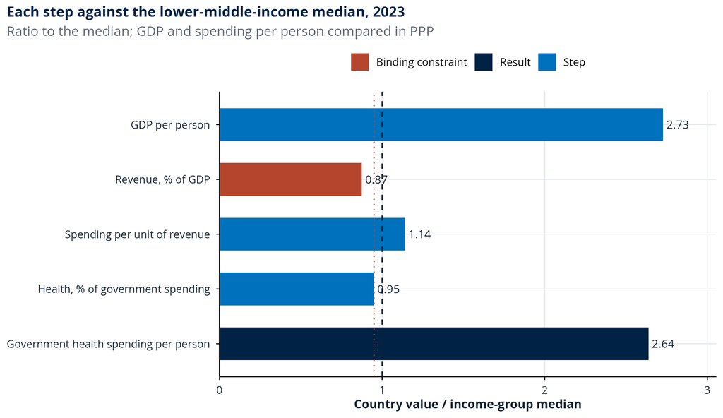

```r
if (!is.null(SLIDE3$main$plot)) print(SLIDE3$main$plot)
```

## 4. What has driven changes in public health expenditure?

Between 2013 and 2023, changes in Egypt’s real government health expenditure per person are decomposed into economic growth, changes in government expenditure relative to GDP, and changes in health’s share of the government budget. Their annual contributions, expressed in log points, sum to the total change. The lower-middle-income group medians provide context for each component but do not necessarily sum to the median total. Comparing the two halves of the period identifies accelerations or slowdowns of at least 1.5 log points per year. Economic growth provides important fiscal context but is not directly controlled by the health ministry.

```r
country_change <- TR$dec
median_change <- TR$median
out <- c()
if (is.null(country_change)) {
  # Without the split we say why, with total health spending when it is published
  che <- TR$che
  if (!is.null(che)) {
    direction <- if (che$value >= 0) "rose" else "fell"
    out["Message"] <- paste0(
      "Government health spending cannot be split into its parts for this profile; health",
      " spending per person from all sources ", direction, " ", num(abs(che$value), 1),
      "% a year after inflation from ", window_start, " to ", window_end, "."
    )
  } else {
    out["Message"] <- paste(
      "Government health spending, GDP and the government budget are not all published at",
      "constant prices for this profile, so the change cannot be split into its parts."
    )
  }
} else {
  out["Window"] <- paste("From", window_start, "to", window_end)
  total_direction <- if (country_change[["total"]] >= 0) "rose " else "fell "
  total_text <- num(abs(country_change[["total"]]), 1)
  out["Total, a year"] <- paste0(total_direction, total_text, "% a year")
  # the three parts in the lead, then every bar with its median
  part <- c(
    income = "the economy",
    pie = "the budget's share of GDP",
    slice = "health's share of the budget"
  )
  for (k in names(part)) {
    direction <- if (country_change[[k]] >= 0) "grew" else "fell"
    change_text <- num(abs(country_change[[k]]), 1, suffix = "%")
    out[paste("Lead,", part[[k]])] <- paste0(part[[k]], " ", direction, " ", change_text)
  }
  bar <- c(
    income = "economy",
    pie = "government budget",
    slice = "health priority",
    total = "government health spending"
  )
  for (k in names(bar)) {
    out[paste("Bar,", bar[[k]])] <- num(country_change[[k]], 1, suffix = "%", plus = TRUE)
    if (is.finite(median_change[[k]])) {
      out[paste("Median bar,", bar[[k]])] <- num(median_change[[k]], 1, suffix = "%", plus = TRUE)
    }
  }
  out["Median countries"] <- paste0("median (", TR$median_n, " countries)")

  # the part furthest from its median
  gaps <- country_change[names(part)] - median_change[names(part)]
  if (any(is.finite(gaps))) {
    k <- names(gaps)[which.max(abs(gaps))]
    out["Largest gap from the median"] <- paste0(
      num(country_change[[k]], 1, plus = TRUE), "% against ",
      num(median_change[[k]], 1, plus = TRUE), "% a year"
    )
  }

  # Growth in the two halves of the window: a change of 1.5 points a year or more reads as
  # faster or slower growth
  halves <- TR$halves
  if (!is.null(halves)) {
    first <- halves$first
    second <- halves$second
    trend <- case_when(
      first >= 0 & second < 0 ~ paste("Spending fell after", halves$mid),
      first < 0 & second >= 0 ~ paste("Spending recovered after", halves$mid),
      first < 0 & second < 0 ~ "Spending fell in both periods",
      second - first >= 1.5 ~ paste("Growth picked up after", halves$mid),
      second - first <= -1.5 ~ paste("Growth slowed after", halves$mid),
      TRUE ~ "Growth was similar in both periods"
    )
    first_text <- num(first, 1, suffix = "%", plus = TRUE)
    second_text <- num(second, 1, suffix = "%", plus = TRUE)
    out["The two periods"] <- paste0(trend, ", from ", first_text, " to ", second_text, " a year")
    out["First period, column"] <- first_text
    out["Second period, column"] <- second_text
    out["First period"] <- paste0(window_start, "-", halves$mid)
    out["Second period"] <- paste0(halves$mid, "-", window_end)
    out["Change between the periods"] <- num(second - first, 1, plus = TRUE)
  }
  if (!is.null(FALLBACK_NOTE)) {
    out["Currency note"] <- FALLBACK_NOTE
  }
}
slide_values[[4]] <- out
knitr::kable(tibble::enframe(slide_values[[4]], name = "What the slide prints", value = "Value"))
```

| What the slide prints | Value |
| --- | --- |
| Window | From 2013 to 2023 |
| Total, a year | rose 3.9% a year |
| Lead, the economy | the economy grew 2.5% |
| Lead, the budget’s share of GDP | the budget’s share of GDP fell 3.7% |
| Lead, health’s share of the budget | health’s share of the budget grew 5.1% |
| Bar, economy | +2.5% |
| Median bar, economy | +1.5% |
| Bar, government budget | -3.7% |
| Median bar, government budget | -0.1% |
| Bar, health priority | +5.1% |
| Median bar, health priority | +1.5% |
| Bar, government health spending | +3.9% |
| Median bar, government health spending | +2.1% |
| Median countries | median (51 countries) |
| Largest gap from the median | +5.1% against +1.5% a year |
| The two periods | Growth picked up after 2018, from +1.9% to +5.9% a year |
| First period, column | +1.9% |
| Second period, column | +5.9% |
| First period | 2013-2018 |
| Second period | 2018-2023 |
| Change between the periods | +4.0 |

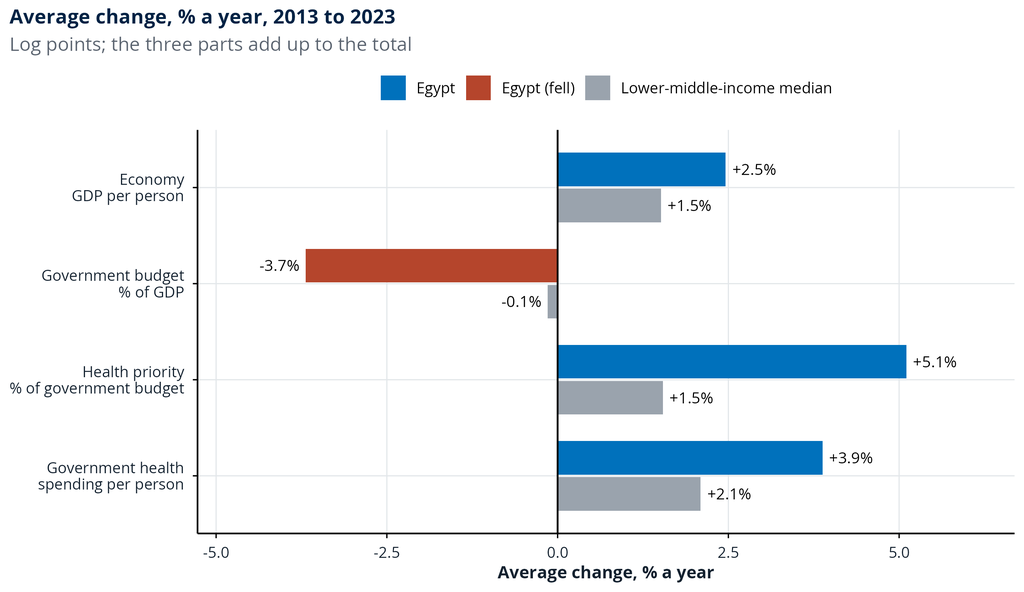

```r
# The figure: each part's average change against the income-group median of that part
if (!is.null(country_change)) {
  rows <- c(
    income = "Economy\nGDP per person",
    pie = "Government budget\n% of GDP",
    slice = "Health priority\n% of government budget",
    total = "Government health\nspending per person"
  )
  median_label <- paste(ADJ_CAP, "median")
  bars <- rbind(
    data.frame(part = rows, who = SHORT, v = country_change[names(rows)]),
    data.frame(part = rows, who = median_label, v = median_change[names(rows)])
  )
  bars$part <- factor(bars$part, levels = rev(rows))
  bars$who <- factor(bars$who, levels = c(median_label, SHORT))
  bars$fill <- ifelse(bars$who == SHORT, ifelse(bars$v >= 0, "up", "down"), "median")
  ggplot(bars, aes(v, part, fill = fill, group = who)) +
    geom_col(position = position_dodge(width = 0.75), width = 0.7) +
    geom_text(
      aes(label = num(v, 1, suffix = "%", plus = TRUE), hjust = ifelse(v >= 0, -0.15, 1.15)),
      position = position_dodge(width = 0.75),
      size = 3.5
    ) +
    geom_vline(xintercept = 0, colour = "black") +
    scale_fill_manual(
      values = c(up = WB[["teal"]], down = WB[["rust"]], median = WB[["grey"]]),
      breaks = c("up", "down", "median"),
      labels = c(up = SHORT, down = paste(SHORT, "(fell)"), median = median_label)
    ) +
    scale_x_continuous(expand = expansion(mult = 0.18)) +
    labs(
      title = paste0("Average change, % a year, ", window_start, " to ", window_end),
      subtitle = "Log points; the three parts add up to the total",
      x = "Average change, % a year",
      y = NULL
    ) +
    theme_deck()
}
```

## 5. Are health outcomes commensurate with health spending?

Premature mortality from noncommunicable diseases is compared with health expenditure per person, measured in PPP international dollars, across countries in 2021. The fitted relationship represents the mortality level typically observed at a given expenditure level. Egypt is positioned relative to this benchmark and compared with four geographically relevant countries with similar spending. The accompanying composite score incorporates premature NCD, under-five, and maternal mortality. Countries below the mortality curve perform better than the cross-country benchmark at their expenditure level. These patterns are associations, not estimates of the causal effect of spending; NCD mortality estimates may also rely on statistical modelling where vital registration is incomplete.

```r
# How each measure is printed: decimals, a % sign, its name in the sentence, its unit and its
# axis title
MEASURE_FORMAT <- data.frame(
  id = c("ncd", "u5", "maternal", "uhc"),
  log_scale = c(FALSE, TRUE, TRUE, FALSE),
  dec = c(1, 1, 0, 0),
  pct = c(TRUE, FALSE, FALSE, FALSE),
  noun = c(
    "the risk of premature deaths from noncommunicable diseases (ages 30 to 70)",
    "under-five mortality",
    "maternal mortality",
    "the UHC service coverage index"
  ),
  per = c("%", "per 1,000 live births", "per 100,000 live births", "points"),
  axis = c(
    "Dying of an NCD at ages 30 to 70, %",
    "Under-five deaths per 1,000 births (log scale)",
    "Maternal deaths per 100,000 births (log scale)",
    "UHC service coverage index (0 to 100)"
  )
)

# We build slide 5 with spending in PPP, and the same slide in US$ for annex A3 (slide 19);
# without local currency there is the US$ slide only
SLIDE5 <- list()
versions <- if (LCU_MAIN) c("main", "annex") else "main"
for (version in versions) {
  ppp <- version == "main" && LCU_MAIN
  health_fit <- if (ppp) HEALTH_PPP else HEALTH_USD
  scatter <- health_fit$scatter
  if (!isTRUE(health_fit$ready) || is.null(scatter)) {
    message_text <- paste(
      "Health spending and health outcomes are not published for enough countries in the same",
      "year to make this comparison."
    )
    SLIDE5[[version]] <- list(values = c("Message" = message_text))
    next
  }

  # The country's measures with their gap to the typical level in words: a ratio for the two
  # mortality rates on a log scale ("23% lower than"), a difference in points for the others
  own_measures <- health_fit$country$components |>
    left_join(MEASURE_FORMAT, by = "id") |>
    arrange(match(id, MEASURE_FORMAT$id)) |>
    mutate(
      ratio_words = paste0(
        num(abs(ratio - 1) * 100, 0), "% ", ifelse(ratio < 1, "lower than", "higher than")
      ),
      points_words = paste(num(abs(gap), 1), "points", ifelse(gap >= 0, "above", "below")),
      gap_label = ifelse(log_scale, ratio_words, points_words),
      percentage_words = paste(
        num(abs(gap), 1), "percentage points", ifelse(gap >= 0, "higher than", "lower than")
      ),
      gap_words = ifelse(log_scale | !pct, gap_label, percentage_words)
    )

  chart_notes <- c(
    "Axis year" = paste0(if (ppp) "(PPP, log scale), " else "(log scale), ", scatter$year),
    "Countries in the fit" = paste0("least-squares fit across ", scatter$n, " countries"),
    "Figure year" = paste0("Each dot is a country, ", scatter$year)
  )
  if (is.null(scatter$country)) {
    # a country without the charted measure: the chart of the other countries, and why
    no_comparison <- paste(
      "Health spending and health outcomes are not both published for the same year, so",
      "results cannot be compared with what countries at this spending level typically show."
    )
    out <- c("Lead" = no_comparison, chart_notes)
  } else {
    charted <- own_measures[own_measures$id == scatter$measure, ]
    unit_text <- case_when(
      charted$pct ~ "%",
      charted$id == "uhc" ~ "",
      TRUE ~ paste0(" ", sub(" live births", "", charted$per))
    )
    value <- paste0(num(charted$value, charted$dec), unit_text)
    typical <- paste0(num(charted$expected, charted$dec), if (charted$pct) "%" else "")
    against <- if (identical(charted$verdict, "close")) {
      paste0("close to the ", typical, " typical")
    } else {
      paste0(charted$gap_words, " the ", typical, " typical")
    }
    spending <- fmt_money(health_fit$country$spend, if (ppp) "Int$" else "US$")
    countries_note <- case_when(
      charted$pct & ppp ~ " (PPP)",
      charted$pct ~ "",
      ppp ~ paste0(" (PPP, ", scatter$n, " countries)"),
      TRUE ~ paste0(" (", scatter$n, " countries)")
    )
    out <- c()
    out["Lead"] <- paste0(
      "In ", charted$year, ", ", charted$noun, " was ", value, ", ", against,
      " of countries spending ",
      spending, " per person on health", countries_note, "."
    )
    out["Gap label on the chart"] <- paste(charted$gap_label, "typical")
    out <- c(out, chart_notes)
    if (nrow(health_fit$peers) > 0) {
      out["Comparators"] <- paste0("Dark dots: the ", nrow(health_fit$peers), " countries")
    }

    # The second sentence: coverage when it parts from the health score, else the weakest
    # outcome, else the comparators that score higher
    z <- health_fit$country$z
    coverage <- own_measures[own_measures$id == "uhc", ]
    scored_measures <- own_measures[own_measures$in_score & is.finite(own_measures$z), ]
    weakest <- scored_measures[which.min(scored_measures$z), ]
    coverage_parts <- nrow(coverage) > 0 && is.finite(coverage$z) && is.finite(z) &&
      abs(coverage$z - z) >= 1
    weakest_is_worse <- nrow(weakest) > 0 && identical(weakest$verdict, "worse") &&
      weakest$id != scatter$measure
    if (coverage_parts) {
      out["Coverage"] <- paste0(
        "the UHC index is ", num(coverage$value, 0), ", against ", num(coverage$expected, 0),
        " typical at this spending (", coverage$year, ")"
      )
    } else if (weakest_is_worse) {
      out["Weakest outcome"] <- paste0(
        weakest$gap_words, " the typical level (", weakest$year, ")"
      )
    } else if (nrow(health_fit$peers) > 0 && is.finite(z)) {
      scored_peers <- health_fit$peers[is.finite(health_fit$peers$z), ]
      if (nrow(scored_peers) > 0) {
        how_many <- if (any(scored_peers$z > z)) "Of the " else "None of the "
        out["Comparators scoring higher"] <- paste0(how_many, nrow(scored_peers), " countries")
      }
    }
  }

  # The figure: every country, the typical level at each spending level, the country's gap
  # and its four comparators
  charted_format <- MEASURE_FORMAT[MEASURE_FORMAT$id == scatter$measure, ]
  lowest <- min(scatter$points$x) * 0.9
  highest <- max(scatter$points$x) * 1.1
  spending_grid <- exp(seq(log(lowest), log(highest), length.out = 100))
  fitted_line <- scatter$fit$a + scatter$fit$b * log10(spending_grid)
  is_mortality <- scatter$measure %in% c("ncd", "u5", "maternal")
  curve <- data.frame(
    x = spending_grid,
    y = if (is_mortality) exp(fitted_line) else fitted_line
  )
  scatter_points <- mutate(scatter$points, peer = iso3 %in% health_fit$peers$iso)
  labels <- scatter_points |>
    filter(peer) |>
    transmute(x, y, label = countries$label[match(iso3, ISOS)], face = "plain")
  if (!is.null(scatter$country)) {
    own_gap_label <- own_measures$gap_label[own_measures$id == scatter$measure]
    own_label <- data.frame(
      x = health_fit$country$spend,
      y = scatter$country$value,
      label = paste0(SHORT, "\n", own_gap_label, " typical"),
      face = "bold"
    )
    labels <- bind_rows(labels, own_label)
  }
  noun <- charted_format$noun
  noun_capitalised <- paste0(toupper(substr(noun, 1, 1)), substring(noun, 2))
  x_title <- if (ppp) {
    "Health spending per person, current international $ (PPP, log scale)"
  } else {
    "Health spending per person, current US$ (log scale)"
  }
  p <- ggplot(scatter_points, aes(x, y)) +
    geom_point(aes(colour = peer, size = peer)) +
    geom_line(data = curve, linetype = "dashed", colour = WB[["ink"]]) +
    scale_colour_manual(
      values = c(`FALSE` = WB[["faint"]], `TRUE` = WB[["muted"]]),
      guide = "none"
    ) +
    scale_size_manual(values = c(`FALSE` = 1.6, `TRUE` = 2.6), guide = "none") +
    scale_x_log10(labels = scales::label_comma(accuracy = 1))
  if (charted_format$log_scale) {
    p <- p + scale_y_log10()
  }
  if (!is.null(scatter$country)) {
    p <- p +
      annotate(
        "segment",
        x = health_fit$country$spend, xend = health_fit$country$spend,
        y = scatter$country$expected, yend = scatter$country$value,
        colour = WB[["teal"]], linewidth = 1
      ) +
      annotate(
        "point",
        x = health_fit$country$spend, y = scatter$country$value,
        colour = WB[["teal"]], size = 4
      )
  }
  p <- p +
    geom_text_repel(
      data = labels,
      aes(x, y, label = label, fontface = face),
      family = "Open Sans", size = 3.3, colour = WB[["dark"]],
      box.padding = 0.6, min.segment.length = 0, max.overlaps = Inf, seed = 1
    ) +
    labs(
      title = paste0(noun_capitalised, ", ", scatter$year),
      subtitle = paste0(
        "Dashed: the level typical at each spending level (", scatter$n, " countries)"
      ),
      x = x_title,
      y = charted_format$axis
    ) +
    theme_deck()
  SLIDE5[[version]] <- list(values = out, plot = p)
}

values <- SLIDE5$main$values
if (!is.null(SLIDE5$main$plot) && !is.null(FALLBACK_NOTE)) {
  values["Currency note"] <- FALLBACK_NOTE
}
slide_values[[5]] <- values
knitr::kable(tibble::enframe(slide_values[[5]], name = "What the slide prints", value = "Value"))
```

| What the slide prints | Value |
| --- | --- |
| Lead | In 2021, the risk of premature deaths from noncommunicable diseases (ages 30 to 70) was 26.0%, 8.0 percentage points higher than the 18.0% typical of countries spending Int$718 per person on health (P… |
| Gap label on the chart | 8.0 points above typical |
| Axis year | (PPP, log scale), 2021 |
| Countries in the fit | least-squares fit across 182 countries |
| Figure year | Each dot is a country, 2021 |
| Comparators | Dark dots: the 4 countries |
| Coverage | the UHC index is 71, against 66 typical at this spending (2021) |

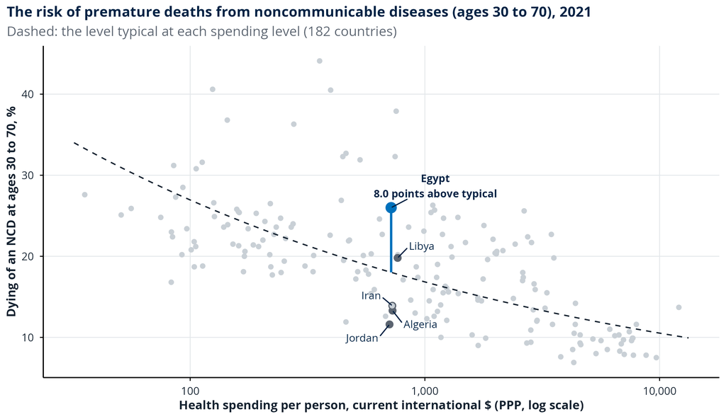

```r
if (!is.null(SLIDE5$main$plot)) print(SLIDE5$main$plot)
```

## 6. How does financial protection compare with public spending?

Financial hardship from healthcare payments is compared with government health expenditure per person at the time of each country’s most recent survey, using constant 2023 PPP international dollars and the revised 2025 SDG 3.8.2 definition where available. The fitted relationship indicates the hardship typically observed at comparable spending levels. For Egypt the latest survey is from 2019. Lower hardship relative to the benchmark is favourable, but may also reflect unmet healthcare needs rather than effective financial protection. Income-group medians combine the latest available surveys of member countries and therefore do not necessarily represent the same year.

```r
# A country with a survey paired at market exchange rates but no 2023 PPP conversion keeps
# the US$ comparison
NO_PPP_6 <- LCU_MAIN && !is.finite(PROT_PPP$country$spending) &&
  is.finite(PROT_USD$country$spending)

# We build slide 6 with spending in constant 2023 PPP dollars, and the same slide in constant
# 2023 US$ for annex A4 (slide 20)
SLIDE6 <- list()
versions <- if (LCU_MAIN) c("main", "annex") else "main"
for (version in versions) {
  ppp <- version == "main" && LCU_MAIN && !NO_PPP_6
  protection_fit <- if (ppp) PROT_PPP else PROT_USD
  peers <- if (ppp) HEALTH_PPP$peers$iso else HEALTH_USD$peers$iso
  own <- protection_fit$country
  oop <- protection_fit$oop
  out <- c()
  if (is.na(own$measure)) {
    no_survey <- "No household survey of financial hardship from health costs is published"
    if (!is.null(oop)) {
      out["Lead"] <- paste0(
        no_survey, "; out-of-pocket payments were ", num(oop$value, 0, suffix = "%"),
        " of health spending in ", oop$year, "."
      )
    } else {
      out["Lead"] <- paste0(no_survey, ".")
    }
  } else {
    what <- if (own$measure == "hardship") {
      "of people faced financial hardship from health costs"
    } else {
      "of people spent more than 10% of their budget on health"
    }
    share_text <- num(own$value, 1, suffix = "%")
    if (!is.finite(own$spending)) {
      out["Lead"] <- paste0(
        share_text, " ", what, " in ", own$year, "; government health spending is not",
        " published for that year, so no comparison is possible."
      )
    } else {
      if (ppp) {
        per <- paste0(fmt_money(own$spending, "Int$"), " per person, PPP")
      } else {
        per <- paste0(fmt_money(own$spending, "US$"), " per person")
      }
      comparison <- ""
      if (is.finite(own$expected)) {
        comparison <- paste0(
          ", against ", num(own$expected, 1, suffix = "%"),
          " typical at the same government health spending (", per, ")"
        )
      }
      out["Lead"] <- paste0(share_text, " ", what, " in ", own$year, comparison, ".")
      out["Country label"] <- paste0(", ", own$year)
      if (is.finite(own$expected)) {
        gap <- own$value - own$expected
        side <- if (gap <= 0) "below" else "above"
        out["Gap label"] <- paste(num(abs(gap), 1), "points", side, "typical")
      }
    }
  }
  if (!is.null(protection_fit$years)) {
    paired_years <- protection_fit$years
    out["Survey years"] <- paste0("latest survey (", paired_years[1], " to ", paired_years[2], ")")
  }
  if (!is.na(own$measure)) {
    group <- protection_fit$group
    if (is.finite(group$median)) {
      survey_years <- ""
      if (!is.null(group$years)) {
        survey_years <- paste0(", surveys ", group$years[1], " to ", group$years[2])
      }
      out["Group median"] <- paste0(
        "median is ", num(group$median, 1, suffix = "%"), " (latest surveys from ", group$n,
        " of ", group$N, " countries", survey_years, ")"
      )
    } else {
      out["Group median"] <- paste0("give a group median (", group$n, " of ", group$N, ")")
    }

    # When hardship is not low, we flag an old survey; otherwise we set the out-of-pocket
    # share against its median
    hardship_is_low <- identical(own$verdict, "stronger") || (is.finite(own$value) && own$value < 5)
    if (own$measure == "hardship" && !hardship_is_low) {
      if (MAX_YEAR - own$year >= 5) {
        out["Old survey"] <- paste("The latest survey is from", own$year)
      } else if (!is.null(oop) && is.finite(oop$value)) {
        oop_versus <- ""
        if (is.finite(oop$median) && abs(oop$value - oop$median) < 2) {
          oop_versus <- paste0(", close to the ", ADJ, " median")
        } else if (is.finite(oop$median)) {
          oop_versus <- paste0("; the ", ADJ, " median is ", num(oop$median, 0, suffix = "%"))
        }
        out["Out of pocket"] <- paste0(
          "Out-of-pocket payments are ", num(oop$value, 0, suffix = "%"),
          " of health spending (", oop$year, ")", oop_versus
        )
      }
    }
  }

  # The figure: each country's latest survey against government spending in its year, and the
  # typical level
  p <- NULL
  if (!is.null(protection_fit$fit) && nrow(protection_fit$points) > 0) {
    scatter_points <- mutate(protection_fit$points, peer = iso %in% peers)
    lowest <- min(scatter_points$x) * 0.85
    highest <- max(scatter_points$x) * 1.15
    spending_grid <- exp(seq(log(lowest), log(highest), length.out = 100))
    fitted_line <- protection_fit$fit$a + protection_fit$fit$b * log10(spending_grid)
    curve <- data.frame(x = spending_grid, y = pmax(0, fitted_line))
    labels <- scatter_points |>
      filter(peer) |>
      transmute(x, y, label = countries$label[match(iso, ISOS)], face = "plain")
    if (is.finite(own$spending)) {
      gap_text <- ""
      if (is.finite(own$expected)) {
        side <- if (own$value <= own$expected) "below" else "above"
        gap_points <- num(abs(own$value - own$expected), 1)
        gap_text <- paste0("\n", gap_points, " points ", side, " typical")
      }
      own_label <- data.frame(
        x = own$spending,
        y = own$value,
        label = paste0(SHORT, ", ", own$year, gap_text),
        face = "bold"
      )
      labels <- bind_rows(labels, own_label)
    }
    x_title <- if (ppp) {
      "Government health spending per person, constant 2023 international $ (PPP, log scale)"
    } else {
      "Government health spending per person, constant 2023 US$ (log scale)"
    }
    y_title <- if (identical(own$measure, "cat10_oop")) {
      "Health spending over 10% of budget, % of people"
    } else {
      "Financial hardship, % of people"
    }
    p <- ggplot(scatter_points, aes(x, y)) +
      geom_point(aes(colour = peer, size = peer)) +
      geom_line(data = curve, linetype = "dashed", colour = WB[["ink"]]) +
      scale_colour_manual(
        values = c(`FALSE` = WB[["faint"]], `TRUE` = WB[["muted"]]),
        guide = "none"
      ) +
      scale_size_manual(values = c(`FALSE` = 1.6, `TRUE` = 2.6), guide = "none") +
      scale_x_log10(labels = scales::label_comma(accuracy = 1)) +
      scale_y_continuous(limits = c(0, NA), expand = expansion(mult = c(0, 0.05)))
    if (is.finite(own$spending)) {
      p <- p +
        annotate(
          "segment",
          x = own$spending, xend = own$spending,
          y = own$expected, yend = own$value,
          colour = WB[["teal"]], linewidth = 1
        ) +
        annotate("point", x = own$spending, y = own$value, colour = WB[["teal"]], size = 4)
    }
    p <- p +
      geom_text_repel(
        data = labels,
        aes(x, y, label = label, fontface = face),
        family = "Open Sans", size = 3.3, colour = WB[["dark"]],
        box.padding = 0.6, min.segment.length = 0, max.overlaps = Inf, seed = 1
      ) +
      labs(
        title = "Financial hardship against government health spending, latest survey per country",
        subtitle = "Dashed: the level typical at each spending level",
        x = x_title,
        y = y_title
      ) +
      theme_deck()
  }
  SLIDE6[[version]] <- list(values = out, plot = p)
}

values <- SLIDE6$main$values
if (!is.null(FALLBACK_NOTE)) {
  values["Currency note"] <- FALLBACK_NOTE
}
if (NO_PPP_6) {
  values["PPP note"] <- paste0(
    "Spending in constant 2023 US$: ", SHORT,
    " has no 2023 health spending in WHO GHED to convert to PPP."
  )
}
slide_values[[6]] <- values
knitr::kable(tibble::enframe(slide_values[[6]], name = "What the slide prints", value = "Value"))
```

| What the slide prints | Value |
| --- | --- |
| Lead | 36.9% of people faced financial hardship from health costs in 2019, against 22.2% typical at the same government health spending (Int$216 per person, PPP). |
| Country label | , 2019 |
| Gap label | 14.7 points above typical |
| Survey years | latest survey (2003 to 2023) |
| Group median | median is 25.2% (latest surveys from 48 of 51 countries, surveys 2003 to 2023) |
| Out of pocket | Out-of-pocket payments are 57% of health spending (2023); the lower-middle-income median is 38% |

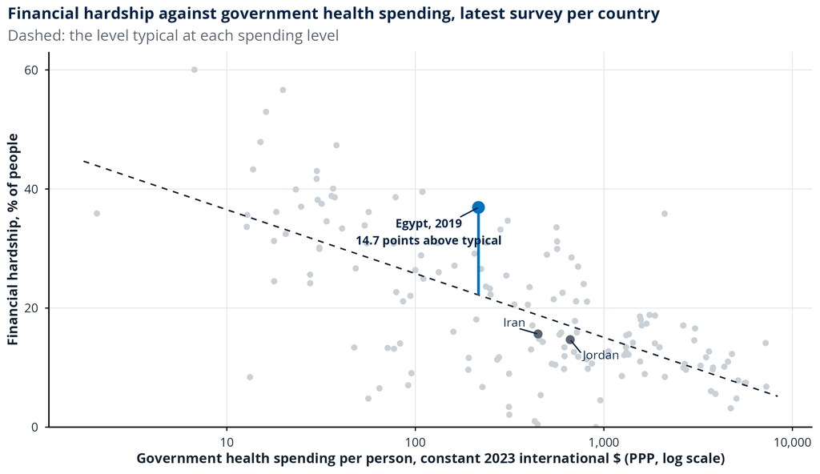

```r
if (!is.null(SLIDE6$main$plot)) print(SLIDE6$main$plot)
```

## 7. Are financing and health performance improving together?

Trends for Egypt are assessed against the lower-middle-income group median over the period used for the public spending decomposition. Four indicators are considered: indexed government health expenditure, premature NCD mortality, under-five mortality, and the UHC service coverage index. The comparison identifies current performance relative to peers and whether the respective gaps have narrowed or widened; financial hardship is examined using the first and last available surveys within the period. Health outcomes may respond to financing changes only after a delay, and premature NCD mortality data end in 2021. These descriptive trends cannot establish whether spending changes caused observed health outcomes.

```r
out <- c()
# Spending growth over the window: government health spending when it splits into its parts,
# else health spending from all sources
growth <- NA
if (!is.null(TR$dec)) {
  growth <- TR$dec[["total"]]
  growth_median <- TR$median[["total"]]
  what <- "real government health spending per person"
} else if (!is.null(TR$che)) {
  growth <- TR$che$value
  growth_median <- TR$che$median
  what <- "real health spending per capita from all sources"
}
if (is.na(growth)) {
  out["Lead"] <- paste0(
    "Government health spending per person is not published at constant prices for ",
    window_start, " to ", window_end, "."
  )
} else {
  direction <- if (growth >= 0) "increased" else "declined"
  versus_median <- ""
  if (is.finite(growth_median)) {
    median_direction <- if (growth_median >= 0) "increase" else "decline"
    versus_median <- paste0(
      ", compared with a median annual ", median_direction, " of ",
      num(abs(growth_median), 1), "% among ", ADJ, " countries"
    )
  }
  out["Lead"] <- paste0(
    "From ", window_start, " to ", window_end, ", ", what, " ", direction, " by ",
    num(abs(growth), 1), "% annually", versus_median, "."
  )
}
out["Median countries"] <- paste0("median (", length(INC_MEMBERS), " countries)")
out["Index base year"] <- paste0("Government health spending, ", window_start, " = 100")

# the last value of each panel's two lines
PANEL_NAME <- c(
  spend = "spending index",
  ncd = "premature NCD deaths",
  u5 = "under-five deaths",
  uhc = "service coverage"
)
for (k in names(PANEL_NAME)) {
  panel_rows <- filter(PANELS, panel == k)
  digits <- if (k == "ncd") 1 else 0
  own_values <- panel_rows$country[is.finite(panel_rows$country)]
  if (length(own_values) < 2) next
  median_values <- panel_rows$median[is.finite(panel_rows$median)]
  out[paste0("Last value, ", PANEL_NAME[[k]], ", ", SHORT)] <- num(tail(own_values, 1), digits)
  if (length(median_values) > 0) {
    out[paste0("Last value, ", PANEL_NAME[[k]], ", median")] <- num(tail(median_values, 1), digits)
  }
}
if (all(is.finite(spend_levels))) {
  # the levels are in local currency at 2023 prices (GHED's 2023 rate), else in US$
  if (LCU_MAIN) {
    from_text <- fmt_money(spend_levels[["from"]] * LCU$rate)
    to_text <- fmt_money(spend_levels[["to"]] * LCU$rate)
  } else {
    from_text <- fmt_money(spend_levels[["from"]], "US$")
    to_text <- fmt_money(spend_levels[["to"]], "US$")
  }
  out["Spending levels"] <- paste0("(", from_text, " to ", to_text, " per person)")
}

# the measures on which the country is better than the median in the latest year
shown <- filter(TR$rows, id %in% c("ncd", "u5", "uhc"), is.finite(gap_latest))
n_shown <- nrow(shown)
n_better <- sum(shown$gap_latest > 0)
if (n_shown > 0) {
  how_many <- case_when(
    n_better == n_shown ~ paste("all", n_shown),
    n_better == 0 ~ paste("none of the", n_shown),
    TRUE ~ paste(n_better, "of the", n_shown)
  )
  out["Measures above the median"] <- paste0(how_many, " outcome and coverage measures")
}

# the first and the latest survey of financial hardship inside the window
hardship_row <- filter(TR$rows, id %in% "hardship")
if (nrow(hardship_row) == 0) {
  out["Financial hardship"] <- paste0("since ", window_start, ", so its direction is not known")
} else if (hardship_row$verdict == "oneSurvey") {
  out["Financial hardship"] <- paste0(
    "One survey of financial hardship since ", window_start, " (",
    num(hardship_row$latest, 1, suffix = "%"), " in ", hardship_row$latest_year, ")"
  )
} else {
  out["Financial hardship"] <- paste0(
    "from ", num(hardship_row$start, 1, suffix = "%"), " in ", hardship_row$start_year,
    " to ", num(hardship_row$latest, 1, suffix = "%"), " in ", hardship_row$latest_year
  )
}
if (!is.null(FALLBACK_NOTE)) {
  out["Currency note"] <- FALLBACK_NOTE
}
slide_values[[7]] <- out
knitr::kable(tibble::enframe(slide_values[[7]], name = "What the slide prints", value = "Value"))
```

| What the slide prints | Value |
| --- | --- |
| Lead | From 2013 to 2023, real government health spending per person increased by 3.9% annually, compared with a median annual increase of 2.1% among lower-middle-income countries. |
| Median countries | median (51 countries) |
| Index base year | Government health spending, 2013 = 100 |
| Last value, spending index, Egypt | 147 |
| Last value, spending index, median | 123 |
| Last value, premature NCD deaths, Egypt | 26.0 |
| Last value, premature NCD deaths, median | 21.4 |
| Last value, under-five deaths, Egypt | 23 |
| Last value, under-five deaths, median | 31 |
| Last value, service coverage, Egypt | 71 |
| Last value, service coverage, median | 59 |
| Spending levels | (EGP 948 to EGP 1,400 per person) |
| Measures above the median | 2 of the 3 outcome and coverage measures |
| Financial hardship | from 34.6% in 2015 to 36.9% in 2019 |

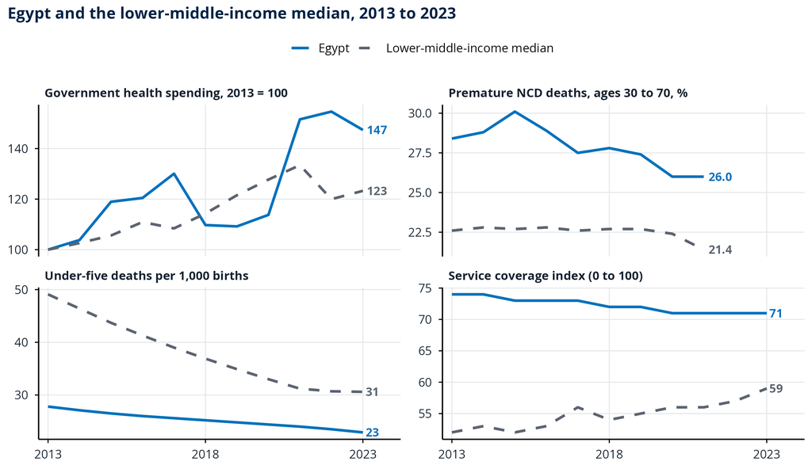

```r
# Four panels: the country and the income-group median, year by year
titles <- c(
  spend = paste0("Government health spending, ", window_start, " = 100"),
  ncd = "Premature NCD deaths, ages 30 to 70, %",
  u5 = "Under-five deaths per 1,000 births",
  uhc = "Service coverage index (0 to 100)"
)
median_label <- paste(ADJ_CAP, "median")
panel_lines <- bind_rows(
  transmute(PANELS, panel, year, v = country, who = SHORT),
  transmute(PANELS, panel, year, v = median, who = median_label)
) |>
  filter(is.finite(v)) |>
  mutate(panel = factor(titles[panel], levels = titles))
line_ends <- panel_lines |>
  group_by(panel, who) |>
  slice_max(year, n = 1) |>
  ungroup() |>
  mutate(lab = ifelse(grepl("NCD", panel), num(v, 1), num(v, 0)))
# the middle tick: the deck rounds a half year up
middle_year <- ceiling((window_start + window_end) / 2)
ggplot(panel_lines, aes(year, v, colour = who, linetype = who)) +
  geom_line(linewidth = 1) +
  facet_wrap(~panel, scales = "free_y", ncol = 2) +
  geom_text(
    data = line_ends,
    aes(label = lab),
    hjust = -0.2, fontface = "bold", size = 3.3, show.legend = FALSE
  ) +
  scale_x_continuous(
    breaks = unique(c(window_start, middle_year, window_end)),
    expand = expansion(mult = c(0.03, 0.12))
  ) +
  scale_colour_manual(values = setNames(c(WB[["teal"]], WB[["muted"]]), c(SHORT, median_label))) +
  scale_linetype_manual(values = setNames(c("solid", "dashed"), c(SHORT, median_label))) +
  labs(
    title = paste0(SHORT, " and the ", ADJ, " median, ", window_start, " to ", window_end),
    x = NULL,
    y = NULL
  ) +
  theme_deck()
```

## 8. Does public financing translate into service coverage?

Government health expenditure per person and five service coverage indicators are expressed relative to the lower-middle-income group median. Expenditure is compared in PPP international dollars for the most recent year with a reportable median; service indicators use the latest available country observations from 2014 to 2023. Values more than 10% below the corresponding peer median are identified as shortfalls. Because coverage indicators are bounded at 100%, their ratios are not directly comparable with unbounded expenditure ratios. Moreover, financing levels alone do not reveal whether funds were released, spent as planned, or translated into service delivery.

```r
SVC_LABEL <- c(
  spending = "Government health spending per person",
  uhc = "UHC service coverage index",
  measles = "Children vaccinated against measles",
  births = "Births attended by skilled staff",
  tb_success = "Tuberculosis treatment success",
  art = "People with HIV on treatment"
)

# We build slide 8 with spending in PPP, and the same slide in US$ for annex A5 (slide 21)
SLIDE8 <- list()
versions <- if (LCU_MAIN) c("main", "annex") else "main"
for (version in versions) {
  ppp <- version == "main" && LCU_MAIN
  if (!SVC$ready) {
    message_text <- paste(
      "Government health spending and service coverage are not published for this country up",
      "to the selected year."
    )
    SLIDE8[[version]] <- list(values = c("Message" = message_text))
    next
  }
  rows <- SVC[[if (ppp) "ppp" else "usd"]]

  # How each row prints: spending in money, the coverage index as a number, the other services
  # in %. A row's year is added when it differs from the spending year.
  spending_year <- rows$year[1]
  is_index <- rows$id == "uhc"
  rows$value_text <- ifelse(is_index, num(rows$value, 0), num(rows$value, 0, suffix = "%"))
  rows$median_text <- ifelse(is_index, num(rows$median, 0), num(rows$median, 0, suffix = "%"))
  rows$value_text[1] <- fmt_money(rows$value[1], if (ppp) "Int$" else "US$")
  rows$median_text[1] <- fmt_money(rows$median[1], if (ppp) "Int$" else "US$")
  rows$value_text[!is.finite(rows$value)] <- NA_TXT
  rows$median_text[!is.finite(rows$median)] <- NA_TXT
  shows_year <- is.finite(rows$year) & !(rows$year %in% spending_year)
  rows$year_text <- ifelse(shows_year, paste0(" (", rows$year, ")"), "")
  rows$of_median <- num(rows$ratio * 100, 0, suffix = "%")

  out <- c()
  for (i in seq_len(nrow(rows))) {
    label <- SVC_LABEL[[ rows$id[i]]]
    if (is.finite(rows$value[i])) {
      out[label] <- paste0(rows$value_text[i], rows$year_text[i])
    } else {
      out[label] <- NA_TXT
    }
    if (is.finite(rows$median[i])) {
      out[paste0(label, ", median")] <- rows$median_text[i]
    }
  }
  for (i in which(rows$id %in% c("spending", "uhc") & is.finite(rows$ratio))) {
    out[paste0(SVC_LABEL[[ rows$id[i]]], ", % of the median")] <- rows$of_median[i]
  }

  # the lead: spending against its median, set beside the UHC index when both exist
  spending_row <- rows[1, ]
  uhc_row <- rows[rows$id == "uhc", ]
  in_ppp <- if (ppp) " in PPP terms" else ""
  if (is.finite(spending_row$ratio) && is.finite(uhc_row$ratio)) {
    link <- case_when(
      uhc_row$ratio < spending_row$ratio - 0.1 ~ "but",
      uhc_row$ratio > spending_row$ratio + 0.1 ~ "while",
      TRUE ~ "and"
    )
    out["Lead"] <- paste0(
      "In ", spending_year, ", government health spending per person was ",
      spending_row$of_median, " of the ", ADJ, " median", in_ppp, ", ", link,
      " the UHC service coverage index was ", uhc_row$of_median, " of it (",
      uhc_row$value_text, " against ", uhc_row$median_text, uhc_row$year_text, ")."
    )
  } else if (is.finite(spending_row$ratio)) {
    out["Lead"] <- paste0(
      "In ", spending_year, ", government health spending per person was ",
      spending_row$of_median, " of the ", ADJ, " median", in_ppp,
      " (", spending_row$value_text, " against ", spending_row$median_text, ")"
    )
  } else if (is.finite(uhc_row$ratio)) {
    uhc_year <- if (is.finite(uhc_row$year)) paste0(" (", uhc_row$year, ")") else ""
    out["Lead"] <- paste0(
      "The UHC service coverage index was ", uhc_row$of_median, " of the ", ADJ, " median",
      uhc_year
    )
  }
  out["Figure note"] <- paste0("median of ", SVC$N, " ", ADJ, " countries")
  out["Years"] <- paste0(
    "Spending: ", spending_year, if (ppp) ", PPP international dollars" else "",
    "; services: latest value ", SVC$window[1], " to ", SVC$window[2]
  )

  # the service furthest below its median, or how many services are below it
  services_shown <- rows[rows$id != "spending" & is.finite(rows$ratio), ]
  other_services <- services_shown[services_shown$id != "uhc", ]
  weakest <- other_services[which.min(other_services$ratio), ]
  if (nrow(weakest) > 0 && weakest$ratio < 0.9) {
    out["Furthest below the median"] <- paste0(
      "furthest below the median: ", weakest$value_text, " against ", weakest$median_text,
      weakest$year_text
    )
  } else if (nrow(services_shown) > 1) {
    n_short <- sum(services_shown$shortfall)
    out["Services below the median"] <- if (n_short > 0) {
      paste0(n_short, " of ", nrow(services_shown), " service measures")
    } else {
      paste0("None of the ", nrow(services_shown), " service measures")
    }
  }

  # The figure: each row as a percentage of its median, on a log scale
  dots <- data.frame(row = SVC_LABEL[rows$id], pc = 100 * rows$ratio, short = rows$shortfall)
  dots$row[1] <- paste0(dots$row[1], if (ppp) ", PPP" else "")
  dots$row <- factor(dots$row, levels = rev(dots$row))
  dots <- dots[is.finite(dots$pc), ]
  x_limits <- range(c(50, 200, dots$pc / 1.25, dots$pc * 1.25))
  p <- ggplot(dots, aes(pc, row, colour = short)) +
    geom_vline(xintercept = 100, linetype = "dashed", colour = WB[["muted"]]) +
    geom_point(size = 4) +
    geom_text(aes(label = num(pc, 0, suffix = "%")), vjust = -1, size = 3.4, show.legend = FALSE) +
    scale_colour_manual(
      values = c(`FALSE` = WB[["teal"]], `TRUE` = WB[["rust"]]),
      labels = c(
        `FALSE` = "Within 10% of the median or above",
        `TRUE` = "More than 10% below the median"
      )
    ) +
    scale_x_log10(breaks = c(5, 10, 25, 50, 100, 200, 400, 1000), limits = x_limits) +
    labs(
      title = paste0("% of the ", ADJ, " median"),
      x = paste0("% of the ", ADJ, " median, log scale"),
      y = NULL
    ) +
    theme_deck()
  SLIDE8[[version]] <- list(values = out, plot = p)
}

values <- SLIDE8$main$values
if (SVC$ready && !is.null(FALLBACK_NOTE)) {
  values["Currency note"] <- FALLBACK_NOTE
}
slide_values[[8]] <- values
knitr::kable(tibble::enframe(slide_values[[8]], name = "What the slide prints", value = "Value"))
```

| What the slide prints | Value |
| --- | --- |
| Government health spending per person | Int$292 |
| Government health spending per person, median | Int$111 |
| UHC service coverage index | 71 |
| UHC service coverage index, median | 59 |
| Children vaccinated against measles | 96% |
| Children vaccinated against measles, median | 84% |
| Births attended by skilled staff | 97% (2021) |
| Births attended by skilled staff, median | 86% |
| Tuberculosis treatment success | 88% |
| Tuberculosis treatment success, median | 89% |
| People with HIV on treatment | 38% |
| People with HIV on treatment, median | 71% |
| Government health spending per person, % of the median | 264% |
| UHC service coverage index, % of the median | 120% |
| Lead | In 2023, government health spending per person was 264% of the lower-middle-income median in PPP terms, but the UHC service coverage index was 120% of it (71 against 59). |
| Figure note | median of 51 lower-middle-income countries |
| Years | Spending: 2023, PPP international dollars; services: latest value 2014 to 2023 |
| Furthest below the median | furthest below the median: 38% against 71% |

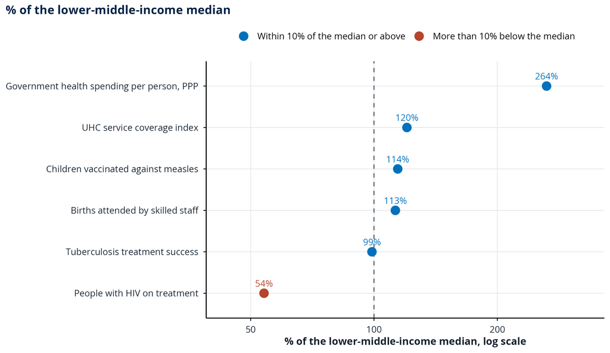

```r
if (!is.null(SLIDE8$main$plot)) print(SLIDE8$main$plot)
```

## 9. Is the health workforce sufficient to support service delivery?

Health workforce availability is assessed as the combined density of doctors, nurses, and midwives per 1,000 population, using years in which the relevant professional groups are reported together. Country estimates are compared with the lower-middle-income peer median and the WHO reference level of 4.45 health workers per 1,000 population, which is associated with achieving the median of twelve SDG tracer indicators. This threshold is a broad planning reference rather than a staffing requirement for individual facilities. Apparent changes over time may also reflect differences in reporting coverage, including the private sector or whether licensed rather than actively practising professionals are counted.

```r
out <- c()
if (!WF$ready) {
  # Doctors and nurses are never reported for the same year: we say so, with each figure on
  # its own (two decimals below 10, one above)
  published <- c()
  if (nrow(phys_last) > 0) {
    phys_digits <- if (phys_last$value < 10) 2 else 1
    published <- c(published, paste0(
      "doctors ", num(phys_last$value, phys_digits), " per 1,000 (", phys_last$year, ")"
    ))
  }
  if (nrow(nurse_last) > 0) {
    nurse_digits <- if (nurse_last$value < 10) 2 else 1
    published <- c(published, paste0(
      "nurses and midwives ", num(nurse_last$value, nurse_digits), " per 1,000 (",
      nurse_last$year, ")"
    ))
  }
  out["Message"] <- paste0(
    "Doctors and nurses are not reported for the same year for ", SHORT, " up to ", MAX_YEAR,
    ", so the combined density cannot be compared."
  )
  if (length(published) > 0) {
    out["Published separately"] <- paste0(
      "Published separately: ", knitr::combine_words(published, oxford_comma = FALSE), "."
    )
  }
} else {
  latest <- WF$latest
  earlier <- WF$earlier
  # densities print to two decimals below 10 and to one above
  densities <- c(
    value = latest$value,
    median = latest$median,
    phys = latest$phys,
    nurse = latest$nurse,
    earlier = if (is.null(earlier)) NA else earlier$value,
    earlier_median = if (is.null(earlier)) NA else earlier$median
  )
  density_text <- ifelse(densities < 10, num(densities, 2), num(densities, 1))
  if (!is.finite(latest$median)) {
    versus_median <- paste0("the ", ADJ, " median is not published for that year")
  } else {
    position <- case_when(
      latest$value >= latest$median * 1.05 ~ "above",
      latest$value <= latest$median * 0.95 ~ "below",
      TRUE ~ "close to"
    )
    versus_median <- paste0(position, " the ", ADJ, " median of ", density_text[["median"]])
  }
  versus_threshold <- case_when(
    latest$value >= WF_THRESHOLD ~ "above",
    latest$value >= WF_THRESHOLD * 0.8 ~ "just below",
    TRUE ~ "below"
  )
  out["Lead"] <- paste0(
    "In ", latest$year, ", ", SHORT, " had ", density_text[["value"]],
    " doctors, nurses and midwives per 1,000 people, ", versus_median, ", and ",
    versus_threshold, " the WHO threshold of 4.45."
  )
  out["Latest value on the chart"] <- density_text[["value"]]
  out["Threshold on the chart"] <- "4.45"
  out["Figure note"] <- paste0("median of ", WF$N, " ", ADJ, " countries")
  if (is.finite(latest$phys) && is.finite(latest$nurse)) {
    out["Doctors, nurses and midwives"] <- paste0(
      "Doctors ", density_text[["phys"]], "; nurses and midwives ", density_text[["nurse"]],
      " per 1,000 (",
      latest$year, ")."
    )
  }
  if (!is.null(earlier)) {
    direction <- case_when(
      latest$value > earlier$value * 1.05 ~ "Up from",
      latest$value < earlier$value * 0.95 ~ "Down from",
      TRUE ~ "About the same as"
    )
    median_moved <- ""
    if (is.finite(earlier$median) && is.finite(latest$median)) {
      median_moved <- paste0(
        "; the median moved from ", density_text[["earlier_median"]], " to ",
        density_text[["median"]]
      )
    }
    out["Earlier value"] <- paste0(
      direction, " ", density_text[["earlier"]], " in ", earlier$year, median_moved, "."
    )
  }
}
slide_values[[9]] <- out
knitr::kable(tibble::enframe(slide_values[[9]], name = "What the slide prints", value = "Value"))
```

| What the slide prints | Value |
| --- | --- |
| Lead | In 2018, Egypt had 2.51 doctors, nurses and midwives per 1,000 people, above the lower-middle-income median of 2.06, and below the WHO threshold of 4.45. |
| Latest value on the chart | 2.51 |
| Threshold on the chart | 4.45 |
| Figure note | median of 51 lower-middle-income countries |
| Doctors, nurses and midwives | Doctors 0.72; nurses and midwives 1.79 per 1,000 (2018). |
| Earlier value | About the same as 2.54 in 2014; the median moved from 1.61 to 2.06. |

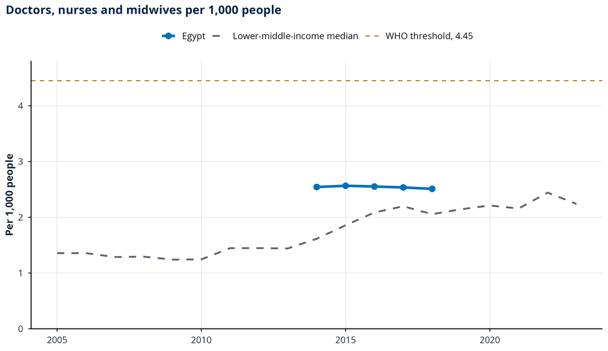

```r
# The figure: the country's density, the income-group median and the WHO threshold
if (WF$ready) {
  country_points <- WF$pts
  # we do not draw a line across a gap of more than three years
  country_points$run <- cumsum(c(1, diff(country_points$year) > 3))
  ggplot() +
    geom_line(
      data = filter(WF$medians, is.finite(value)),
      aes(year, value, colour = "median"),
      linetype = "dashed", linewidth = 0.9
    ) +
    geom_hline(aes(yintercept = WF_THRESHOLD, colour = "threshold"), linetype = "dashed") +
    geom_line(
      data = country_points,
      aes(year, both, group = run, colour = "country"),
      linewidth = 1.3
    ) +
    geom_point(data = country_points, aes(year, both, colour = "country"), size = 2.6) +
    scale_colour_manual(
      values = c(country = WB[["teal"]], median = WB[["muted"]], threshold = WB[["gold"]]),
      labels = c(
        country = SHORT,
        median = paste(ADJ_CAP, "median"),
        threshold = "WHO threshold, 4.45"
      )
    ) +
    scale_y_continuous(limits = c(0, NA), expand = expansion(mult = c(0, 0.08))) +
    labs(
      title = "Doctors, nurses and midwives per 1,000 people",
      x = NULL,
      y = "Per 1,000 people"
    ) +
    theme_deck()
}
```

## 10. How accessible are essential medicines, and who finances them?

Spending on medicines and other medical goods purchased outside consultations or inpatient stays (WHO health accounts category HC.5.1) is assessed as a share of Egypt’s current health expenditure. Financing sources are distinguished where reported. Medicines supplied during outpatient or inpatient care are included under the corresponding service category, so the measure does not capture total pharmaceutical expenditure. Private financing combines households, insurers, non-profit organisations, and businesses; available global data do not consistently isolate household out-of-pocket spending on medicines. Facility-level medicine availability data (SDG 3.b.3) remain limited.

```r
PAYER <- c(pvt = "private sources", gov = "the government", ext = "external sources")
# shares print to one decimal below 10% and to the unit above
med_bars <- MED$bars |>
  mutate(share_text = ifelse(share < 10, num(share, 1), num(share, 0)))
median_digits <- if (isTRUE(MED$median < 10)) 1 else 0
median_text <- num(MED$median, median_digits, suffix = "%")
if (!is.null(MED$avail)) {
  avail <- paste0(
    "available and affordable in ", num(MED$avail$value, 0), "% of facilities (",
    MED$avail$year, ")."
  )
} else {
  avail <- paste0(
    "Global data do not show whether ", poss(SHORT),
    " facilities have essential medicines in stock."
  )
}

out <- c()
if (!MED$ready) {
  out["Message"] <- paste0(
    "WHO health accounts do not publish spending on medicines for ", SHORT, " up to ",
    MAX_YEAR, ", nor who pays for them."
  )
  out["Availability"] <- avail
} else {
  last <- MED$last
  opening <- paste0(
    "In ", last$year, ", medicines bought from pharmacies and shops took ",
    med_bars$share_text[nrow(med_bars)], "% of current health spending",
    if (is.finite(MED$median)) paste0(" (", ADJ, " median ", median_text, ")") else ""
  )
  # who paid the most: in the latest year, or in the latest year with a split
  split_row <- if (is.finite(last$pvt)) last else MED$last_split
  payers <- c()
  if (!is.null(split_row)) {
    payers <- c(pvt = split_row$pvt, gov = split_row$gov, ext = split_row$ext)
  }
  payers <- payers[is.finite(payers)]
  top_payer <- names(payers)[which.max(payers)]
  if (is.finite(last$pvt)) {
    out["Lead"] <- paste0(
      opening, "; ", PAYER[[top_payer]], " paid ", num(max(payers), 0), "% of it."
    )
  } else if (length(payers) > 0) {
    out["Lead"] <- paste0(
      opening, "; in ", split_row$year, ", the latest year with a split, ",
      PAYER[[top_payer]], " paid ", num(max(payers), 0), "% of it."
    )
  } else {
    out["Lead"] <- paste0(opening, "; WHO health accounts do not show who paid.")
  }
  for (i in seq_len(nrow(med_bars))) {
    out[paste("Bar", med_bars$year[i])] <- paste0(med_bars$share_text[i], "%")
  }
  if (is.finite(MED$median)) {
    out["Median line"] <- paste(ADJ_CAP, "median", median_text)
    out["Median note"] <- paste0(
      "median of ", MED$n, " reporting ", ADJ, " countries, latest value ", MED$window[1],
      " to ", MED$window[2]
    )
  }
  out["Availability"] <- avail
}
slide_values[[10]] <- out
knitr::kable(tibble::enframe(slide_values[[10]], name = "What the slide prints", value = "Value"))
```

| What the slide prints | Value |
| --- | --- |
| Lead | In 2020, medicines bought from pharmacies and shops took 32% of current health spending; private sources paid 100% of it. |
| Bar 2016 | 28% |
| Bar 2017 | 27% |
| Bar 2018 | 30% |
| Bar 2020 | 32% |
| Availability | Global data do not show whether Egypt’s facilities have essential medicines in stock. |

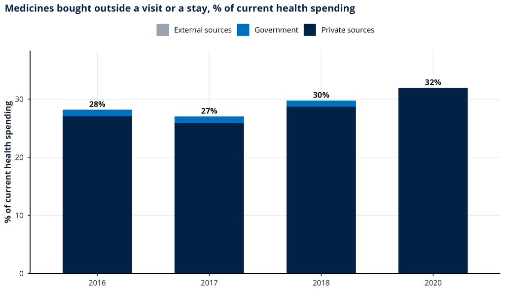

```r
if (MED$ready) {
  # each year's bar split by who paid, where the accounts say
  by_payer <- med_bars |>
    filter(is.finite(pvt)) |>
    transmute(
      year,
      `Private sources` = share * pvt / 100,
      Government = share * gov / 100,
      `External sources` = share * ext / 100
    ) |>
    pivot_longer(-year, names_to = "payer", values_to = "v")
  not_split <- med_bars |>
    filter(!is.finite(pvt)) |>
    transmute(year, payer = "Payer not reported", v = share)
  payer_order <- c("External sources", "Government", "Private sources", "Payer not reported")
  stacks <- bind_rows(by_payer, not_split) |>
    mutate(payer = factor(payer, levels = payer_order))
  p <- ggplot(stacks, aes(factor(year), v, fill = payer)) +
    geom_col(width = 0.62) +
    geom_text(
      data = med_bars,
      aes(factor(year), share, label = paste0(share_text, "%")),
      inherit.aes = FALSE, vjust = -0.5, fontface = "bold", size = 3.6
    ) +
    scale_fill_manual(
      values = c(
        "Private sources" = WB[["dark"]],
        Government = WB[["teal"]],
        "External sources" = WB[["grey"]],
        "Payer not reported" = WB[["tint"]]
      ),
      drop = TRUE
    ) +
    scale_y_continuous(limits = c(0, NA), expand = expansion(mult = c(0, 0.2))) +
    labs(
      title = "Medicines bought outside a visit or a stay, % of current health spending",
      x = NULL,
      y = "% of current health spending"
    ) +
    theme_deck()
  if (is.finite(MED$median)) {
    p <- p + geom_hline(yintercept = MED$median, linetype = "dashed", colour = WB[["muted"]])
  }
  p
}
```

## 11. Are resources aligned with population health needs?

The lines show the share of government health spending that went to preventive and to curative care each year, from WHO health accounts, financed by government. The allocation between preventive and curative services provides an indication of spending priorities, while comparison with eleven burden and coverage indicators highlights areas of elevated need relative to the lower-middle-income group median. Preventive expenditure in 2020-2022 may include COVID-19 testing and vaccination, affecting trend interpretation. Identical expenditure shares across consecutive years may reflect the application of a common distribution to multiple reporting periods. The available global data do not establish how spending is distributed across subnational areas or socioeconomic groups.

```r
NEED_LABEL <- c(
  u5 = "Under-five deaths per 1,000 births",
  maternal = "Maternal deaths per 100,000 births",
  stunting = "Child stunting, %",
  tb = "Tuberculosis cases per 100,000",
  hiv = "New HIV infections per 1,000 adults",
  malaria = "Malaria cases per 1,000 at risk",
  ncd = "Early death from chronic disease, %",
  dtp = "Children without DTP3, %",
  births = "Births without a skilled attendant, %",
  art = "People with HIV not on treatment, %",
  tb_success = "TB cases not treated successfully, %"
)

# the measure of need furthest above its median
top_need <- if (nrow(NEED) > 0) NEED[which.max(NEED$ratio), ] else NULL
need_sentence <- NULL
if (!is.null(top_need) && top_need$ratio > 1.1) {
  need_sentence <- paste0(
    "Need is highest for ", top_need$short, ": ", num(top_need$ratio, 1), " times the ", ADJ,
    " median (", top_need$year, ")."
  )
} else if (nrow(NEED) > 0) {
  need_sentence <- paste0(
    "None of the ", nrow(NEED), " need measures is more than 10% above the ", ADJ, " median."
  )
}

out <- c()
if (!PREV$ready && nrow(NEED) == 0) {
  out["Message"] <- paste0(
    "How ", poss(SHORT), " government health spending divides between prevention and",
    " treatment is not published up to ", MAX_YEAR, "."
  )
} else if (!PREV$ready) {
  # No split of spending by function: the slide shows need against the median instead, up to
  # eight measures
  if (top_need$ratio > 1.1) {
    out["Lead"] <- need_sentence
  } else {
    out["Lead"] <- paste0("No need measure is more than 10% above the ", ADJ, " median.")
  }
  # a year is printed only where it differs from the most common year (the latest of ties)
  year_counts <- table(NEED$year)
  common_year <- max(as.integer(names(year_counts)[year_counts == max(year_counts)]))
  shown <- head(arrange(NEED, desc(ratio)), 8)
  for (i in seq_len(nrow(shown))) {
    need <- shown[i, ]
    value_digits <- if (abs(need$value) < 10) 1 else 0
    median_digits <- if (abs(need$median) < 10) 1 else 0
    year_note <- if (need$year != common_year) paste0(" (", need$year, ")") else ""
    out[NEED_LABEL[[need$id]]] <- paste0(num(need$value, value_digits), year_note)
    out[paste0(NEED_LABEL[[need$id]], ", median")] <- num(need$median, median_digits)
  }
} else {
  prev_points <- PREV$pts
  last <- prev_points[nrow(prev_points), ]
  tier_words <- list(
    gov = c("Preventive care", "Curative care", "government health spending"),
    cofog = c(
      "Public health services",
      "Hospital and outpatient services",
      "government health spending (IMF, general government)"
    ),
    all = c("Preventive care", "Curative care", "current health spending from all sources")
  )[[PREV$tier]]
  # the earlier point of comparison: the first year at least three years before the latest,
  # else the first year
  if (any(prev_points$year <= last$year - 3)) {
    earlier <- prev_points[which(prev_points$year <= last$year - 3)[1], ]
  } else if (nrow(prev_points) > 1) {
    earlier <- prev_points[1, ]
  } else {
    earlier <- NULL
  }
  curative_part <- ""
  if (is.finite(last$cur)) {
    curative_part <- paste0("; ", tolower(tier_words[2]), " took ", num(last$cur, 1), "%")
  }
  change <- ""
  if (!is.null(earlier) && abs(last$prev - earlier$prev) < 0.5) {
    change <- paste0(", about the same as the ", num(earlier$prev, 1), "% of ", earlier$year)
  } else if (!is.null(earlier)) {
    direction <- if (last$prev > earlier$prev) "up" else "down"
    change <- paste0(", ", direction, " from ", num(earlier$prev, 1), "% in ", earlier$year)
  }
  out["Lead"] <- paste0(
    "In ", last$year, ", ", tolower(tier_words[1]), " took ", num(last$prev, 1), "% of ",
    tier_words[3], change, curative_part, "."
  )
  with_curative <- prev_points[is.finite(prev_points$cur), ]
  if (nrow(with_curative) > 0) {
    last_curative <- with_curative$cur[nrow(with_curative)]
    out["Curative care, last value"] <- num(last_curative, 1, suffix = "%")
  }
  out["Preventive care, last value"] <- num(last$prev, 1, suffix = "%")
  if (isTRUE(is.finite(PREV$median$value))) {
    out["Median label"] <- paste(ADJ_CAP, "median", num(PREV$median$value, 1, suffix = "%"))
    out["Median window"] <- paste0(
      "latest preventive share, ", PREV$window[1], " to ", PREV$window[2]
    )
  }
  if (!is.null(PREV$flat)) {
    out["Identical years"] <- paste0(
      "The split is the same in ", PREV$flat[1], " to ", PREV$flat[2]
    )
  }
  if (length(PREV$swings) > 0) {
    swing_years <- knitr::combine_words(as.character(PREV$swings), oxford_comma = FALSE)
    out["Large one-year moves"] <- paste0("(", swing_years, ")")
  }
  if (!is.null(need_sentence)) {
    out["Need"] <- need_sentence
  }
}
slide_values[[11]] <- out
knitr::kable(tibble::enframe(slide_values[[11]], name = "What the slide prints", value = "Value"))
```

| What the slide prints | Value |
| --- | --- |
| Lead | In 2020, preventive care took 4.6% of government health spending, up from 3.0% in 2016; curative care took 61.8%. |
| Curative care, last value | 61.8% |
| Preventive care, last value | 4.6% |
| Median label | Lower-middle-income median 7.6% |
| Median window | latest preventive share, 2014 to 2023 |
| Identical years | The split is the same in 2016 to 2018 |
| Need | Need is highest for the share of people with HIV not on treatment: 2.1 times the lower-middle-income median (2023). |

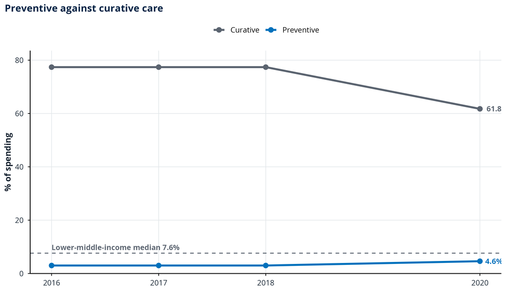

```r
if (PREV$ready) {
  # the two shares year by year, with the income-group median of the preventive share
  shares <- bind_rows(
    transmute(PREV$pts, year, v = prev, what = "Preventive"),
    transmute(PREV$pts, year, v = cur, what = "Curative")
  ) |>
    filter(is.finite(v))
  last_points <- shares |>
    group_by(what) |>
    slice_max(year, n = 1)
  p <- ggplot(shares, aes(year, v, colour = what)) +
    geom_line(linewidth = 1.2) +
    geom_point(size = 2.6) +
    geom_text(
      data = last_points,
      aes(label = num(v, 1, suffix = "%")),
      hjust = -0.3, fontface = "bold", size = 3.4, show.legend = FALSE
    ) +
    scale_colour_manual(values = c(Preventive = WB[["teal"]], Curative = WB[["muted"]])) +
    scale_y_continuous(limits = c(0, NA), expand = expansion(mult = c(0, 0.08))) +
    scale_x_continuous(breaks = unique(PREV$pts$year)) +
    labs(title = "Preventive against curative care", x = NULL, y = "% of spending") +
    theme_deck()
  if (isTRUE(is.finite(PREV$median$value))) {
    median_label <- paste(ADJ_CAP, "median", num(PREV$median$value, 1, suffix = "%"))
    p <- p +
      geom_hline(yintercept = PREV$median$value, linetype = "dashed", colour = WB[["muted"]]) +
      annotate(
        "text",
        x = min(PREV$pts$year), y = PREV$median$value, label = median_label,
        hjust = 0, vjust = -0.6, fontface = "bold", colour = WB[["muted"]], size = 3.3
      )
  }
  print(p)
} else if (nrow(NEED) > 0) {
  # without the split: need against the median, up to eight measures
  need_dots <- head(arrange(NEED, desc(ratio)), 8) |>
    mutate(row = factor(NEED_LABEL[id], levels = rev(NEED_LABEL[id])))
  p <- ggplot(need_dots, aes(ratio, row)) +
    geom_vline(xintercept = 1, linetype = "dashed", colour = WB[["muted"]]) +
    geom_point(size = 4, colour = WB[["teal"]]) +
    scale_x_log10() +
    labs(
      title = paste0("Need against the ", ADJ, " median"),
      x = paste0("Country / ", ADJ, " median, log scale (right of 1 = more need)"),
      y = NULL
    ) +
    theme_deck()
  print(p)
}
```

## 12. Do pooling and purchasing arrangements support effective care?

The composition of Egypt’s current health expenditure in 2023 is presented by financing arrangement: compulsory government and insurance schemes, voluntary schemes, and household out-of-pocket payments. Comparisons use the lower-middle-income group median and interquartile range. A higher compulsory financing share generally indicates greater prepayment and risk pooling. External resources are classified by the financing schemes through which they are spent rather than shown as a separate scheme. Provider payment information identifies the principal arrangements for primary, outpatient, and hospital services; associated behavioural incentives are theoretical expectations informed by WHO guidance, not directly observed provider responses.

```r
# The provider payment sentence: the main methods by level of care, as recorded
if (!PAY$present) {
  payment <- "How providers are paid is not documented in the sources reviewed."
} else if (PAY$cap_case) {
  payment <- paste(
    "Primary care is paid a fixed amount per person and hospitals per case, which can reward",
    "extra hospital cases unless volume or spending is capped."
  )
} else {
  # a method name that starts like a word ("Capitation") is lower-cased in the sentence
  main_methods <- PAY$groups |>
    filter(main, care %in% c("primary", "ambulatory", "hospital")) |>
    arrange(rank) |>
    mutate(
      starts_like_word = grepl("^[A-Z][a-z]", method),
      method = ifelse(
        starts_like_word,
        paste0(tolower(substr(method, 1, 1)), substring(method, 2)),
        method
      )
    ) |>
    distinct(title, method)
  if (nrow(main_methods) > 0) {
    # up to three levels of care, each with up to two methods: "primary care is mainly paid
    # by capitation and ..."
    levels_of_care <- head(unique(main_methods$title), 3)
    parts <- c()
    for (i in seq_along(levels_of_care)) {
      methods <- head(main_methods$method[main_methods$title == levels_of_care[i]], 2)
      methods <- methods[nzchar(methods)] # an empty method name is left out
      verb <- if (i == 1) " is mainly paid" else ""
      parts[i] <- paste0(
        tolower(levels_of_care[i]), verb, " by ",
        knitr::combine_words(methods, oxford_comma = FALSE)
      )
    }
    payment <- paste0("As recorded, ", knitr::combine_words(parts, oxford_comma = FALSE), ".")
  } else if (PAY$fragmentation) {
    payment <- "The payment record documents fragmented pooling or purchasing."
  } else {
    payment <- paste(
      "How providers are paid is documented in text only, so incentives cannot be read",
      "method by method."
    )
  }
}

POOL_LABEL <- c(
  cfa = "Compulsory schemes, total",
  gov = "of which government schemes",
  chi = "of which compulsory insurance",
  vol = "Voluntary schemes",
  oop = "Out-of-pocket payments",
  rest = "Rest of world or unclassified"
)
out <- c()
if (!POOL$ready) {
  out["Message"] <- paste(
    "WHO health accounts do not publish how current health spending divides between",
    "compulsory schemes, voluntary schemes and out-of-pocket payments for this country up to",
    "the selected year."
  )
  out["Provider payment"] <- payment
} else {
  schemes_shown <- POOL$rows
  schemes_shown$value_text <- num(schemes_shown$value, 0, suffix = "%")
  schemes_shown$median_text <- paste0(num(schemes_shown$median, 0), "%")
  cfa <- schemes_shown[schemes_shown$id == "cfa", ]
  oop <- schemes_shown[schemes_shown$id == "oop", ]
  vol <- schemes_shown[schemes_shown$id == "vol", ]
  oop_part <- "."
  if (is.finite(oop$value)) {
    oop_median <- if (is.finite(oop$median)) paste0(" (median ", oop$median_text, ")") else ""
    oop_part <- paste0("; households paid ", oop$value_text, " out of pocket", oop_median, ".")
  }
  # the deck words the lead differently when there is a group median to compare with
  if (is.finite(cfa$median)) {
    out["Lead"] <- paste0(
      "In ", POOL$year, ", compulsory schemes pooled ", cfa$value_text,
      " of current health spending, compared with ", AN_ADJ, " ", ADJ, " median of ",
      cfa$median_text, oop_part
    )
  } else {
    out["Lead"] <- paste0(
      "In ", POOL$year, ", ", cfa$value_text,
      " of current health spending was pooled through compulsory schemes (no publishable ", ADJ,
      " median)", oop_part
    )
  }
  for (i in seq_len(nrow(schemes_shown))) {
    label <- POOL_LABEL[[schemes_shown$id[i]]]
    out[paste("Row:", label)] <- schemes_shown$value_text[i]
    if (is.finite(schemes_shown$median[i])) {
      out[paste("Median:", label)] <- schemes_shown$median_text[i]
    }
  }
  out["Year of the comparison"] <- paste0("(25th to 75th percentile), ", POOL$year)
  out["Provider payment"] <- payment
  # a large voluntary share, else a large external share
  if (isTRUE(vol$value >= 25 & vol$value - vol$median >= 10)) {
    out["Voluntary schemes"] <- paste0(
      "Voluntary schemes carry ", vol$value_text, ", against a median of ", vol$median_text
    )
  } else if (isTRUE(POOL$ext$value >= 20)) {
    ext_median <- ""
    if (is.finite(POOL$ext$median)) {
      ext_median <- paste0(" (", ADJ, " median ", num(POOL$ext$median, 0, suffix = "%"), ")")
    }
    out["External sources"] <- paste0(
      "External sources fund ", num(POOL$ext$value, 0, suffix = "%"),
      " of current health spending", ext_median
    )
  }
  if (PAY$present && !is.null(PAY$supplement)) {
    n_public <- PAY$supplement$n_sources
    out["Payment source"] <- paste0(
      "from ", n_public, " public ", if (n_public == 1) "source" else "sources", "."
    )
  } else if (PAY$present) {
    out["Payment source"] <- paste0(
      "Health Payment Explorer country record (", PAY$n_sources, " cited sources)."
    )
  }
}
slide_values[[12]] <- out
knitr::kable(tibble::enframe(slide_values[[12]], name = "What the slide prints", value = "Value"))
```

| What the slide prints | Value |
| --- | --- |
| Lead | In 2023, compulsory schemes pooled 37% of current health spending, compared with a lower-middle-income median of 48%; households paid 57% out of pocket (median 38%). |
| Row: Compulsory schemes, total | 37% |
| Median: Compulsory schemes, total | 48% |
| Row: of which government schemes | 26% |
| Median: of which government schemes | 39% |
| Row: of which compulsory insurance | 11% |
| Median: of which compulsory insurance | 4% |
| Row: Voluntary schemes | 6% |
| Median: Voluntary schemes | 11% |
| Row: Out-of-pocket payments | 57% |
| Median: Out-of-pocket payments | 38% |
| Year of the comparison | (25th to 75th percentile), 2023 |
| Provider payment | As recorded, primary care is mainly paid by capitation and hospital inpatient care by case-based payment and fee for service. |
| Payment source | from 2 public sources. |

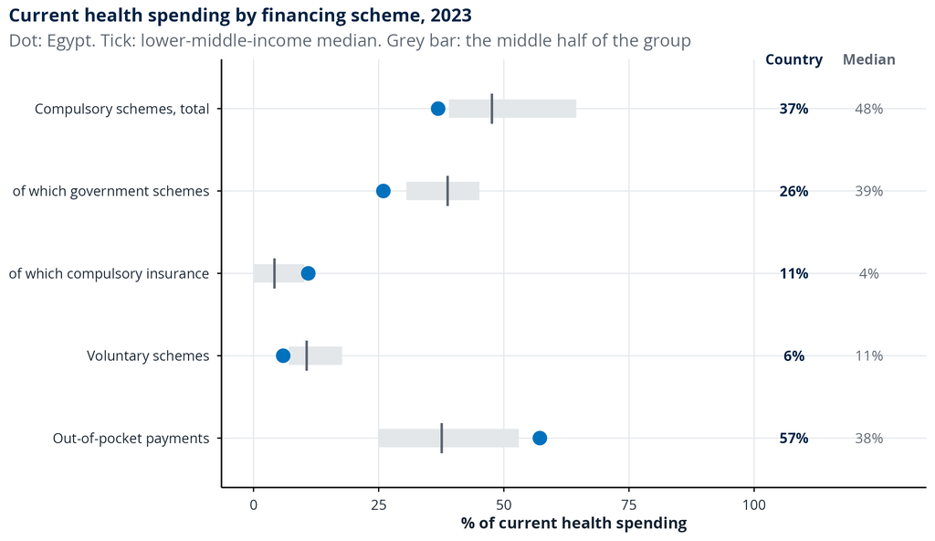

```r
if (POOL$ready) {
  # each scheme: the country (dot), the median (tick) and the middle half of the group (grey bar)
  schemes_shown$row <- factor(
    POOL_LABEL[schemes_shown$id],
    levels = rev(POOL_LABEL[schemes_shown$id])
  )
  schemes_shown$value_label <- num(schemes_shown$value, 0, suffix = "%")
  schemes_shown$value_label[!is.finite(schemes_shown$value)] <- ""
  schemes_shown$median_label <- num(schemes_shown$median, 0, suffix = "%")
  schemes_shown$median_label[!is.finite(schemes_shown$median)] <- ""
  ggplot(schemes_shown, aes(y = row)) +
    geom_linerange(
      aes(xmin = q1, xmax = q3),
      linewidth = 6, colour = WB[["light"]], na.rm = TRUE
    ) +
    geom_point(aes(x = median), shape = 124, size = 7, colour = WB[["muted"]], na.rm = TRUE) +
    geom_point(aes(x = value), size = 4, colour = WB[["teal"]], na.rm = TRUE) +
    geom_text(
      aes(x = 108, label = value_label),
      fontface = "bold", colour = WB[["dark"]], size = 3.5
    ) +
    geom_text(aes(x = 123, label = median_label), colour = WB[["muted"]], size = 3.5) +
    annotate(
      "text",
      x = c(108, 123), y = nrow(schemes_shown) + 0.6, label = c("Country", "Median"),
      family = "Open Sans", fontface = "bold", size = 3.5,
      colour = c(WB[["dark"]], WB[["muted"]])
    ) +
    scale_x_continuous(limits = c(0, 128), breaks = c(0, 25, 50, 75, 100)) +
    coord_cartesian(clip = "off") +
    labs(
      title = paste0("Current health spending by financing scheme, ", POOL$year),
      subtitle = paste0(
        "Dot: ", SHORT, ". Tick: ", ADJ, " median. Grey bar: the middle half of the group"
      ),
      x = "% of current health spending",
      y = NULL
    ) +
    theme_deck()
}
```

## 13. Understanding health budget space

Health budget space refers to additional government resources for health that may be accommodated within the expected macro-fiscal envelope and a feasible degree of health prioritisation over the next one or two budget cycles. It is a framework for assessing feasible expenditure rather than a spending target. The short-term horizon covers the first two years after the October 2026 IMF forecast vintage, while the medium-term analysis extends to the final projection year. The following scenarios distinguish the resources associated with the projected fiscal envelope from those associated with a stronger health budget share.

```r
# The horizons come from the projection, so that the definition and the projection cannot
# disagree: the first projection year after the IMF vintage and the year after it, and the
# last projection year
years_ahead <- if (PROJ$ready) PROJ$rows$year else integer()
near <- if (any(years_ahead > VINTAGE)) years_ahead[years_ahead > VINTAGE][1] else VINTAGE + 1
last_year <- if (length(years_ahead) > 0) max(years_ahead) else VINTAGE + 5
slide_values[[13]] <- c(
  "Near-term horizon" = paste0("(", near, " to ", near + 1, ")"),
  "Medium-term horizon" = paste0("through ", last_year)
)
knitr::kable(tibble::enframe(slide_values[[13]], name = "What the slide prints", value = "Value"))
```

| What the slide prints | Value |
| --- | --- |
| Near-term horizon | (2027 to 2028) |
| Medium-term horizon | through 2031 |

## 14. How much additional fiscal space could be mobilised?

Projected changes in government health expenditure per person from 2023 are expressed in Egyptian pounds at constant 2023 prices. Contributions are attributed to economic growth, the overall size of government expenditure, and changes in the health budget share. The passive scenario holds health prioritisation constant while incorporating projected macro-fiscal trends. The illustrative scenario increases the health budget share by one percentage point annually beginning in 2027, subject to the specified ceiling. This increment is a scenario assumption, not an assessment of political or fiscal feasibility. Peer benchmarks are fixed at the base year; actual peer spending may also grow over the projection period.

```r
# We build slide 14 in local currency at 2023 prices, and the same slide in US$ for annex A6
# (slide 22)
PART_NAME <- c(growth = "economic growth", budget = "government budget", prio = "reprioritisation")
SLIDE14 <- list()
versions <- if (LCU_MAIN) c("main", "annex") else "main"
for (version in versions) {
  lcu <- version == "main" && LCU_MAIN
  currency <- if (lcu) "local" else "US$"
  if (!PROJ$ready) {
    message_text <- paste(
      "Government health spending per person and its parts are not published for one common",
      "year, so the fiscal space cannot be estimated."
    )
    SLIDE14[[version]] <- list(values = c("Message" = message_text))
    next
  }
  base_year <- PROJ$base$year
  proj_rows <- PROJ$rows
  base <- PROJ$base$ghe_pc
  if (lcu) {
    # every amount in local currency at 2023 prices
    rate <- to_lcu$factor[match(base_year, to_lcu$year)]
    base <- base * rate
    for (k in c("trend", "priority", "growth", "budget", "prio")) {
      proj_rows[[k]] <- proj_rows[[k]] * rate
    }
  }
  last_row <- proj_rows[nrow(proj_rows), ] # the last horizon
  first_row <- proj_rows[proj_rows$h == 1, ] # one year after the start
  no_change <- all(abs(proj_rows$priority - base) < 1e-9)
  growth_source <- PROJ$growth$source

  # the chart's unit: US$, or local currency in trillions, billions or millions (thousands
  # for six-figure changes)
  biggest <- max(0, abs(c(proj_rows$growth, proj_rows$budget, proj_rows$prio)), na.rm = TRUE)
  divisor <- case_when(
    !lcu ~ 1,
    biggest >= 1e12 ~ 1e12,
    biggest >= 1e9 ~ 1e9,
    biggest >= 1e6 ~ 1e6,
    biggest >= 1e5 ~ 1e3,
    TRUE ~ 1
  )
  unit_word <- case_when(
    divisor == 1e12 ~ " trillion",
    divisor == 1e9 ~ " billion",
    divisor == 1e6 ~ " million",
    divisor == 1e3 ~ " thousand",
    TRUE ~ ""
  )
  axis_unit <- if (lcu) paste0(CODE, unit_word) else "US$"
  axis_title <- paste0(
    "Change from ", base_year, ", ", axis_unit, " per person at ", base_year, " prices"
  )
  # the level reached is printed after each bar; in local currency the deck widens the space
  # at the bar ends to fit the longest of these labels
  level_labels <- sapply(proj_rows$priority, fmt_money, currency = currency)
  end_width <- 128
  if (lcu) {
    end_width <- max(128, ceiling(max(nchar(level_labels)) * 22 * 0.62 + 12))
  }
  # each row: the year and how far it is from the start, or "estimate" for the start year
  is_estimate <- proj_rows$year == PROJ$start & PROJ$start != base_year &
    !(proj_rows$h %in% HORIZONS)
  years_after <- paste0("in ", proj_rows$h, " year", ifelse(proj_rows$h == 1, "", "s"))
  row_labels <- paste(proj_rows$year, ifelse(is_estimate, "estimate", years_after))

  out <- c()
  base_text <- fmt_money(base, currency)
  if (no_change) {
    out["Lead"] <- paste0(
      "Government health spending was ", base_text, " per person in ", base_year,
      "; with no growth series, no IMF projection and a health share already in the top",
      " quarter of all countries, no change is projected."
    )
  } else {
    amounts <- c(
      r_trend = fmt_money(last_row$trend, currency),
      n_trend = fmt_money(first_row$trend, currency),
      r_prio = fmt_money(last_row$priority, currency),
      n_prio = fmt_money(first_row$priority, currency)
    )
    # The candidate wordings of the lead, longest first: with and without the reason for past
    # growth in brackets, and in local currency with and without the currency code on the
    # projected amounts. We take the first that fits two lines.
    candidates <- c()
    for (with_reason in c(TRUE, FALSE)) {
      forms <- if (lcu) c("full", "bare") else "full"
      for (form in forms) {
        amount <- amounts
        if (form == "bare") {
          amount <- sub(paste0(CODE, NB), "", amounts, fixed = TRUE)
        }
        if (growth_source == "weo" && PROJ$budget == "weo") {
          opener <- "On the IMF outlook for growth and the budget,"
        } else if (growth_source == "weo") {
          opener <- "On the IMF growth outlook, with the budget held at its share of GDP,"
        } else if (growth_source == "past") {
          reason <- if (base_year < 2019) "early base year" else "no IMF projection"
          reason_text <- if (with_reason) paste0(" (", reason, ")") else ""
          opener <- paste0(
            "With past growth of ", num(PROJ$growth$rate, 1), "% a year assumed", reason_text, ","
          )
        } else {
          opener <- "With no growth series,"
        }
        moves <- paste0(
          opener, " government health spending moves from <b>", base_text, "</b> per person (",
          base_year, ") to <b>", amount[["r_trend"]], "</b> by ", last_row$year
        )
        two_horizons <- growth_source == "weo" && nrow(first_row) > 0 &&
          first_row$year != last_row$year
        if (PROJ$share$capped) {
          candidate <- paste0(
            moves, "; the health share, already in the top quarter of all countries, is held."
          )
        } else if (two_horizons) {
          candidate <- paste0(
            "Passive scenario (health's share unchanged): <b>", base_text, "</b> per person in ",
            base_year, ", <b>", amount[["n_trend"]], "</b> in ", first_row$year, " and <b>",
            amount[["r_trend"]], "</b> in ", last_row$year,
            ". An illustrative rise of one point a year from ", PROJ$start + 1,
            " takes it to <b>", amount[["n_prio"]], "</b> and <b>", amount[["r_prio"]], "</b>."
          )
        } else {
          candidate <- paste0(
            moves, "; a health share up one point a year from ", PROJ$start + 1,
            " takes it to <b>", amount[["r_prio"]], "</b>."
          )
        }
        candidates <- c(candidates, candidate)
      }
    }
    fits <- sapply(candidates, lead_width) <= LEAD_LIMIT
    chosen <- if (any(fits)) candidates[which(fits)[1]] else candidates[length(candidates)]
    out["Lead"] <- gsub("<[^>]+>", "", chosen) # the bold marks only served the width estimate
```

```r
    # The bar labels. The deck's chart is 1,000 px wide with 168 px of row labels; a part of a
    # bar is labelled only when it is wide enough to hold its label.
    parts <- as.matrix(proj_rows[c("growth", "budget", "prio")])
    max_pos <- max(0.0001, rowSums(pmax(parts, 0)))
    min_neg <- min(0, rowSums(pmin(parts, 0)))
    plot_width <- 1000 - 168 - 24
    span <- (max_pos - min_neg) / max(0.3, (plot_width - end_width) / plot_width)
    for (i in seq_len(nrow(proj_rows))) {
      for (k in c("growth", "budget", "prio")) {
        change <- proj_rows[[k]][i]
        if (!is.finite(change) || abs(change) < 1e-9) next
        size <- abs(change)
        if (divisor > 1) {
          in_unit <- size / divisor
          amount_text <- num(in_unit, case_when(in_unit >= 10 ~ 0, in_unit >= 1 ~ 1, TRUE ~ 2))
        } else if (lcu) {
          amount_text <- sub(paste0(CODE, NB), "", fmt_money(size), fixed = TRUE)
        } else {
          amount_text <- num(size, if (size < 10) 1 else 0)
        }
        label <- paste0(if (change < 0) "-" else "+", amount_text)
        bar_px <- size / span * plot_width
        if (bar_px >= nchar(label) * 22 * 0.6 + 14) {
          out[paste0("Bar label, ", proj_rows$year[i], ", ", PART_NAME[[k]])] <- label
        }
      }
      out[paste0("Level reached, ", proj_rows$year[i])] <- level_labels[i]
      out[paste0("Row label, ", proj_rows$year[i])] <- row_labels[i]
    }
    out["Axis"] <- axis_title
  }

  # the notes under the chart
  if (lcu) {
    imf_applied <- if (growth_source == "weo") {
      paste0(": the IMF's real growth applied to ", base_year, " values.")
    } else {
      "."
    }
    out["Note: prices"] <- paste0(
      "Constant ", BASE, " ", CUR_NAME, " (", RATE_TEXT, " in ", BASE, ", WHO GHED)", imf_applied
    )
  } else {
    out["Note: prices"] <- paste0("US$ at ", base_year, " prices and exchange rates.")
  }
  if (growth_source == "weo" || PROJ$budget == "weo") {
    series <- c(
      if (growth_source == "weo") "real GDP per person",
      if (PROJ$budget == "weo") "general government spending, % of GDP"
    )
    actual_to <- ""
    if (is.finite(PROJ$imf_actual)) {
      actual_to <- paste0(", actual to ", PROJ$imf_actual, ", projected after")
    }
    out["Note: IMF"] <- paste0(
      "IMF World Economic Outlook, October 2026: ", paste(series, collapse = " and "),
      actual_to, "."
    )
  }
  if (growth_source == "past") {
    out["Note: past growth"] <- paste0(
      ": past growth of ", num(PROJ$growth$rate, 1), "% a year (", PROJ$growth$y0, " to ",
      PROJ$growth$y1, ") assumed."
    )
  }
  if (PROJ$budget == "held") {
    out["Note: budget held"] <- paste0("spending held at its ", base_year, " share of GDP.")
  }
  if (PROJ$start > base_year) {
    then_rising <- ""
    if (!PROJ$share$capped) {
      at_most <- ""
      if (is.finite(PROJ$share$ceiling)) {
        at_most <- paste0(
          " to at most ", num(PROJ$share$ceiling, 1, suffix = "%"),
          ", the share a quarter of countries exceed"
        )
      }
      then_rising <- paste0(
        ", then up 1 point a year", at_most,
        ": illustrative, not yet empirically validated, not a forecast"
      )
    }
    out["Note: health share"] <- paste0(
      "Health share held at its ", base_year, " value to ", PROJ$start, then_rising, "."
    )
  }
  if (!no_change && nrow(first_row) > 0) {
    reprioritised <- if (PROJ$share$capped) {
      "the health share is already high."
    } else {
      first_prio <- fmt_money(first_row$priority, currency)
      paste0("with the illustrative reprioritisation, ", first_prio, ".")
    }
    out["Near term"] <- paste0(
      "(next one to two budget cycles, ", first_row$year, "): Passive scenario ",
      fmt_money(first_row$trend, currency), " per person; ", reprioritised
    )
  }
  adds_budget <- if (last_row$budget >= 0) "adds" else "takes away"
  if (no_change) {
    budget_text <- "the government budget is held at its share of GDP"
    if (PROJ$budget == "weo") {
      budget_text <- paste0(
        "the IMF's budget outlook ", adds_budget, " ", fmt_money(abs(last_row$budget), currency)
      )
    }
    out["Medium term"] <- paste0(
      "By ", last_row$year, ", with no growth series, ", budget_text, "."
    )
  } else {
    if (growth_source == "none") {
      growth_part <- "with no growth series, the economy is held"
    } else {
      adds_growth <- if (last_row$growth >= 0) "adds" else "takes away"
      growth_part <- paste0(
        "economic growth ", adds_growth, " ", fmt_money(abs(last_row$growth), currency)
      )
    }
    # when growth and the budget both add, the deck does not repeat "adds"
    same_way <- growth_source != "none" && last_row$growth >= 0 && last_row$budget >= 0
    if (PROJ$budget == "weo") {
      verb <- if (same_way) "" else paste0(adds_budget, " ")
      budget_part <- paste0(
        "the IMF's budget outlook ", verb, fmt_money(abs(last_row$budget), currency), " per person"
      )
    } else {
      budget_part <- "the government budget is held at its share of GDP"
    }
    compare <- ""
    if (is.finite(PROJ$comp$share_median)) {
      top_quarter <- ""
      if (is.finite(PROJ$comp$share_q3)) {
        top_quarter <- paste0(", top quarter ", num(PROJ$comp$share_q3, 1, suffix = "%"))
      }
      compare <- paste0(
        " (", ADJ, " median ", num(PROJ$comp$share_median, 1, suffix = "%"), top_quarter, ")"
      )
    }
    if (PROJ$share$capped) {
      share_part <- paste0(
        "health already takes ", num(PROJ$share$base, 1, suffix = "%"),
        " of government spending, above the ", num(PROJ$share$ceiling, 1, suffix = "%"),
        " that a quarter of countries exceed, so the share is held."
      )
    } else {
      at_ceiling <- is.finite(PROJ$share$ceiling) && last_row$share >= PROJ$share$ceiling - 1e-9
      share_part <- paste0(
        "the increase attributable to reprioritisation toward health, a share rising to ",
        num(last_row$share, 1, suffix = "%"), if (at_ceiling) ", its ceiling," else "",
        compare, ", adds ", fmt_money(last_row$prio, currency), " more."
      )
    }
    out["Medium term"] <- paste0(
      "(to ", last_row$year, "): in the Passive scenario, ", growth_part, " and ", budget_part,
      "; ", share_part
    )
  }
```

```r
  # The figure: the change from the base year in each projection year, split into its three
  # parts, with the level reached after each bar
  p <- NULL
  if (!no_change) {
    bars <- proj_rows |>
      mutate(row = factor(row_labels, levels = rev(row_labels))) |>
      select(row, growth, budget, prio) |>
      pivot_longer(-row, names_to = "part", values_to = "v") |>
      mutate(
        v = v / divisor,
        part = factor(part, levels = c("prio", "budget", "growth"))
      )
    bar_ends <- data.frame(
      row = factor(row_labels, levels = rev(row_labels)),
      x = pmax(0, rowSums(pmax(parts, 0))) / divisor,
      label = level_labels
    )
    left_room <- if (min(bars$v) < 0) 0.05 else 0
    p <- ggplot(bars, aes(v, row, fill = part)) +
      geom_col(width = 0.6) +
      geom_vline(xintercept = 0, colour = "black") +
      geom_text(
        data = bar_ends,
        aes(x, row, label = label),
        inherit.aes = FALSE, hjust = -0.1, fontface = "bold", colour = WB[["dark"]], size = 3.6
      ) +
      scale_fill_manual(
        values = c(growth = WB[["pale"]], budget = WB[["mid"]], prio = WB[["teal"]]),
        breaks = c("growth", "budget", "prio"),
        labels = c(
          growth = "Economic growth",
          budget = "Government budget",
          prio = "Reprioritisation (+1 point a year, illustrative)"
        )
      ) +
      scale_x_continuous(
        labels = scales::label_comma(accuracy = 1),
        expand = expansion(mult = c(left_room, 0.25))
      ) +
      labs(
        title = paste0("Change in government health spending per person from ", base_year),
        x = axis_title,
        y = NULL
      ) +
      theme_deck()
  }
  SLIDE14[[version]] <- list(values = out, plot = p)
}

values <- SLIDE14$main$values
if (PROJ$ready && !is.null(FALLBACK_NOTE)) {
  values["Currency note"] <- FALLBACK_NOTE
}
slide_values[[14]] <- values
knitr::kable(tibble::enframe(slide_values[[14]], name = "What the slide prints", value = "Value"))
```

[output not shown]

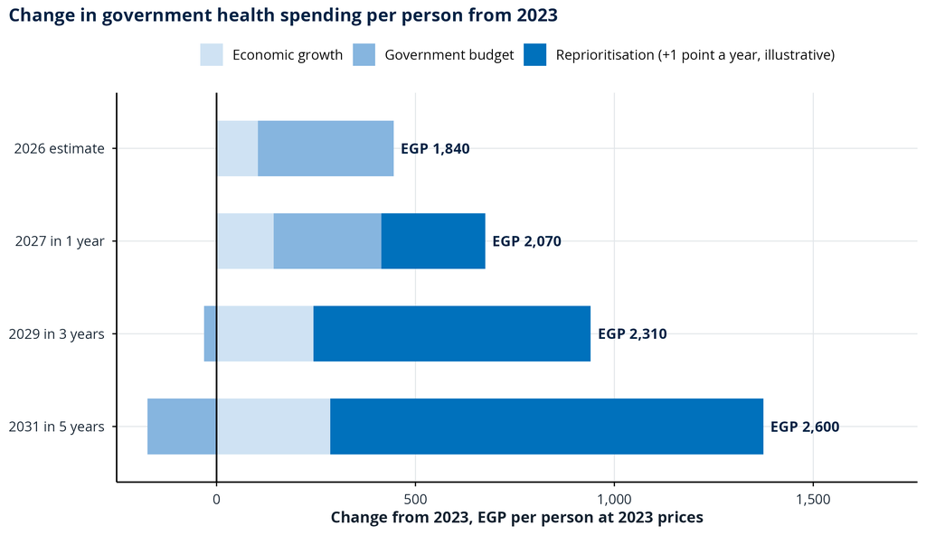

```r
if (!is.null(SLIDE14$main$plot)) print(SLIDE14$main$plot)
```

## 15. What could additional health expenditure achieve?

The two fiscal scenarios are evaluated at the final projection horizon. Additional annual government health expenditure is measured relative to a baseline in which 2023 per capita spending remains unchanged. Potentially averted deaths are illustrated using an expenditure-mortality elasticity of -0.13, and the associated economic value is estimated through a full-income framework. Applying this cross-country association to projected deaths in Egypt’s assumes an immediate, proportionate mortality reduction across age groups, without allowing for implementation delays or differences in intervention effectiveness. These values are illustrative rather than forecasts; programme-specific costing and impact modelling would be needed to estimate the returns to a concrete national investment package.

```r
# neither scenario changes spending (within half a percent of the base level)
FLAT <- FUND$ready && all(abs(FUND$last$dg) <= 0.005 * FUND$base$ghe)

# We build slide 15 in local currency at 2023 prices, and the same slide in US$ for annex A7
# (slide 23)
SLIDE15 <- list()
versions <- if (LCU_MAIN) c("main", "annex") else "main"
for (version in versions) {
  lcu <- version == "main" && LCU_MAIN
  currency <- if (lcu) "local" else "US$"
  if (!FUND$ready) {
    message_text <- paste0(
      "Not available: the fiscal space projection for ", SHORT, " is not available, so the",
      " extra funding and what it would buy cannot be shown."
    )
    SLIDE15[[version]] <- list(values = c("Message" = message_text))
    next
  }
  base_year <- FUND$base$year
  base <- FUND$base$ghe
  last_horizon <- FUND$last # the last horizon: one row per scenario
  if (lcu) {
    rate <- to_lcu$factor[match(base_year, to_lcu$year)]
    base <- base * rate
    for (k in c("ghe", "dg", "extra", "full")) {
      last_horizon[[k]] <- last_horizon[[k]] * rate
    }
  }
  passive <- last_horizon[last_horizon$scenario == "trend", ] # scenario 1, health's share held
  reprio <- last_horizon[last_horizon$scenario == "priority", ] # scenario 2, health's share rising
  horizon_year <- last_horizon$year[1]

  # money: the change per person (and the base level), and the total a year
  per_person <- c(
    passive = fmt_money(abs(passive$dg), currency),
    reprio = fmt_money(abs(reprio$dg), currency),
    base = fmt_money(abs(base), currency)
  )
  # Totals in US$ round to two significant figures, in billions from US$1 billion and in
  # millions from US$100,000
  total <- c()
  for (k in c("passive", "reprio")) {
    amount <- if (k == "passive") abs(passive$extra) else abs(reprio$extra)
    rounded <- signif(amount, 2)
    if (!is.finite(amount)) {
      total[k] <- NA_TXT
    } else if (lcu) {
      total[k] <- fmt_money(amount)
    } else if (amount >= 1e9) {
      total[k] <- paste0("US$", num(rounded / 1e9, if (amount >= 1e10) 0 else 1), " billion")
    } else if (amount >= 1e5) {
      total[k] <- paste0("US$", num(rounded / 1e6, if (amount >= 1e6) 0 else 1), " million")
    } else {
      total[k] <- paste0("US$", num(rounded, 0))
    }
  }
  # deaths averted as printed: "under 1", the unit below 10, two significant figures above
  deaths <- abs(last_horizon$averted)
  deaths_rounded <- ifelse(deaths >= 10, signif(deaths, 2), deaths)
  deaths_text <- ifelse(deaths < 1, "under 1", num(deaths_rounded, 0))
  deaths_text[!is.finite(last_horizon$averted)] <- NA_TXT
  more_or_fewer <- ifelse(last_horizon$averted > 0, "fewer", "more")
  deaths_part <- ifelse(
    is.finite(last_horizon$averted) & deaths >= 1,
    paste0("; illustratively, about <b>", deaths_text, "</b> ", more_or_fewer, " deaths a year"),
    ""
  )
  names(deaths_part) <- c("passive", "reprio")
  flat <- all(abs(last_horizon$dg) <= 0.005 * base)
  out <- c()

  # The lead: the longest wording estimated to fit two lines, else the first within the
  # deck's limit of 192 characters
  if (abs(reprio$dg - passive$dg) <= 0.005 * base) {
    # the two scenarios end in the same place
    total_text <- if (is.finite(passive$extra)) paste0(" (<b>", total[["passive"]], "</b>)") else ""
    if (passive$dg >= 0) {
      change <- paste0("add <b>", per_person[["passive"]], "</b> a person a year over ", base_year)
    } else {
      change <- paste0(
        "leave spending <b>", per_person[["passive"]], "</b> a person a year below ", base_year
      )
    }
    both_end <- paste0("By <b>", horizon_year, "</b>, both scenarios would ", change, total_text)
    options <- c(
      paste0(both_end, ": health's budget share is already high", deaths_part[["passive"]], "."),
      paste0(both_end, deaths_part[["passive"]], "."),
      paste0(both_end, ".")
    )
    if (flat) {
      lead <- paste0(
        "By <b>", horizon_year, "</b>, neither scenario changes government health spending",
        " per person from its ", base_year, " level (<b>", per_person[["base"]],
        "</b>), so there is no extra funding to value."
      )
    } else {
      short_enough <- which(nchar(gsub("<[^>]+>", "", options)) <= 192)
      lead <- options[c(short_enough, length(options))[1]]
    }
  } else {
    total_text <- if (is.finite(reprio$extra)) paste0(" (<b>", total[["reprio"]], "</b>)") else ""
    against <- paste0(
      ", against ", if (passive$dg < 0) "a fall of " else "", "<b>", per_person[["passive"]],
      "</b> in the Passive scenario"
    )
    rise <- reprio$dg >= 0
    if (rise) {
      adds <- paste0("adds <b>", per_person[["reprio"]], "</b> a person a year over ", base_year)
    } else {
      adds <- paste0(
        "leaves spending <b>", per_person[["reprio"]], "</b> a person a year below ", base_year
      )
    }
    reprioritisation <- paste0("illustrative reprioritisation ", adds, total_text, against)
    options <- c(
      paste0(
        "By <b>", horizon_year, "</b> (medium-term outlook), ", reprioritisation,
        deaths_part[["reprio"]], "."
      ),
      paste0("By <b>", horizon_year, "</b>, ", reprioritisation, deaths_part[["reprio"]], "."),
      paste0("By <b>", horizon_year, "</b>, ", reprioritisation, ".")
    )
    # two lines at 27 px: in US$ bold figures count wider too, and the margin is 8% (6% in
    # local currency)
    widths <- sapply(options, lead_width, bold_figures_wider = !lcu)
    fitting <- options[widths <= 2 * 1380 * (if (lcu) 0.94 else 0.92)]
    add <- paste0(
      if (rise) "add " else "leave spending ", "<b>", per_person[["reprio"]], "</b> a person a year"
    )
    over_or_below <- paste0(if (rise) " over " else " below ", base_year)
    prioritising <- paste0("By <b>", horizon_year, "</b>, prioritising health would ", add)
    fallback <- c(
      paste0(prioritising, over_or_below, total_text, against, deaths_part[["reprio"]], "."),
      paste0(prioritising, total_text, against, deaths_part[["reprio"]], "."),
      paste0(prioritising, over_or_below, total_text, against, ".")
    )
    if (length(fitting) > 0) {
      lead <- fitting[1]
    } else {
      short_enough <- which(nchar(gsub("<[^>]+>", "", fallback)) <= 192)
      lead <- fallback[c(short_enough, length(fallback))[1]]
    }
  }
  out["Lead"] <- gsub("<[^>]+>", "", lead) # the bold marks only served the width estimate
```

```r
  # the two scenario cards
  base_share <- FUND$share0
  out["Card 1"] <- paste0("health's budget share stays at ", num(base_share, 1, suffix = "%"))
  growth_source <- PROJ$growth$source
  out["Card 1 assumption"] <- case_when(
    growth_source == "weo" & PROJ$budget == "weo" ~
      "the economy and the budget follow IMF projections",
    growth_source == "weo" ~
      paste0("IMF growth; the budget stays at its ", base_year, " share of GDP"),
    growth_source == "past" & PROJ$budget == "weo" ~
      "past growth continues; the budget follows the IMF",
    growth_source == "past" ~
      "past growth continues; the budget keeps its share of GDP",
    TRUE ~ "no growth series: the economy is held at its base level"
  )
  if (FUND$capped) {
    out["Card 2"] <- paste0(
      "health's budget share, ", num(base_share, 1, suffix = "%"),
      ", is above the world top quarter (",
      num(FUND$ceiling, 1, suffix = "%"), ")"
    )
  } else {
    out["Card 2"] <- paste0(
      "health's budget share, ", num(base_share, 1, suffix = "%"), " in ", base_year, " to ",
      num(reprio$share, 1, suffix = "%"), " in ", horizon_year
    )
    step <- if (is.finite(FUND$step) && FUND$step > 0) FUND$step else NA_real_
    at_ceiling <- is.finite(FUND$ceiling) && is.finite(reprio$share) &&
      reprio$share >= FUND$ceiling - 1e-6
    if (at_ceiling) {
      out["Card 2 assumption"] <- paste0(
        "capped at ", num(FUND$ceiling, 1, suffix = "%"), ", the world top quarter"
      )
    } else if (is.finite(step)) {
      step_digits <- if (abs(step - round(step)) < 0.05) 0 else 1
      points_word <- if (abs(step - 1) < 0.05) " point" else " points"
      from_year <- if (PROJ$start > base_year) paste0(" from ", PROJ$start + 1) else ""
      out["Card 2 assumption"] <- paste0(
        "+", num(step, step_digits), points_word, " a year", from_year
      )
    }
  }

  # The three panels: extra spending, deaths averted and the value of those lives, in a unit
  # that suits their size
  biggest <- max(0, abs(c(last_horizon$extra, last_horizon$full)), na.rm = TRUE)
  if (lcu) {
    divisor <- case_when(
      biggest >= 1e12 ~ 1e12,
      biggest >= 1e9 ~ 1e9,
      biggest >= 1e6 ~ 1e6,
      TRUE ~ 1
    )
    unit_word <- case_when(
      divisor == 1e12 ~ " trillion",
      divisor == 1e9 ~ " billion",
      divisor == 1e6 ~ " million",
      TRUE ~ ""
    )
    unit <- paste0(CODE, unit_word)
  } else {
    divisor <- if (biggest >= 1e11) 1e9 else 1e6
    unit <- paste("US$", if (divisor == 1e9) "billion" else "million")
  }
  # The panel amounts as printed (extra spending, then the value of lives, each for scenarios
  # 1 and 2): the chart's rounding in local currency; in US$ millions or billions, two
  # significant figures (one below 0.1)
  amounts <- c(last_horizon$extra, last_horizon$full) / divisor
  if (lcu) {
    amount_text <- case_when(
      abs(amounts) >= 10 ~ num(amounts, 0),
      abs(amounts) >= 1 ~ num(amounts, 1),
      TRUE ~ num(amounts, 2)
    )
  } else {
    amount_text <- case_when(
      abs(amounts) >= 10 ~ num(signif(amounts, 2), 0),
      abs(amounts) >= 1 ~ num(signif(amounts, 2), 1),
      abs(amounts) >= 0.095 ~ num(signif(amounts, 1), 1),
      abs(amounts) >= 0.01 ~ num(signif(amounts, 1), 2),
      TRUE ~ "0"
    )
  }
  amount_text[!is.finite(amounts)] <- NA_TXT
  if (flat) {
    no_growth <- if (PROJ$growth$source == "none") ": no growth projection is available" else ""
    already_high <- ""
    if (FUND$capped) {
      already_high <- paste0(
        ", and health already takes ", num(base_share, 1, suffix = "%"),
        " of government spending, above the world top quarter"
      )
    }
    out["No change"] <- paste0(
      "Neither path raises government health spending per person by ", horizon_year, no_growth,
      already_high, "."
    )
  } else {
    for (i in 1:2) {
      name <- paste("Scenario", i)
      out[paste("Extra spending,", name)] <- amount_text[i]
      if (FUND$health_ready) {
        minus <- if (isTRUE(last_horizon$averted[i] <= -1)) "-" else ""
        out[paste("Deaths averted,", name)] <- paste0(minus, deaths_text[i])
      }
      if (FUND$value_ready) {
        out[paste("Value of lives,", name)] <- amount_text[i + 2]
      }
    }
    out["Panel unit"] <- paste0(
      "Extra government health spending in ", horizon_year, ", ", unit, " a year"
    )
    out["Deaths panel"] <- paste0("Deaths averted in ", horizon_year, ", illustrative")
    prices_note <- if (lcu) {
      paste0("; ", CUR_NAME, " at ", BASE, " prices (", RATE_TEXT, ")")
    } else {
      paste0(", US$ of ", base_year)
    }
    out["Figure note"] <- paste0(
      "Against ", base_year, " government health spending per person held constant", prices_note
    )
  }

  # The figure: the three panels, scenario 1 in grey and scenario 2 in blue
  p <- NULL
  if (!FLAT) {
    panel_titles <- c(
      extra = paste0("Extra government health spending, ", unit, " a year"),
      averted = "Deaths averted, illustrative",
      full = paste0("Value of those lives, ", unit, " a year")
    )
    panel_bars <- data.frame(
      panel = factor(rep(panel_titles, each = 2), levels = panel_titles),
      scen = rep(c("Scenario 1", "Scenario 2"), 3),
      v = c(last_horizon$extra / divisor, last_horizon$averted, last_horizon$full / divisor),
      lab = c(amount_text[1:2], deaths_text, amount_text[3:4])
    )
    panel_bars <- panel_bars[is.finite(panel_bars$v), ]
    bottom_room <- if (any(panel_bars$v < 0, na.rm = TRUE)) 0.12 else 0
    p <- ggplot(panel_bars, aes(scen, v, fill = scen)) +
      geom_col(width = 0.55) +
      geom_hline(yintercept = 0, colour = "black") +
      geom_text(
        aes(label = lab, vjust = ifelse(v >= 0, -0.4, 1.4)),
        fontface = "bold", size = 3.6
      ) +
      facet_wrap(~panel, scales = "free_y", ncol = 3, labeller = label_wrap_gen(28)) +
      scale_fill_manual(
        values = c("Scenario 1" = WB[["grey"]], "Scenario 2" = WB[["teal"]]),
        guide = "none"
      ) +
      scale_y_continuous(
        labels = scales::label_comma(accuracy = 1),
        expand = expansion(mult = c(bottom_room, 0.15))
      ) +
      labs(
        title = paste0(
          "In ", horizon_year, ", against ", base_year, " spending per person held constant"
        ),
        x = NULL,
        y = NULL
      ) +
      theme_deck(11)
  }
  SLIDE15[[version]] <- list(values = out, plot = p)
}
```

```r
values <- SLIDE15$main$values
if (FUND$ready && !FLAT && !is.null(FALLBACK_NOTE)) {
  values["Currency note"] <- FALLBACK_NOTE
}
slide_values[[15]] <- values
knitr::kable(tibble::enframe(slide_values[[15]], name = "What the slide prints", value = "Value"))
```

| What the slide prints | Value |
| --- | --- |
| Lead | By 2031, illustrative reprioritisation adds EGP 1,200 a person a year over 2023 (EGP 155 billion), against EGP 112 in the Passive scenario; illustratively, about 24,000 fewer deaths a year. |
| Card 1 | health’s budget share stays at 6.9% |
| Card 1 assumption | the economy and the budget follow IMF projections |
| Card 2 | health’s budget share, 6.9% in 2023 to 11.9% in 2031 |
| Card 2 assumption | +1 point a year from 2027 |
| Extra spending, Scenario 1 | 14 |
| Deaths averted, Scenario 1 | 2,500 |
| Value of lives, Scenario 1 | 26 |
| Extra spending, Scenario 2 | 155 |
| Deaths averted, Scenario 2 | 24,000 |
| Value of lives, Scenario 2 | 244 |
| Panel unit | Extra government health spending in 2031, EGP billion a year |
| Deaths panel | Deaths averted in 2031, illustrative |
| Figure note | Against 2023 government health spending per person held constant; Egyptian pounds at 2023 prices (EGP 30.63 per US$) |

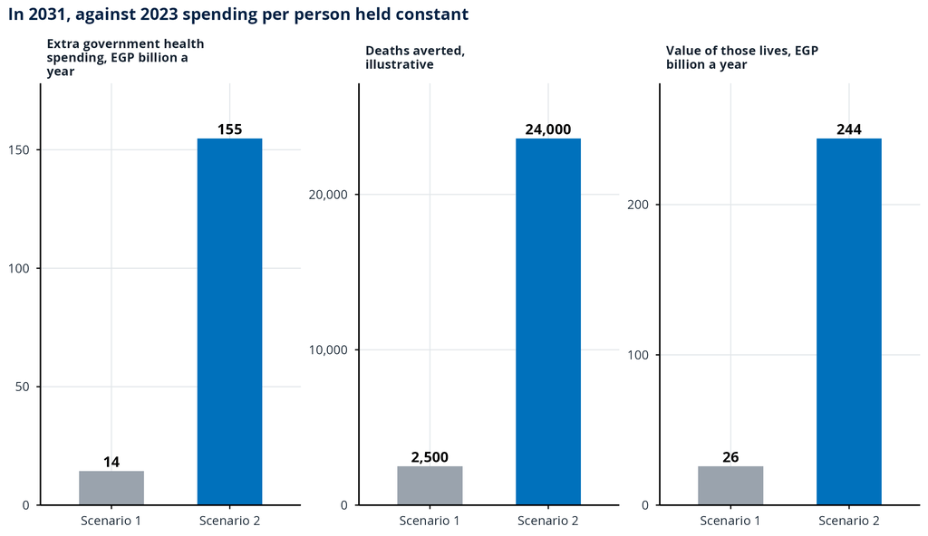

```r
if (!is.null(SLIDE15$main$plot)) print(SLIDE15$main$plot)
```

## Annex. Introduction

The slide introduces the annex and lists each annex slide with its number.

```r
# The divider repeats the contents slide's labels: annex A1, then the six US$ copies when the
# country has local-currency data
annex_labels <- TITLES[["a1"]]
if (LCU_MAIN) {
  annex_labels <- c(
    annex_labels,
    "Annex A2: Decomposition, US$",
    "Annex A3: Health for spending, US$",
    "Annex A4: Financial protection, US$",
    "Annex A5: Budgets and services, US$",
    "Annex A6: Fiscal space, US$",
    "Annex A7: Funding needed, US$"
  )
}
annex_numbers <- POS[["a1"]] + seq_along(annex_labels) - 1
slide_values[[16]] <- c(SHORT, paste(annex_numbers, annex_labels))
knitr::kable(tibble::enframe(slide_values[[16]], name = "What the slide prints", value = "Value"))
```

| What the slide prints | Value |
| --- | --- |
| 1 | Egypt |
| 2 | 17 Annex A1: What is the main performance gap: health, financial protection, or both? |
| 3 | 18 Annex A2: Decomposition, US$ |
| 4 | 19 Annex A3: Health for spending, US$ |
| 5 | 20 Annex A4: Financial protection, US$ |
| 6 | 21 Annex A5: Budgets and services, US$ |
| 7 | 22 Annex A6: Fiscal space, US$ |
| 8 | 23 Annex A7: Funding needed, US$ |

## Annex A1. Relative gaps in health outcomes and financial protection

Health outcome performance and financial protection are jointly assessed using standardised deviations from cross-country expenditure benchmarks (Sections 5 and 6). Higher values indicate more favourable performance on both axes. A score of -0.5 or lower identifies a deficit in the relevant dimension, separating countries into four groups: no deficit, health outcomes deficit only, financial protection deficit only, and deficits in both. Scores are based on PPP expenditure comparisons, but the underlying models and reference years may differ; consequently, the figure indicates the presence of relative deficits rather than providing a directly comparable measure of their magnitude.

```r
# The main slide uses the PPP scores, unless the country has a protection score only at
# market exchange rates
usd_protection_only <- is.finite(GAP_USD$protection$z) && !is.finite(GAP_PPP$protection$z)
A1_PPP <- LCU_MAIN && isTRUE(HEALTH_PPP$ready) && !usd_protection_only
gap_fit <- if (A1_PPP) GAP_PPP else GAP_USD
health_fit <- if (A1_PPP) HEALTH_PPP else HEALTH_USD
protection_fit <- if (A1_PPP) PROT_PPP else PROT_USD
health_z <- gap_fit$health$z
protection_z <- gap_fit$protection$z

# scores print to two decimals with a sign; one that rounds to zero prints as 0.00
health_text <- NULL
if (is.finite(health_z)) {
  health_text <- paste0("health ", num(health_z, 2, plus = TRUE), " (", gap_fit$health$year, ")")
}
protection_text <- NULL
if (is.finite(protection_z)) {
  protection_text <- paste0(
    "protection ", num(protection_z, 2, plus = TRUE), " (survey ", gap_fit$protection$year, ")"
  )
}

# why a score is missing
if (is.na(protection_fit$country$measure)) {
  no_protection <- "no household survey of health costs is published"
} else if (!is.finite(protection_fit$country$spending)) {
  no_protection <- paste0(
    "the ", protection_fit$country$year,
    " survey has no government health spending figure for its year"
  )
} else {
  no_protection <- "too few countries have a survey to compare with"
}
if (!isTRUE(health_fit$ready)) {
  no_health <- "too few countries publish spending and outcomes for the same year"
} else {
  no_health <- "fewer than two of premature NCD, under-five and maternal mortality are published"
}

out <- c()
if (gap_fit$gap == "both") {
  out["Lead"] <- paste0(
    "A gap in both: ", health_text, " and ", protection_text, " are at least 0.5 standard",
    " deviations below the level typical at the country's spending."
  )
} else if (gap_fit$gap == "health" && !is.null(protection_text)) {
  out["Lead"] <- paste0(
    "Health has the gap: ", health_text, " is below -0.5, while ", protection_text,
    " is not."
  )
} else if (gap_fit$gap == "health") {
  out["Lead"] <- paste0(
    "The gap is in health (", health_text, "); financial protection has no score."
  )
} else if (gap_fit$gap == "protection" && !is.null(health_text)) {
  out["Lead"] <- paste0(
    "Financial protection has the gap: ", protection_text, " is below -0.5, while ",
    health_text, " is not."
  )
} else if (gap_fit$gap == "protection") {
  out["Lead"] <- paste0(
    "The gap is in financial protection (", protection_text, "); health has no score."
  )
} else if (gap_fit$gap == "neither") {
  out["Lead"] <- paste0(
    "No gap: neither ", health_text, " nor ", protection_text, " is 0.5 standard deviations",
    " or more below the level typical at the country's spending."
  )
} else if (!is.null(health_text)) {
  # one score only, or none
  health_words <- case_when(
    health_z >= 0.5 ~ "better than typical",
    health_z <= -0.5 ~ "worse than typical",
    TRUE ~ "close to typical"
  )
  out["Lead"] <- paste0(
    "Health is ", health_words, " (", health_text, "), but financial protection has no",
    " score: ", no_protection, "."
  )
} else if (!is.null(protection_text)) {
  protection_words <- case_when(
    protection_z >= 0.5 ~ "stronger than typical",
    protection_z <= -0.5 ~ "weaker than typical",
    TRUE ~ "close to typical"
  )
  out["Lead"] <- paste0(
    "Financial protection is ", protection_words, " (", protection_text,
    "), but health has no score: ", no_health, "."
  )
} else {
  out["Lead"] <- paste0(
    "Neither score can be computed: for health, ", no_health, "; for protection, ",
    no_protection, "."
  )
}
counts <- gap_fit$counts
if (counts[["n"]] > 0) {
  out["Count: health gap only"] <- paste("Health gap only:", counts[["health"]])
  out["Count: gap in both"] <- paste("Gap in both:", counts[["both"]])
  out["Count: protection gap only"] <- paste("Protection gap only:", counts[["protection"]])
  out["Count: no gap"] <- paste("No gap:", counts[["neither"]])
}
out["Countries with both scores"] <- paste0(
  "Each dot is a country with both scores (", counts[["n"]], ")"
)
if (A1_PPP) {
  out["Slides of the two fits"] <- paste0("(slides ", POS[["q01"]], " and ", POS[["q02"]], ")")
}
group_counts <- gap_fit$group_counts
if (group_counts[["n"]] > 0) {
  out["Income group"] <- paste0(
    "Of ", group_counts[["n"]], " ", ADJ, " countries with both scores, ",
    group_counts[["neither"]], " have no gap, ", group_counts[["health"]], " a health gap, ",
    group_counts[["protection"]], " a protection gap and ", group_counts[["both"]], " both."
  )
}
slide_values[[17]] <- out
knitr::kable(tibble::enframe(slide_values[[17]], name = "What the slide prints", value = "Value"))
```

| What the slide prints | Value |
| --- | --- |
| Lead | Financial protection has the gap: protection -1.62 (survey 2019) is below -0.5, while health -0.42 (2021) is not. |
| Count: health gap only | Health gap only: 22 |
| Count: gap in both | Gap in both: 16 |
| Count: protection gap only | Protection gap only: 30 |
| Count: no gap | No gap: 97 |
| Countries with both scores | Each dot is a country with both scores (165) |
| Slides of the two fits | (slides 5 and 6) |
| Income group | Of 50 lower-middle-income countries with both scores, 29 have no gap, 5 a health gap, 11 a protection gap and 5 both. |

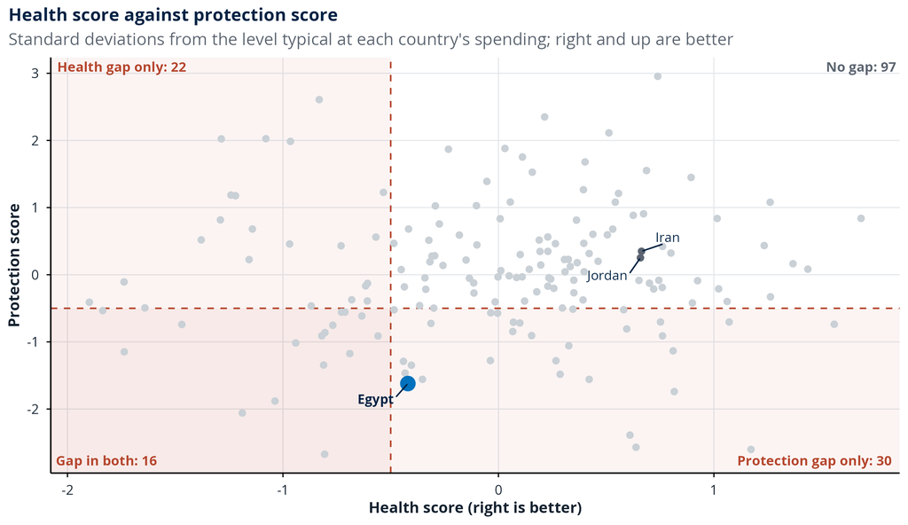

```r
# The figure: every country's health score against its protection score, with the -0.5 lines
if (nrow(gap_fit$points) > 0) {
  scatter_points <- mutate(gap_fit$points, peer = iso %in% gap_fit$peers$iso)
  labels <- scatter_points |>
    filter(peer) |>
    transmute(h, p, label = countries$label[match(iso, ISOS)], face = "plain")
  corner_labels <- c(
    paste("Health gap only:", counts[["health"]]),
    paste("No gap:", counts[["neither"]]),
    paste("Gap in both:", counts[["both"]]),
    paste("Protection gap only:", counts[["protection"]])
  )
  p <- ggplot(scatter_points, aes(h, p)) +
    annotate(
      "rect",
      xmin = -Inf, xmax = -0.5, ymin = -Inf, ymax = Inf,
      fill = WB[["rust"]], alpha = 0.06
    ) +
    annotate(
      "rect",
      xmin = -Inf, xmax = Inf, ymin = -Inf, ymax = -0.5,
      fill = WB[["rust"]], alpha = 0.06
    ) +
    geom_vline(xintercept = -0.5, linetype = "dashed", colour = WB[["rust"]]) +
    geom_hline(yintercept = -0.5, linetype = "dashed", colour = WB[["rust"]]) +
    geom_point(aes(colour = peer), size = 1.8) +
    scale_colour_manual(
      values = c(`FALSE` = WB[["faint"]], `TRUE` = WB[["muted"]]),
      guide = "none"
    ) +
    annotate(
      "text",
      x = c(-Inf, Inf, -Inf, Inf), y = c(Inf, Inf, -Inf, -Inf),
      hjust = c(-0.05, 1.05, -0.05, 1.05), vjust = c(1.5, 1.5, -0.8, -0.8),
      label = corner_labels,
      colour = c(WB[["rust"]], WB[["muted"]], WB[["rust"]], WB[["rust"]]),
      family = "Open Sans", fontface = "bold", size = 3.4
    ) +
    labs(
      title = "Health score against protection score",
      subtitle = paste(
        "Standard deviations from the level typical at each country's spending;",
        "right and up are better"
      ),
      x = "Health score (right is better)",
      y = "Protection score"
    ) +
    theme_deck()
  if (is.finite(health_z) && is.finite(protection_z)) {
    p <- p + annotate("point", x = health_z, y = protection_z, colour = WB[["teal"]], size = 4.5)
    own_label <- data.frame(h = health_z, p = protection_z, label = SHORT, face = "bold")
    labels <- bind_rows(labels, own_label)
  }
  p + geom_text_repel(
    data = labels,
    aes(h, p, label = label, fontface = face),
    family = "Open Sans", size = 3.3, colour = WB[["dark"]],
    box.padding = 0.6, min.segment.length = 0, max.overlaps = Inf, seed = 1
  )
}
```

## Annex A2. Decomposition of government health expenditure in US dollars

The accounting decomposition in Section 3 is expressed here in current US dollars at market exchange rates. GDP per person and government health expenditure are compared with corresponding US-dollar income-group medians; these monetary comparisons may differ from results presented in PPP terms. Fiscal ratios and the procedure for identifying the principal constraint remain unchanged. Countries without national-currency conversion data already use US dollars in the main assessment and therefore do not require this supplementary presentation.

```r
# We built this copy with slide 3, in US$; a country without local currency has no annex
# copy, because its main slides are already in US$
if (!LCU_MAIN) {
  cat("No annex copy: the main slides of", SHORT, "are already in US$.\n")
}
if (LCU_MAIN) {
  slide_values[[18]] <- SLIDE3$annex$values
  knitr::kable(tibble::enframe(slide_values[[18]], name = "What the slide prints", value = "Value"))
}
```

[output not shown]

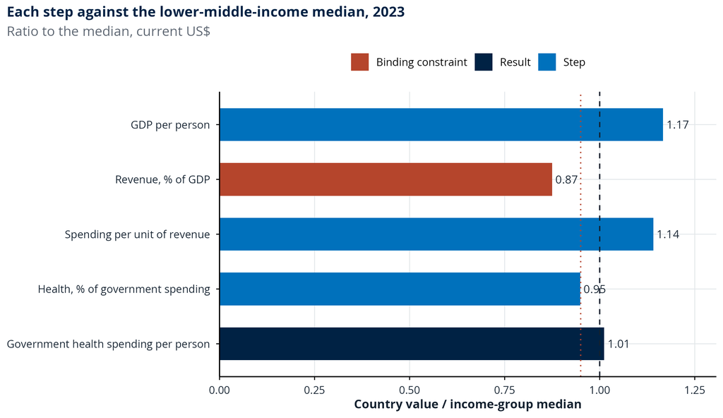

```r
if (LCU_MAIN && !is.null(SLIDE3$annex$plot)) print(SLIDE3$annex$plot)
```

## Annex A3. Health outcomes relative to spending in US dollars

The health outcomes benchmark from Section 5 is re-estimated using expenditure in current US dollars at market exchange rates. The reference period and statistical specification remain unchanged. Differences in international price levels and exchange rates may alter country positions, the fitted relationship, the relative performance gap, and the set of closest comparators.

```r
# We built this copy with slide 5, in US$; a country without local currency has no annex
# copy, because its main slides are already in US$
if (!LCU_MAIN) {
  cat("No annex copy: the main slides of", SHORT, "are already in US$.\n")
}
if (LCU_MAIN) {
  slide_values[[19]] <- SLIDE5$annex$values
  knitr::kable(tibble::enframe(slide_values[[19]], name = "What the slide prints", value = "Value"))
}
```

| What the slide prints | Value |
| --- | --- |
| Lead | In 2021, the risk of premature deaths from noncommunicable diseases (ages 30 to 70) was 26.0%, 6.0 percentage points higher than the 20.0% typical of countries spending US$177 per person on health. |
| Gap label on the chart | 6.0 points above typical |
| Axis year | (log scale), 2021 |
| Countries in the fit | least-squares fit across 182 countries |
| Figure year | Each dot is a country, 2021 |
| Comparators | Dark dots: the 4 countries |
| Coverage | the UHC index is 71, against 61 typical at this spending (2021) |

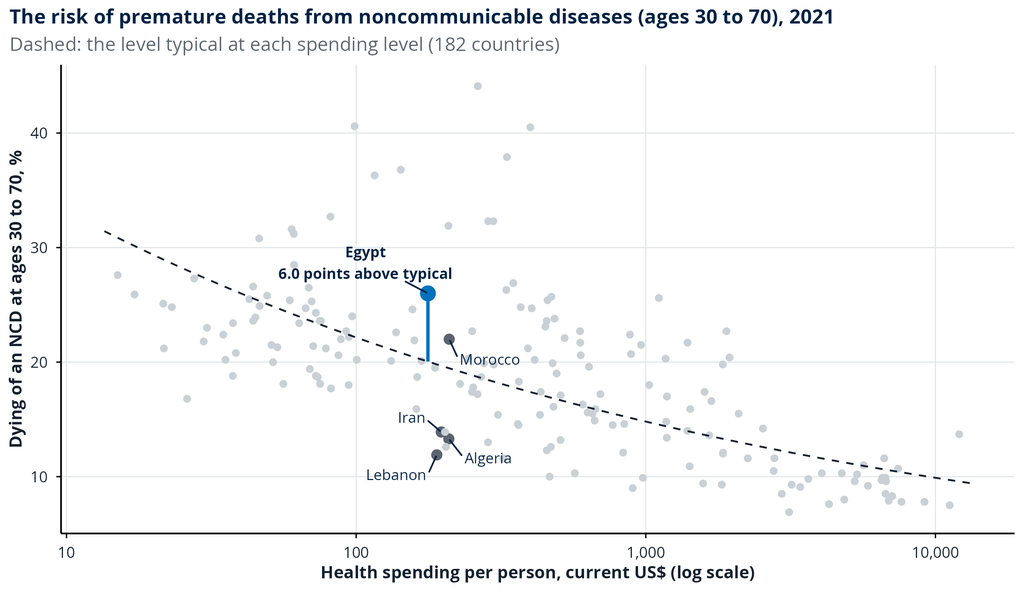

```r
if (LCU_MAIN && !is.null(SLIDE5$annex$plot)) print(SLIDE5$annex$plot)
```

## Annex A4. Financial protection relative to spending in US dollars

Financial hardship is compared with government health expenditure in constant 2023 US dollars, using the same surveys and outcome definitions as Section 6. Expected hardship levels and the relevant comparison countries are determined from the US-dollar expenditure benchmark.

```r
# We built this copy with slide 6, in US$; a country without local currency has no annex
# copy, because its main slides are already in US$
if (!LCU_MAIN) {
  cat("No annex copy: the main slides of", SHORT, "are already in US$.\n")
}
if (LCU_MAIN) {
  slide_values[[20]] <- SLIDE6$annex$values
  knitr::kable(tibble::enframe(slide_values[[20]], name = "What the slide prints", value = "Value"))
}
```

| What the slide prints | Value |
| --- | --- |
| Lead | 36.9% of people faced financial hardship from health costs in 2019, against 26.4% typical at the same government health spending (US$34 per person). |
| Country label | , 2019 |
| Gap label | 10.5 points above typical |
| Survey years | latest survey (2003 to 2023) |
| Group median | median is 25.2% (latest surveys from 48 of 51 countries, surveys 2003 to 2023) |
| Out of pocket | Out-of-pocket payments are 57% of health spending (2023); the lower-middle-income median is 38% |

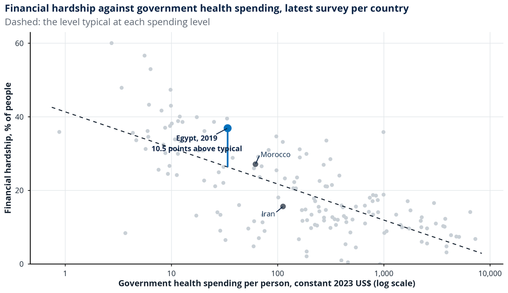

```r
if (LCU_MAIN && !is.null(SLIDE6$annex$plot)) print(SLIDE6$annex$plot)
```

## Annex A5. Public financing and service coverage in US dollars

Government health expenditure per person is expressed in current US dollars and compared with the corresponding income-group median. Service coverage indicators and their underlying reference periods are unchanged from Section 8.

```r
# We built this copy with slide 8, in US$; a country without local currency has no annex
# copy, because its main slides are already in US$
if (!LCU_MAIN) {
  cat("No annex copy: the main slides of", SHORT, "are already in US$.\n")
}
if (LCU_MAIN) {
  slide_values[[21]] <- SLIDE8$annex$values
  knitr::kable(tibble::enframe(slide_values[[21]], name = "What the slide prints", value = "Value"))
}
```

| What the slide prints | Value |
| --- | --- |
| Government health spending per person | US$46 |
| Government health spending per person, median | US$45 |
| UHC service coverage index | 71 |
| UHC service coverage index, median | 59 |
| Children vaccinated against measles | 96% |
| Children vaccinated against measles, median | 84% |
| Births attended by skilled staff | 97% (2021) |
| Births attended by skilled staff, median | 86% |
| Tuberculosis treatment success | 88% |
| Tuberculosis treatment success, median | 89% |
| People with HIV on treatment | 38% |
| People with HIV on treatment, median | 71% |
| Government health spending per person, % of the median | 101% |
| UHC service coverage index, % of the median | 120% |
| Lead | In 2023, government health spending per person was 101% of the lower-middle-income median, while the UHC service coverage index was 120% of it (71 against 59). |
| Figure note | median of 51 lower-middle-income countries |
| Years | Spending: 2023; services: latest value 2014 to 2023 |
| Furthest below the median | furthest below the median: 38% against 71% |

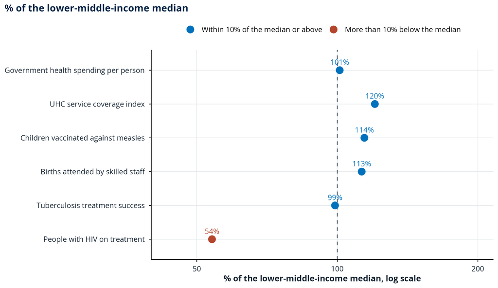

```r
if (LCU_MAIN && !is.null(SLIDE8$annex$plot)) print(SLIDE8$annex$plot)
```

## Annex A6. Fiscal space projections in US dollars

Projected health expenditure paths are expressed in constant 2023 US dollars. Economic assumptions, expenditure shares, and the decomposition of changes are identical to those in Section 14; national-currency amounts are converted using GHED’s 2023 exchange rate.

```r
# We built this copy with slide 14, in US$; a country without local currency has no annex
# copy, because its main slides are already in US$
if (!LCU_MAIN) {
  cat("No annex copy: the main slides of", SHORT, "are already in US$.\n")
}
if (LCU_MAIN) {
  slide_values[[22]] <- SLIDE14$annex$values
  knitr::kable(tibble::enframe(slide_values[[22]], name = "What the slide prints", value = "Value"))
}
```

[output not shown]

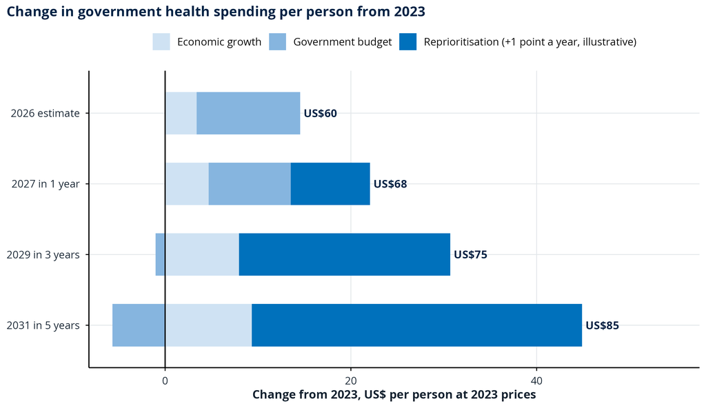

```r
if (LCU_MAIN && !is.null(SLIDE14$annex$plot)) print(SLIDE14$annex$plot)
```

## Annex A7. Potential benefits of additional health expenditure in US dollars

The final-horizon analysis from Section 15 is expressed in constant 2023 US dollars. Currency conversion affects estimates of additional expenditure and the economic value of benefits but does not change the modelled number of deaths averted.

```r
# We built this copy with slide 15, in US$; a country without local currency has no annex
# copy, because its main slides are already in US$
if (!LCU_MAIN) {
  cat("No annex copy: the main slides of", SHORT, "are already in US$.\n")
}
if (LCU_MAIN) {
  slide_values[[23]] <- SLIDE15$annex$values
  knitr::kable(tibble::enframe(slide_values[[23]], name = "What the slide prints", value = "Value"))
}
```

[output not shown]

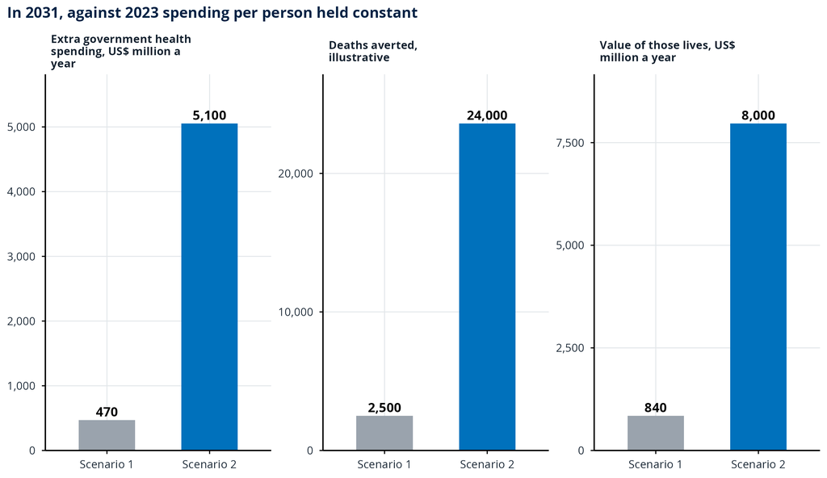

```r
if (LCU_MAIN && !is.null(SLIDE15$annex$plot)) print(SLIDE15$annex$plot)
```

# Validation and consistency checks

For fifteen reference countries, calculated values are compared with the text contained in `data/reference_slides.rds`, derived from the corresponding published HTML presentations. Validation checks both whether each calculated value appears as a complete numerical token and whether unexplained numerical values remain after the calculated outputs are accounted for. Fixed source annotations, definitions, and methodological thresholds are excluded from the latter check, as are graphical axis ticks. Any discrepancy is flagged as an error to maintain numerical consistency between the analytical outputs and reference material.

```r
REF <- readRDS(file.path("data", "reference_slides.rds"))

# Text as we compare it: one space for any run of spaces, and no space before punctuation
# (bold text leaves one in the deck's export)
norm_space <- function(x) {
  x <- trimws(gsub("[[:space:]\u00a0\u2009\u202f]+", " ", x))
  x <- gsub(" ([.,;:)])", "\\1", x)
  gsub("\\( ", "(", x)
}
# The deck's fixed wording that carries digits: we mask it in the slide text and in the values
# alike
TEMPLATE <- c(
  "\\(2025 update\\)", "\\(2025\\)", "2025 definition", "UHC global monitoring report 2025",
  "World Bank \\(2025\\)", "ages 30 to 70", "SDG 3\\.8\\.2", "SDG indicator 3\\.b\\.3",
  "SH\\.DYN\\.NCOM\\.ZS", "HC\\.5\\.1", "SHA 2011", "per 1,000 births", "(?i)per 1,000 people",
  "per 1,000 adults", "per 100,000 births", "per 100,000", "per 1,000 at risk", "per 1,000\\b",
  "\\(0 to 100\\)", "constant 2023", "2023 prices", "2023 PPP", "October 2026", "August 2026",
  "Workforce 2030 \\(2016\\)", "SDG health targets \\(2016\\)",
  "World Population Prospects 2024", "Medicine 2017", "Global health 2050 \\(2024\\)",
  "Heller \\(2006\\)", "Tandon and Cashin \\(2010\\)", "Barroy and Gupta \\(2020\\)",
  "\\(draft, 2026\\)", "more than 5%", "more than 10%", "\\+1 point", "up 1 point",
  "dashed line = 100%", "25th to 75th percentile", "CC[ A-Z-]* [0-9.]+", "160 times",
  "\\(-0\\.13\\)", "age 75", "(?i)scenario [12]", "WHO threshold of 4\\.45", "-0\\.5",
  "0\\.5 standard deviations", "1\u00d7", "\\b[0-9]+/[0-9]+\\b", "next one to two",
  "\\bA[1-7]\\b", "2020 to 2022 include COVID-19", "more than 10 points",
  paste0(
    "(?<![0-9.])[1-4]\\. (Fiscal size and trend|Health spending efficiency|",
    "Health budget execution|Fiscal space projection)"
  ),
  "5 points or more", "25% or more and 10 points", "gaps under 5 points count as 5", "DTP3",
  "more than 10% of their budget", "over 10% of the household budget",
  "The 2025 hardship measure", "the older 10% measure", "over 10% of budget"
)
mask <- function(x) {
  for (pattern in TEMPLATE) {
    x <- gsub(pattern, "\u00a7", x, perl = TRUE)
  }
  x
}
# A value counts as found only as a whole number: "23" is not found inside "2023" or "23.5"
value_pattern <- function(value) {
  before <- if (grepl("^[-+]?[0-9]", value)) "(?<![0-9.,])" else ""
  after <- if (grepl("[0-9]$", value)) "(?![0-9]|[.,][0-9])" else ""
  paste0(before, "\\Q", value, "\\E", after)
}

CHECK <- NULL
if (!ISO %in% REF$iso3) {
  cat(
    "No reference text is stored for ", NAME, ": the check runs only for the fifteen ",
    "reference countries (", paste(unique(REF$iso3), collapse = ", "), ").\n",
    sep = ""
  )
} else {
  ref_country <- filter(REF, iso3 == ISO)
  check_rows <- list()
  for (n in seq_len(N_SLIDES)) {
    slide_text <- norm_space(ref_country$text[ref_country$slide == n])
    values <- norm_space(slide_values[[n]])
    # First, every value must appear in the text of its slide
    found <- logical(length(values))
    for (i in seq_along(values)) {
      found[i] <- grepl(value_pattern(values[i]), slide_text, perl = TRUE)
    }
    # Second, once the values and the fixed wording are taken out, no number may be left
    # (we drop the page number in the footer first)
    rest <- sub("\u00b7 [0-9]+ / [0-9]+$", "", slide_text)
    rest <- mask(rest)
    for (value in values[order(-nchar(values))]) {
      rest <- gsub(value_pattern(mask(value)), " ", rest, perl = TRUE)
    }
    number_matches <- gregexpr("[-+]?[0-9][0-9,]*(\\.[0-9]+)?", rest)
    left <- unlist(regmatches(rest, number_matches))
    check_rows[[n]] <- data.frame(
      Slide = n,
      `Values checked` = length(values),
      `Not found in the deck` = sum(!found),
      `Deck numbers not reproduced` = length(left),
      Result = if (all(found) && length(left) == 0) "pass" else "FAIL",
      Detail = paste(c(values[!found], left), collapse = " | "),
      check.names = FALSE
    )
  }
  CHECK <- bind_rows(check_rows)
}
if (!is.null(CHECK)) knitr::kable(CHECK, align = "rrrrll")
```

| Slide | Values checked | Not found in the deck | Deck numbers not reproduced | Result | Detail |
| --- | --- | --- | --- | --- | --- |
| 1 | 5 | 0 | 0 | pass |  |
| 2 | 15 | 0 | 0 | pass |  |
| 3 | 15 | 0 | 0 | pass |  |
| 4 | 21 | 0 | 0 | pass |  |
| 5 | 7 | 0 | 0 | pass |  |
| 6 | 6 | 0 | 0 | pass |  |
| 7 | 14 | 0 | 0 | pass |  |
| 8 | 18 | 0 | 0 | pass |  |
| 9 | 6 | 0 | 0 | pass |  |
| 10 | 6 | 0 | 0 | pass |  |
| 11 | 7 | 0 | 0 | pass |  |
| 12 | 14 | 0 | 0 | pass |  |
| 13 | 2 | 0 | 0 | pass |  |
| 14 | 23 | 0 | 0 | pass |  |
| 15 | 14 | 0 | 0 | pass |  |
| 16 | 8 | 0 | 0 | pass |  |
| 17 | 8 | 0 | 0 | pass |  |
| 18 | 15 | 0 | 0 | pass |  |
| 19 | 7 | 0 | 0 | pass |  |
| 20 | 6 | 0 | 0 | pass |  |
| 21 | 18 | 0 | 0 | pass |  |
| 22 | 23 | 0 | 0 | pass |  |
| 23 | 14 | 0 | 0 | pass |  |

```r
if (!is.null(CHECK)) {
  cat(
    sum(CHECK$`Values checked`), "values on", nrow(CHECK), "slides;",
    sum(CHECK$Result == "pass"), "slides pass.\n"
  )
  if (any(CHECK$Result != "pass")) {
    stop(
      "The numbers of ", sum(CHECK$Result != "pass"),
      " slide(s) do not match the deck's text for ", ISO, "."
    )
  }
}
```

```
## 272 values on 23 slides; 23 slides pass.
```